This project deals with the data analysis that I have done as part of my final master’s thesis at Zhejiang University in Summer 2020. It includes data cleaning, restructuring, and Natural Language Processing (NLP) by building text corpora and performing sentiment analyses. All this work was aimed to tackle my thesis’ research question of ‘How customer emotions are influenced by global e-Commerce events’, such as the Amazon Prime Day, which is the subject of this study.

*Loading libraries and dependencies*

```r
library(Hmisc)
library(gridExtra)
library(gofastr)
library(ggplot2)
library(plotly)
library(data.table)
library(tidyverse)
library(scales)
library(corrplot)
library(rgdal)
library(caret)
#library(psych)
library(nortest)
library(reshape2)
library(lubridate)
library(ggmap)
library(ggpubr)
library(stringi)
library(SentimentAnalysis)
library(tm)
library(car)
library(wordcloud)
library(RColorBrewer)
```

*4.2 Data understanding*

Loading data set

```r
rm(list=ls())
dataset <-read.csv("C:/Users/HP/Documents/Uni/Zhejiang Uni/Master Thesis/JanRoller_Master_thesis_15.06.2020_Data Set.csv", stringsAsFactors = FALSE)
```

Initial data cleaning for first exploration

Receiving number of rows (observations) and columns (variables) and general statistics

```r
dim(dataset)
```

```
## [1] 34660    21
```

```r
summary(dataset)
```

```
##       X                 name              asins              brand
##  Length:34660       Length:34660       Length:34660       Length:34660
##  Class :character   Class :character   Class :character   Class :character
##  Mode  :character   Mode  :character   Mode  :character   Mode  :character
##
##
##
##
##   categories            keys           manufacturer       reviews.date
##  Length:34660       Length:34660       Length:34660       Length:34660
##  Class :character   Class :character   Class :character   Class :character
##  Mode  :character   Mode  :character   Mode  :character   Mode  :character
##
##
##
##
##  reviews.dateAdded  reviews.dateSeen   reviews.didPurchase reviews.doRecommend
##  Length:34660       Length:34660       Mode:logical        Mode :logical
##  Class :character   Class :character   TRUE:1              FALSE:1384
##  Mode  :character   Mode  :character   NA's:34659          TRUE :32682
##                                                            NA's :594
##
##
##
##    reviews.id        reviews.numHelpful reviews.rating  reviews.sourceURLs
##  Min.   :111372787   Min.   :  0.0000   Min.   :1.000   Length:34660
##  1st Qu.:111372787   1st Qu.:  0.0000   1st Qu.:4.000   Class :character
##  Median :111372787   Median :  0.0000   Median :5.000   Mode  :character
##  Mean   :111372787   Mean   :  0.6302   Mean   :4.585
##  3rd Qu.:111372787   3rd Qu.:  0.0000   3rd Qu.:5.000
##  Max.   :111372787   Max.   :814.0000   Max.   :5.000
##  NA's   :34659       NA's   :529        NA's   :33
##  reviews.text       reviews.title      reviews.userCity reviews.userProvince
##  Length:34660       Length:34660       Mode:logical     Mode:logical
##  Class :character   Class :character   NA's:34660       NA's:34660
##  Mode  :character   Mode  :character
##
##
##
##
##  reviews.username
##  Length:34660
##  Class :character
##  Mode  :character
##
##
##
##
```

```r
data1 <-  dataset %>% select(asins, reviews.date, reviews.rating, reviews.text)
newvector <- (1:42)
data1 %>% glimpse()
```

```
## Rows: 34,660
## Columns: 4
## $ asins          <chr> "B01AHB9CN2", "B01AHB9CN2", "B01AHB9CN2", "B01AHB9CN...
## $ reviews.date   <chr> "2017-01-13T00:00:00.000Z", "2017-01-13T00:00:00.000...
## $ reviews.rating <int> 5, 5, 5, 4, 5, 5, 4, 5, 5, 5, 4, 5, 4, 5, 5, 5, 4, 4...
## $ reviews.text   <chr> "This product so far has not disappointed. My childr...
```

*Exploration of variable ‘asins’ / ‘Products’*

Explore Data by frequency of each product ID’s (asins) occurence

```r
sort(table(data1$asins))
```

```
##
##            B00BFJAHF8            B018Y23P7K
##                     1                     1                     2
##            B00LO29KXQ            B0083Q04TA            B005PB2T0S
##                     3                     4                     5
##            B005PB2T2Q            B00DU15MU4            B00REQKWGA
##                     6                     6                     6
##            B018Y22C2Y            B00X4WHP5E            B018T075DC
##                     6                     7                     7
##            B006GWO5NE            B00UH4D8G2            B002Y27P6Y
##                     8                     8                    10
##            B018Y22BI4            B006GWO5WK            B00LW9XOJM
##                    10                    13                    13
##            B01AHB9C1E            B00QL1ZN3G            B01J4ORNHU
##                    14                    15                    16
##            B002Y27P3M            B00QJDU3KY            B01BFIBRIE
##                    19                    19                    30
##            B00IOYAM4I            B00VINDBJK            B00QFQRELG
##                    51                    67                    73
##            B01AHB9CYG            B00ZV9PXP2            B0189XYY0Q
##                   158                   212                   256
##            B018SZT3BK            B00TSUGXKE            B01J2G4VBG
##                   270                   372                   402
##            B00IOY8XWQ            B01BH83OOM            B018Y225IA
##                   580                   636                  1038
##            B018Y23MNM            B01AHB9CN2            B00OQVZDJM
##                  1685                  2814                  3176
##            B00U3FPN4U B00L9EPT8O,B01E6AO69U            B018Y229OU
##                  5056                  6619                 10966
```

For better handling, the variable Product will be created in which product names will be assigned to the respective asins (Product ID’s)

```r
data1$Product[data1$asins == 'B018Y229OU' | data1$asins == 'B002Y27P3M' | data1$asins =='B00TSUGXKE' | data1$asins == 'B0083Q04TA' | data1$asins == 'B018Y23P7K'] <- 'Fire 7 8GB'
data1$Product[data1$asins == 'B018Y225IA' | data1$asins == 'B018Y22BI4'] <- 'Fire 7 16GB'
data1$Product[data1$asins == 'B01AHB9CN2' | data1$asins == 'B018SZT3BK' | data1$asins == 'B018T075DC'] <- 'Fire HD 8 16GB'
data1$Product[data1$asins == 'B01AHB9CYG'] <- 'Fire HD 8 32GB'
data1$Product[data1$asins == 'B0189XYY0Q'] <- 'Fire HD 10'
data1$Product[data1$asins == 'B018Y23MNM'| data1$asins == 'B018Y22C2Y'] <- 'Fire Kids Edition'
data1$Product[data1$asins == 'B01E6AO69U, B00L9EPT8O' | data1$asins == 'B00L9EPT8O,B01E6AO69U'| data1$asins == 'B00X4WHP5E'] <- 'Echo'
data1$Product[data1$asins == 'B00U3FPN4U'] <- 'Fire TV'
data1$Product[data1$asins == 'B00OQVZDJM' | data1$asins == 'B00QJDU3KY' | data1$asins == 'B01BFIBRIE'|data1$asins == 'B00ZV9PXP2'] <- 'Kindle Paperwhite'
data1$Product[data1$asins == 'B00IOY8XWQ'| data1$asins == 'B00IOYAM4I'] <- 'Kindle Voyage'
data1$Product[data1$asins == 'B00REQKWGA' | data1$asins == 'B00VINDBJK'] <- 'Kindle Oasis'
data1$Product[data1$asins == 'B01BH83OOM'] <- 'Tap'
```

Remove variable asins (1st column of data frame), which was replaced by Products

```r
data2 <- data1[-1]
```

Check for NA’s

```r
sum(is.na(data2$Product))
```

```
## [1] 595
```

Checking for missing values among four relevant variables

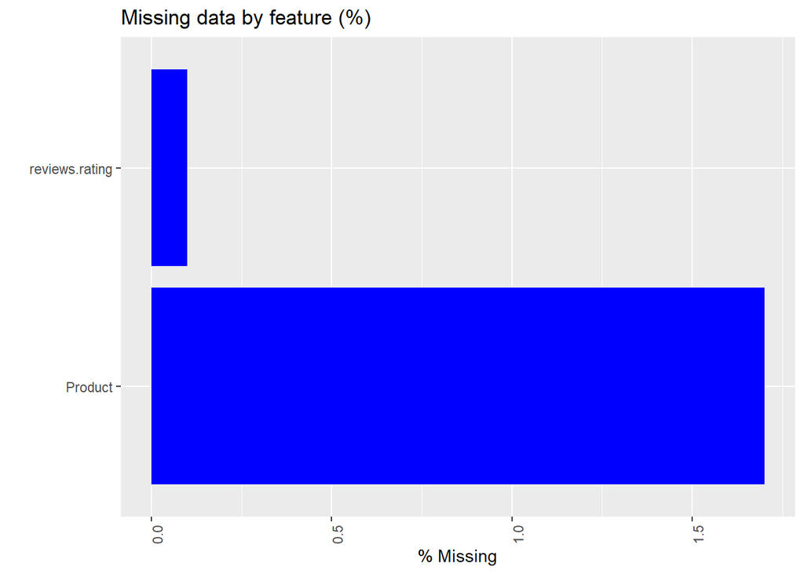

```r
miss_pct1 <- map_dbl(data2, function(x) { round((sum(is.na(x)) / length(x)) * 100, 1) })

miss_pct1 <- miss_pct1[miss_pct1 > 0]
data.frame(miss=miss_pct1, var=names(miss_pct1), row.names=NULL) %>% ggplot(aes(x=reorder(var, -miss), y=miss)) + geom_bar(stat="identity", fill="blue") +   labs(x='', y="% Missing", title="Missing data by feature (%)") +
theme(axis.text.x=element_text(angle=90, hjust=1))+
  coord_flip()
```

Create new data frame for relevant products only and confirm that there is not a single missing value

```r
data3 = data2[complete.cases(data2$Product),]
sum(is.na(data3$Product))
```

```
## [1] 0
```

Histogram representing count of each product in the new data frame

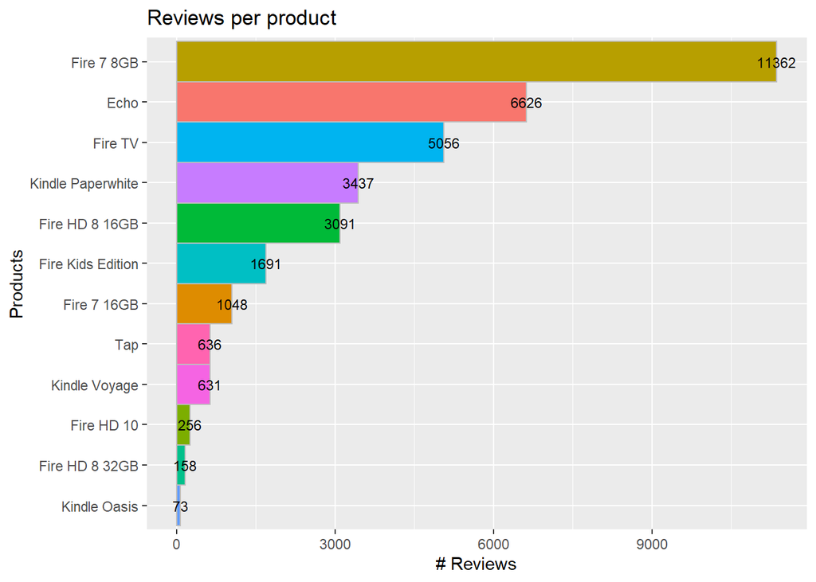

```r
ggplot(data3, aes(reorder(Product,Product,length), fill=Product))+
geom_bar(width=1, colour="gray")+ geom_text(aes(y=..count.., label=..count..),
                   stat="count", color="black",
                   hjust=0.5, size=3)+ labs(title="Reviews per product", y="# Reviews", x = "Products")+
                   theme(legend.position="none") + coord_flip()
```

*Exploration of variable ‘reviews.date’*

Since this variable originally is in the character format, it first needs to be converted to date format year-month-date.

```r
data3$reviews.date <- ymd_hms(data3$reviews.date)
str(data3$reviews.date)
```

```
##  POSIXct[1:34065], format: "2017-01-13" "2017-01-13" "2017-01-13" "2017-01-13" "2017-01-12" ...
```

Check for NA’s

```r
sum(is.na(data3$reviews.date))
```

```
## [1] 23
```

```r
which(is.na(data3$reviews.date))
```

```
##  [1]  2882  2883  2884  2885  2886  2887  2888  2889 20793 20794 20795 20796
## [13] 20797 20798 20799 20800 20801 20802 28073 28385 28981 34062 34064
```

Remove missing values (NA’s) and confirm that there is not a single missing value afterwards

```r
data4 = data3[complete.cases(data3$reviews.date),]
sum(is.na(data4$reviews.date))
```

```
## [1] 0
```

Categorize reviews by month and day of publishing

```r
data4$month <- floor_date(data4$reviews.date, unit = "month")
data4$day <- floor_date(data4$reviews.date, unit = "day")
```

Time span of reviews

```r
min(data4$month)
```

```
## [1] "2010-09-01 UTC"
```

```r
max(data4$month)
```

```
## [1] "2018-04-01 UTC"
```

Histogram for review date distribution per month

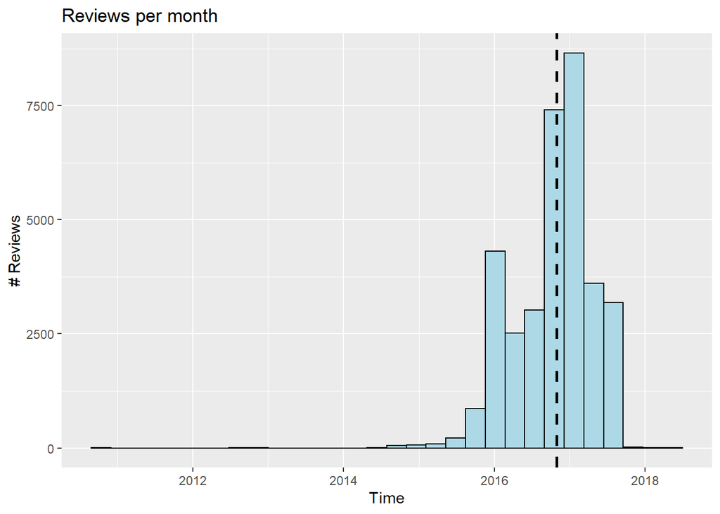

```r
ggplot(data4, aes(x=month, stat(count))) +
 geom_histogram(bins=30, colour="black", fill="lightblue")+
  geom_vline(aes(xintercept=mean(day)),
            color="black", linetype="dashed", size=1)+
  labs(title="Reviews per month", y="# Reviews", x = "Time")+
  theme_update(plot.title = element_text(hjust = 0.5))
```

*Products vs reviews.date* Line chart to plot Products over reviews.date to see which products were reviewed in which time span

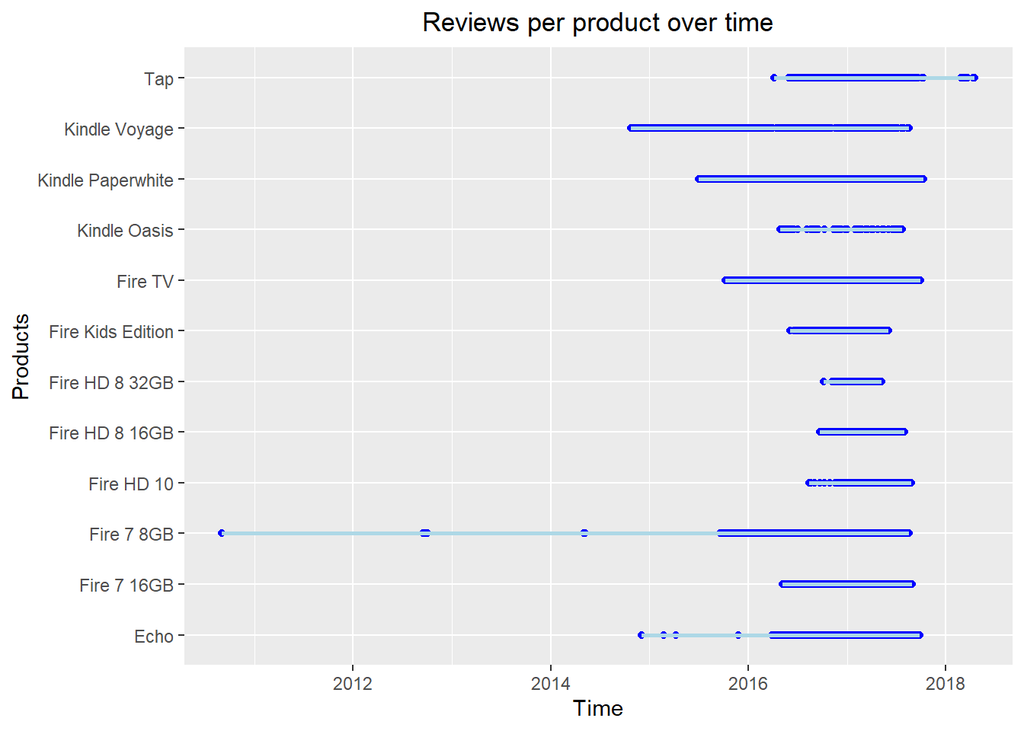

```r
ggplot(data4, aes(x = day, y = Product)) + geom_point(colour="blue") + geom_smooth(method='lm', formula=y~x, colour="lightblue") + labs(title="Reviews per product over time", y="Products", x = "Time")+
  theme_update(plot.title = element_text(hjust = 0.5))
```

*Exploration of variable ‘reviews.rating’* Check for NA’s (Products not considered for analysis)

```r
sum(is.na(data4$reviews.rating))
```

```
## [1] 19
```

After removing missing data of the previous variables, there are 19 empty values left at reviews.rating.

Remove missing values (NA’s)

```r
data5 = data4[complete.cases(data4$reviews.rating),]
```

The new data frame has 34,023 observations, meaning the 19 entries where the review rating was missing were removed.

Confirm that there is not a single missing value

```r
sum(is.na(data5$reviews.rating))
```

```
## [1] 0
```

Review statistics

```r
describe(data5$reviews.rating)
```

```
## data5$reviews.rating
##        n  missing distinct     Info     Mean      Gmd
##    34023        0        5    0.661     4.59   0.6146
##
## lowest : 1 2 3 4 5, highest: 1 2 3 4 5
##
## Value          1     2     3     4     5
## Frequency    355   381  1467  8464 23356
## Proportion 0.010 0.011 0.043 0.249 0.686
```

Review ratings distribution

```r
sort(table(data5$reviews.rating))
```

```
##
##     1     2     3     4     5
##   355   381  1467  8464 23356
```

Review ratings distribution in a bar chart

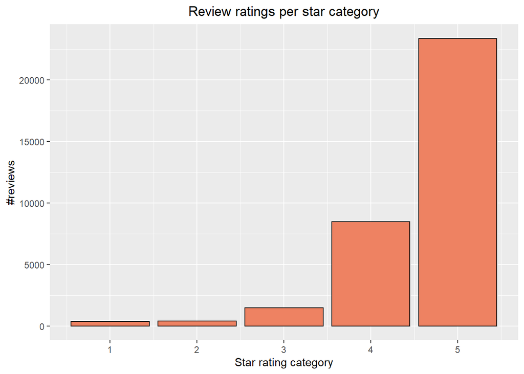

```r
ggplot(data5, aes(x=data5$reviews.rating))+
  geom_bar(data = data5, stat = "count", colour="black", fill="salmon2",
  position = "stack")+
   labs(title="Review ratings per star category", y="#reviews", x = "Star rating category")+
  theme_update(plot.title = element_text(hjust = 0.5))
```

*Exploration of variable ‘reviews.text’* Check for NA’s

```r
sum(is.na(data5$reviews.text))
```

```
## [1] 0
```

Review statistics

```r
data5$textlength<-nchar(data5$reviews.text)
describe(data5$textlength)
```

```
## data5$textlength
##        n  missing distinct     Info     Mean      Gmd      .05      .10
##    34023        0      998        1    157.4    128.7       52       56
##      .25      .50      .75      .90      .95
##       70      106      183      304      413
##
## lowest :    6    9   16   24   34, highest: 3097 3668 3697 4184 8351
```

Check reviews distribution by word count occurences

```r
sort(table(data5$textlength), decreasing = T)
```

```
##
##   50   51   53   55   52   56   57   54   58   61   65   59   64   62   63   67
##  844  533  451  449  442  406  395  392  390  384  381  379  375  365  363  357
##   60   69   68   66   72   70   71   75   73   78   77   74   76   79   83   81
##  351  347  344  335  333  313  307  301  293  281  278  274  274  272  265  259
##   84   85   80   86   82   89   91   90   93   88   92   87   95   94   99   96
##  256  249  247  238  234  229  228  226  223  217  214  212  211  207  207  199
##  105   98  100  101  102  103   97  106  110  107  112  109  108  115  111  113
##  196  195  189  187  187  184  181  178  178  176  167  166  164  163  161  160
##  104  114  122  121  118  120  116  129  117  119  127  144  123  134  133  124
##  159  157  155  151  145  145  143  143  141  137  137  134  131  128  126  125
##  136  125  130  132  126  128  131  135  147  149  137  141  154  143  145  139
##  125  124  123  122  120  117  117  117  114  114  113  111  110  108  108  107
##  150  140  146  138  158  162  151  165  142  156  148  153  159  155  163  177
##  107  106  105  102  102  102  100   99   96   94   93   93   93   91   91   91
```

[output cut: 112 more lines]

Check potential outliers with word count > 4000

```r
filter(data5, data5$textlength > 4000)
```

```
##   reviews.date reviews.rating
## 1   2016-10-05              4
## 2   2017-08-04              5
##                                                                                                                                                                                                                                                                                                          …
## 1 I've had lots of tablets in the past, mostly from the Samsung line, but this is my first Amazon Fire, so I want to write this review for others who have never tried one of these. At the time that this was written, Alexa had not been added to the tablet.First, while this device runs an Android t…
## 2                                                                                                                                                                                                                                                                                                        …
##          Product      month        day textlength
## 1 Fire HD 8 32GB 2016-10-01 2016-10-05       8351
## 2        Fire TV 2017-08-01 2017-08-04       4184
```

Review length distribution in a bar chart (for word count < 1000)

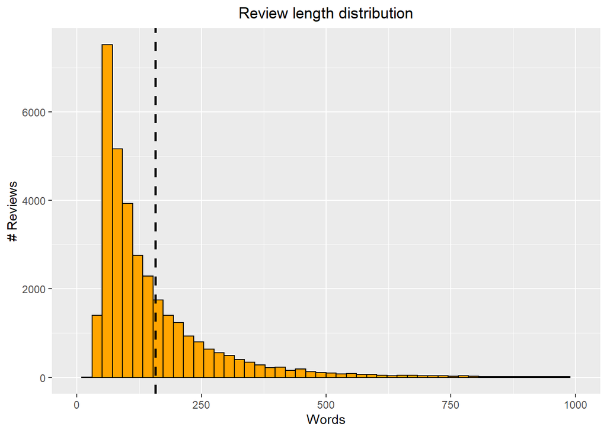

```r
ggplot(data5, aes(x = data5$textlength, stat(count))) +
  geom_histogram( bins=50, colour="black", fill="orange")+
  geom_vline(aes(xintercept=mean(data5$textlength)),
            color="black", linetype="dashed", size=1)+
  labs(title="Review length distribution", y="# Reviews", x = "Words")+
  theme_update(plot.title = element_text(hjust = 0.5))+
  xlim(0, 1000)
```

Review length over time

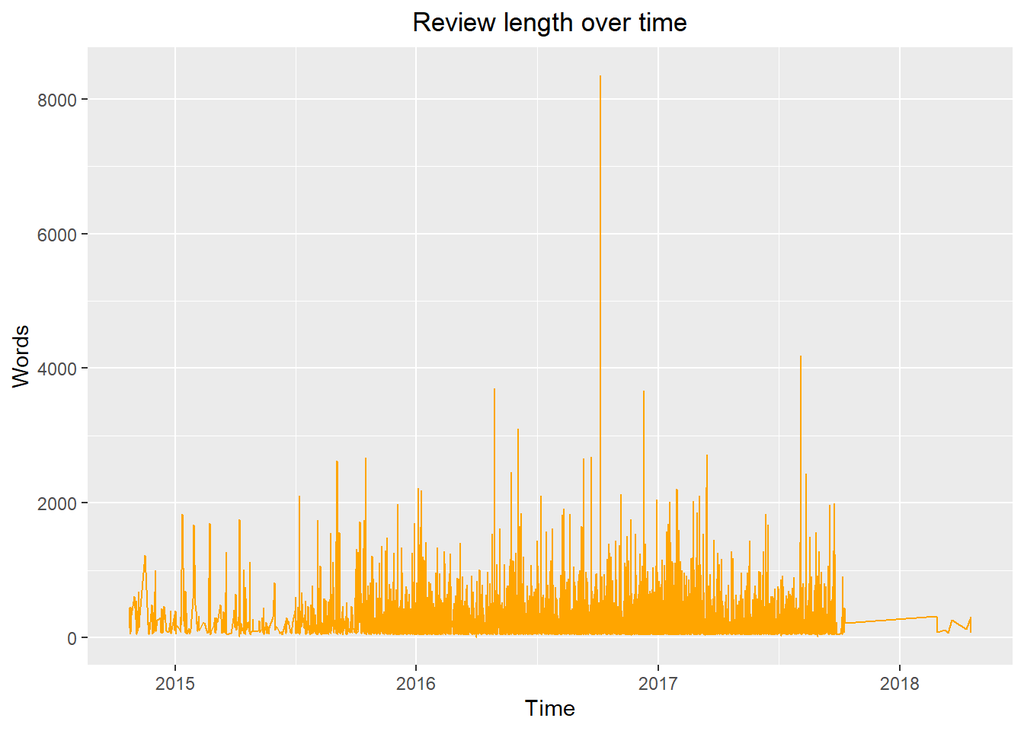

```r
 ggplot(data5, aes(data5$day, data5$textlength, group = 1)) +
          geom_line(colour="Orange") +
          labs(title = "Review length over time", x = "Time", y = "Words") +
  theme(legend.position="none")
```

*Explore data quality*

```
Variable 'asins' (Product)
```

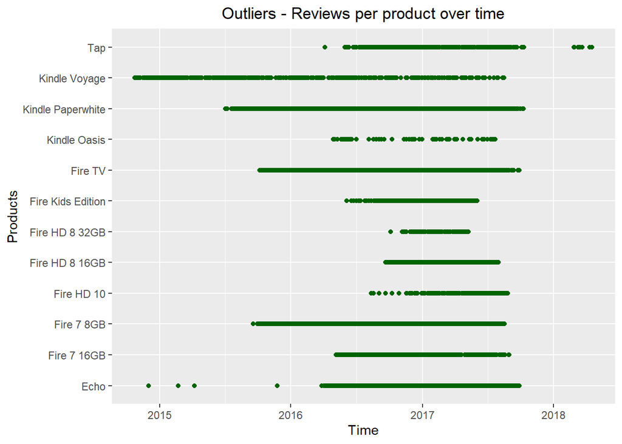

[output not shown]

```r
 ggplot(data5, aes(data5$day,data5$Product, group = 1)) +
  geom_point(colour= "dark green") +
          labs(title = "Outliers - Reviews per product over time", x = "Time", y = "Products")+
  theme(legend.position="none")
```

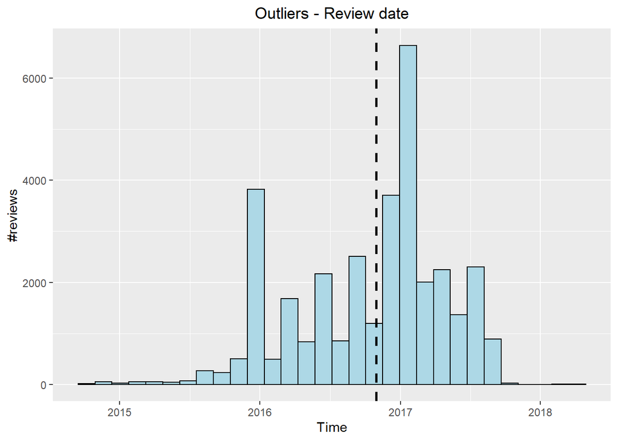

```r
ggplot(data5, aes(x=data5$month, stat(count))) +
 geom_histogram(bins=30, colour="black", fill="lightblue")+
  geom_vline(aes(xintercept=mean(data5$day)),
            color="black", linetype="dashed", size=1)+
  labs(title="Outliers - Review date", y="#reviews", x = "Time")+
  theme_update(plot.title = element_text(hjust = 0.5))
```

```r
    filter(data5, day >= "2014-01-01", day <= "2015-06-01")
```

```
##     reviews.date reviews.rating
## 1     2015-03-27              5
## 2     2015-03-14              5
## 3     2015-03-14              5
## 4     2015-03-10              5
## 5     2015-03-02              5
## 6     2015-03-02              5
## 7     2015-02-28              5
## 8     2015-02-23              5
## 9     2015-02-20              5
## 10    2015-02-19              5
## 11    2015-01-28              5
## 12    2015-01-23              5
## 13    2015-01-16              5
## 14    2015-01-10              5
```

[output cut: 588 more lines]

```
Variable 'reviews.text'
```

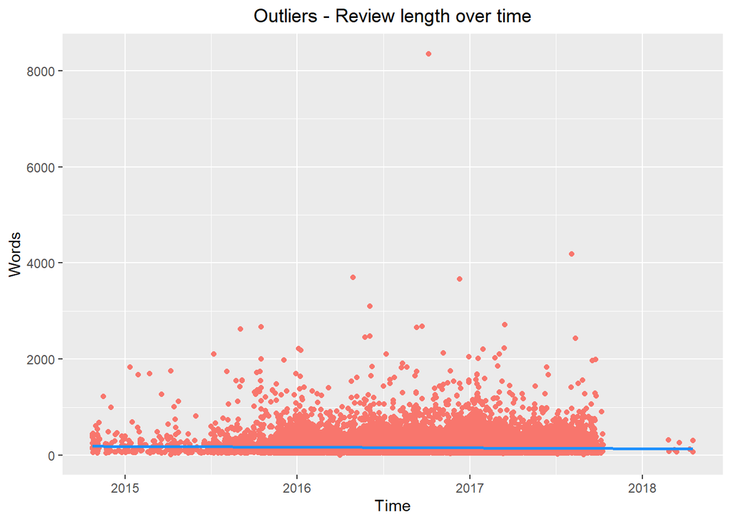

```r
 ggplot(data5, aes(day, textlength, group = 1, colour= "green")) +
  geom_point() +
          geom_smooth(method='lm',formula=y~x,col="dodgerblue") +
         labs(title = "Outliers - Review length over time", x = "Time", y = "Words")+
  theme(legend.position="none")
```

Remove outliers (review lenght > 4000)

```r
#Remove outliers (review length > 4000)
data5 <- data5[data5$textlength < 4000,]
```

Show reviews from 2018

```r
filter(data5, day >= "2017-12-31", day <= "2019-01-01")
```

```
##   reviews.date reviews.rating
## 1   2018-02-27              4
## 2   2018-04-18              4
## 3   2018-04-11              2
## 4   2018-03-15              5
## 5   2018-02-26              4
## 6   2018-03-21              1
## 7   2018-04-18              5
## 8   2018-03-10              3
##                                                                                                                                                                                                                                                                                                          …
## 1                                                                                                                                                                                                                                           Took a bit of time but I figured how to get the most out out …
## 2                  I wanted a portable speaker that worked with Amazon prime music. There is nothing in the market right now that does that except for the Tap. For the $100 price its fine. I would rather spend $200 and get a better sound quality speaker though since it will be used outside as wel…
## 3                                                                                                                                                                                                      Not too satisfied with the sound and it loses Bluetooth connection no matter what phone I use (eit…
## 4                                                                                                                                                                                                                                                     Great speaker for around the house listening to mus…
## 5 This was my first Alexa device and until I got a dot I was very satisfied with it After the Dot, I missed the voice activation. No Amazon has updated the software to where it will respond to voice commands so not problems with it at all . You need to keep it on the charge stand if you are going…
## 6                                                         I spent more time trying get it functioning than I did actually keeping this product. After a couple of days and never getting it to understand or follow my commands I returned it to BB. Also it kept trying to sell me products which I real…
## 7                                                                                                                                                                                                                                                                Loud enough for small gatherings & very …
## 8                                                                                                                                                                                                           My Echo hasn't updated to the latest version that allows for hands-free operation. I'm not su…
##   Product      month        day textlength
## 1     Tap 2018-02-01 2018-02-27         84
## 2     Tap 2018-04-01 2018-04-18        301
## 3     Tap 2018-04-01 2018-04-11        121
## 4     Tap 2018-03-01 2018-03-15         74
## 5     Tap 2018-02-01 2018-02-26        318
## 6     Tap 2018-03-01 2018-03-21        262
## 7     Tap 2018-04-01 2018-04-18         63
## 8     Tap 2018-03-01 2018-03-10        116
```

*4.3 Data preparation*

*Select Data* Restructure data frame

```r
# remove reviews.date and month variables
data5 = subset(data5, select = -c(reviews.date, month, textlength))
```

```r
# Assign new names to columns
names(data5) <- c("rating", "text", "product", "date")
```

```r
# Change column order
data5 <- data5[c("product","rating", "text", "date")]
```

```r
#Remove all duplicates
data6 <- distinct(data5, text, .keep_all = T)
sum(duplicated(data5$reviews.text))
```

```
## [1] 0
```

```r
sum(duplicated(data6$reviews.text))
```

```
## [1] 0
```

Merging products

```r
data6$product[data6$product == 'Fire 7 8GB' | data6$product == 'Fire 7 16GB'] <- 'Fire 7'
data6$product[data6$product == 'Fire HD 8 16GB' | data6$product == 'Fire HD 8 32GB'] <- 'Fire HD 8'
```

Creating new subset for relevant time spans only

1. 8 weeks before and after Prime Day’s

```r
pre82015<-subset(data6, data6$date> "2015-05-19" & data6$date < "2015-07-16") #8 weeks before Prime Day '15
pre82016<-subset(data6, data6$date> "2016-05-19" & data6$date < "2016-07-16") #8 weeks before Prime Day '16
pre82017<-subset(data6, data6$date> "2017-05-17" & data6$date < "2017-07-12") #8 weeks before Prime Day '17
pre8<- rbind(pre82015,pre82016,pre82017)                                      #8 weeks before all Prime Days
aft82015<-subset(data6, data6$date> "2015-07-14" & data6$date < "2015-09-09") #8 weeks after Prime Day '15
aft82016<-subset(data6, data6$date> "2016-07-14" & data6$date < "2016-09-09") #8 weeks after Prime Day '16
aft82017<-subset(data6, data6$date> "2017-07-10" & data6$date < "2017-09-05") #8 weeks after Prime Day '17
aft8<- rbind(aft82015,aft82016,aft82017)                                      #8 weeks after all Prime Days
```

2. 10 weeks before and after Prime Day’s

```r
pre102015<-subset(data6, data6$date> "2015-05-05" & data6$date < "2015-07-16") #10 weeks before Prime Day '15
pre102016<-subset(data6, data6$date> "2016-05-05" & data6$date < "2016-07-16") #10 weeks before Prime Day '16
pre102017<-subset(data6, data6$date> "2017-05-01" & data6$date < "2017-07-12") #10 weeks before Prime Day '17
pre10<- rbind(pre102015,pre102016,pre102017)                                   #10 weeks before all Prime Days
aft102015<-subset(data6, data6$date> "2015-07-14" & data6$date < "2015-09-23") #10 weeks after Prime Day '15
aft102016<-subset(data6, data6$date> "2016-07-14" & data6$date < "2016-09-23") #10 weeks after Prime Day '16
aft102017<-subset(data6, data6$date> "2017-07-10" & data6$date < "2017-09-19") #10 weeks after Prime Day '17
aft10<- rbind(aft102015,aft102016,aft102017)                                   #10 weeks after all Prime Days
```

3. 12 weeks before and after Prime Day’s

```r
pre122015<-subset(data6, data6$date> "2015-04-21" & data6$date < "2015-07-16") #12 weeks before Prime Day '15
pre122016<-subset(data6, data6$date> "2016-04-21" & data6$date < "2016-07-16") #12 weeks before Prime Day '16
pre122017<-subset(data6, data6$date> "2017-04-17" & data6$date < "2017-07-12") #12 weeks before Prime Day '17
pre12<- rbind(pre122015,pre122016,pre122017)                                  #12 weeks before all Prime Days
nrow(pre12)
```

```
## [1] 6246
```

```r
aft122015<-subset(data6, data6$date> "2015-07-14" & data6$date < "2015-10-07") #12 weeks after Prime Day '15
aft122016<-subset(data6, data6$date> "2016-07-14" & data6$date < "2016-10-07") #12 weeks after Prime Day '16
aft122017<-subset(data6, data6$date> "2017-07-10" & data6$date < "2017-10-03") #12 weeks after Prime Day '17
aft12<- rbind(aft122015,aft122016,aft122017)                                   #12 weeks after all Prime Days
nrow(aft12)
```

```
## [1] 6241
```

*General data set cleaning*

```r
# Create new data frame for relevant reviews only
data6 <- rbind(pre12,aft12)
nrow(data6)
```

```
## [1] 12487
```

```r
# Encode all text with latin1 and ASCII
data6$text<-invisible(iconv(data6$text, "latin1", "ASCII", sub=""))
```

```r
#Remove all non-alphanumeric characters.
data6$text<-invisible(str_replace_all(data6$text, "[^[:alnum:]]", " "))
```

For faster processing remove previous data frames

```r
rm(dataset, data1, data2, data3, data4, data5)
```

*Text mining*

```r
# Create text corpora of data set
totalCorpus <- Corpus(VectorSource(data6$text))
# Remove special characters
preprocessCorpus(totalCorpus)
```

```
## <<SimpleCorpus>>
## Metadata:  corpus specific: 1, document level (indexed): 0
## Content:  documents: 12487
```

```r
space <- content_transformer(function (x , pattern ) gsub(pattern, " ", x))
totalCorpus <- tm_map(totalCorpus, space, "/")
totalCorpus <- tm_map(totalCorpus, space, "@")
totalCorpus <- tm_map(totalCorpus, space, "\\|")
# Convert text to lower case
totalCorpus <- tm_map(totalCorpus, content_transformer(tolower))
# Remove numbers
totalCorpus <- tm_map(totalCorpus, removeNumbers)
# Remove common stopwords
totalCorpus <- tm_map(totalCorpus, removeWords, stopwords("english"))
# Remove defined words
totalCorpus <- tm_map(totalCorpus, removeWords, c("amazon","aamazon","amazone","tap","kindle","kindl", "paperwhit", "paperwhite", "paperback", "voyage","oasis", "fire","tv", "hd", "echo", "one", "two", "three", "first", "second", "third" ))
# Remove punctuations
totalCorpus <- tm_map(totalCorpus, removePunctuation)
# Remove white spaces
totalCorpus <- tm_map(totalCorpus, stripWhitespace)
# Stem texts
totalCorpus <- tm_map(totalCorpus, stemDocument)
# Total Sentiment score and rating means
TotalSentiment <- analyzeSentiment(totalCorpus)
TotalMeanSent <- mean(TotalSentiment$SentimentGI, na.rm = TRUE)
TotalMeanSent
```

```
## [1] 0.2615851
```

```r
# Mean star rating
TotalMeanRating <- mean(data6$rating, na.rm = TRUE)
TotalMeanRating
```

```
## [1] 4.618003
```

```r
# No. of positive, neutral and negative reviews
Totalreviews <- table(TotalSentiment$SentimentGI)
Totalposreviews <- sum(Totalreviews[names(Totalreviews)> 0])#positive
Totalposreviews
```

```
## [1] 10946
```

```r
Totalneutreviews <- sum(Totalreviews[names(Totalreviews)== 0])#neutral
Totalneutreviews
```

```
## [1] 946
```

```r
Totalnegreviews <- sum(Totalreviews[names(Totalreviews)< 0]) #negative
Totalnegreviews
```

```
## [1] 594
```

```r
TotalReviewRatio <- (Totalposreviews)/(Totalposreviews+Totalneutreviews+Totalnegreviews)
TotalReviewRatio
```

```
## [1] 0.8766619
```

*Clean Data*

```r
# Create text corpora of subsets
pre82015docs <- Corpus(VectorSource(pre82015$text))
pre82016docs <- Corpus(VectorSource(pre82016$text))
pre82017docs <- Corpus(VectorSource(pre82017$text))
pre8docs <- Corpus(VectorSource(pre8$text))
pre102015docs <- Corpus(VectorSource(pre102015$text))
pre102016docs <- Corpus(VectorSource(pre102016$text))
pre102017docs <- Corpus(VectorSource(pre102017$text))
pre10docs <- Corpus(VectorSource(pre10$text))
pre122015docs <- Corpus(VectorSource(pre122015$text))
pre122016docs <- Corpus(VectorSource(pre122016$text))
pre122017docs <- Corpus(VectorSource(pre122017$text))
pre12docs <- Corpus(VectorSource(pre12$text))

aft82015docs <- Corpus(VectorSource(aft82015$text))
aft82016docs <- Corpus(VectorSource(aft82016$text))
aft82017docs <- Corpus(VectorSource(aft82017$text))
aft8docs <- Corpus(VectorSource(aft8$text))
aft102015docs <- Corpus(VectorSource(aft102015$text))
aft102016docs <- Corpus(VectorSource(aft102016$text))
aft102017docs <- Corpus(VectorSource(aft102017$text))
aft10docs <- Corpus(VectorSource(aft10$text))
aft122015docs <- Corpus(VectorSource(aft122015$text))
aft122016docs <- Corpus(VectorSource(aft122016$text))
aft122017docs <- Corpus(VectorSource(aft122017$text))
aft12docs <- Corpus(VectorSource(aft12$text))
```

*Prior 8 weeks* 2015

```r
# Remove special characters
preprocessCorpus(pre82015docs)
```

```
## <<SimpleCorpus>>
## Metadata:  corpus specific: 1, document level (indexed): 0
## Content:  documents: 69
```

```r
space <- content_transformer(function (x , pattern ) gsub(pattern, " ", x))
pre82015docs <- tm_map(pre82015docs, space, "/")
pre82015docs <- tm_map(pre82015docs, space, "@")
pre82015docs <- tm_map(pre82015docs, space, "\\|")
# Convert text to lower case
pre82015docs <- tm_map(pre82015docs, content_transformer(tolower))
# Remove numbers
pre82015docs <- tm_map(pre82015docs, removeNumbers)
# Remove common stopwords
pre82015docs <- tm_map(pre82015docs, removeWords, stopwords("english"))
# Remove defined words
pre82015docs <- tm_map(pre82015docs, removeWords, c("amazon","aamazon","amazone","tap","kindle","kindl", "paperwhit", "paperwhite", "paperback", "voyage","oasis", "fire","tv", "hd", "echo", "one", "two", "three", "first", "second", "third" ))
# Remove punctuations
pre82015docs <- tm_map(pre82015docs, removePunctuation)
# Remove white spaces
pre82015docs <- tm_map(pre82015docs, stripWhitespace)
# Stem texts
pre82015docs <- tm_map(pre82015docs, stemDocument)
```

*Data Processing*

```r
#Convert corpus
pre82015dtm <- TermDocumentMatrix(pre82015docs)
pre82015m <- as.matrix(pre82015dtm)
pre82015sort <- sort(rowSums(pre82015m),decreasing=TRUE)
pre82015df <- data.frame(word = names(pre82015sort),freq=pre82015sort)
#Show top 10 most frequent words with count
wordspre815<-head(pre82015df, 10)
wordspre815
```

```
##          word freq
## read     read   49
## light   light   28
## great   great   27
## easi     easi   22
## use       use   22
## love     love   19
## like     like   18
## screen screen   18
## book     book   16
## page     page   15
```

```r
# Mean sentiment score of time frame
pre82015$sentiment <- analyzeSentiment(pre82015docs,aggregate = NULL)
meanSApre815 <-mean(pre82015$sentiment$SentimentG, na.rm = TRUE)
meanSApre815
```

```
## [1] 0.2823522
```

```r
# Mean star rating
meanratingpre815 <- mean(pre82015$rating)
meanratingpre815
```

```
## [1] 4.768116
```

```r
#Show each review's individual sentiment direction (pos/neut/neg)
pre82015$direction <- convertToDirection(pre82015$sentiment$SentimentGI)
```

```r
# Sentiment ratio pos/neg
pospre82015 <- pre82015$direction == 'positive'
neutpre82015 <- pre82015$direction == 'neutral'
# Sentiment associations
          #find associations (correlations) between frequent terms
findAssocs(pre82015dtm, terms = "like", corlimit = 0.5)
```

```
## $like
##         ipad       almost     argument       around        assum       averag
##         0.78         0.78         0.78         0.78         0.78         0.78
##          bad      balloon        basic        becom          bed        brand
##         0.78         0.78         0.78         0.78         0.78         0.78
##         case         caus       caveat      continu        crowd         cycl
##         0.78         0.78         0.78         0.78         0.78         0.78
##        decid        dedic       depend      disagre         dodo     doooooom
##         0.78         0.78         0.78         0.78         0.78         0.78
##          due         ebay         eink       except         find        frank
##         0.78         0.78         0.78         0.78         0.78         0.78
##       garmin          got          gps         half         imho     interest
##         0.78         0.78         0.78         0.78         0.78         0.78
##          key         kind      leather          lit          lug       machin
##         0.78         0.78         0.78         0.78         0.78         0.78
##       market         mini         near      netflix         nich     nintendo
##         0.78         0.78         0.78         0.78         0.78         0.78
##        notic         nudg      obsolet     offbrand        outgo       precis
##         0.78         0.78         0.78         0.78         0.78         0.78
##       prefer priceperform      proport         rate        ratio   readingcas
##         0.78         0.78         0.78         0.78         0.78         0.78
##      refresh       review         room        round       second        solid
##         0.78         0.78         0.78         0.78         0.78         0.78
##     somebodi      sophist        spend     standard      summari    tabletlik
##         0.78         0.78         0.78         0.78         0.78         0.78
##         tech         tldr        trump      ubiquit        unlik      various
##         0.78         0.78         0.78         0.78         0.78         0.78
##        watch          way         wear         word          yes         ymmv
##         0.78         0.78         0.78         0.78         0.78         0.78
##         plus      thicker         feel      sometim        phone         time
##         0.76         0.76         0.76         0.76         0.75         0.75
##         site        model         just          dpi      resolut     distract
##         0.73         0.70         0.68         0.64         0.64         0.64
##          die       screen        devic         wife         read         want
##         0.64         0.63         0.60         0.55         0.54         0.54
##       person        wrong         come         sell       specif         week
##         0.53         0.53         0.53         0.53         0.53         0.53
##         last         need          fit        kindl       strain
##         0.50         0.50         0.50         0.50         0.50
```

```r
negpre82015 <- pre82015$direction == 'negative'
pre82015ratio <- (sum(pospre82015)/sum(pospre82015+neutpre82015+negpre82015))
pre82015ratio
```

```
## [1] 0.942029
```

2016

```r
# Remove special characters
preprocessCorpus(pre82016docs)
```

```
## <<SimpleCorpus>>
## Metadata:  corpus specific: 1, document level (indexed): 0
## Content:  documents: 2102
```

```r
space <- content_transformer(function (x , pattern ) gsub(pattern, " ", x))
pre82016docs <- tm_map(pre82016docs, space, "/")
pre82016docs <- tm_map(pre82016docs, space, "@")
pre82016docs <- tm_map(pre82016docs, space, "\\|")
# Convert text to lower case
pre82016docs <- tm_map(pre82016docs, content_transformer(tolower))
# Remove numbers
pre82016docs <- tm_map(pre82016docs, removeNumbers)
# Remove common stopwords
pre82016docs <- tm_map(pre82016docs, removeWords, stopwords("english"))
# Remove defined words
pre82016docs <- tm_map(pre82016docs, removeWords, c("amazon","aamazon","amazone","tap","kindle","kindl", "paperwhit", "paperwhite", "paperback", "voyage","oasis", "fire","tv", "hd", "echo", "one", "two", "three", "first", "second", "third" ))
# Remove punctuations
pre82016docs <- tm_map(pre82016docs, removePunctuation)
# Remove white spaces
pre82016docs <- tm_map(pre82016docs, stripWhitespace)
# Stem texts
pre82016docs <- tm_map(pre82016docs, stemDocument)
```

*SA* Data Processing

```r
#Convert corpus
pre82016dtm <- TermDocumentMatrix(pre82016docs)
pre82016m <- as.matrix(pre82016dtm)
pre82016sort <- sort(rowSums(pre82016m),decreasing=TRUE)
pre82016df <- data.frame(word = names(pre82016sort),freq=pre82016sort)
#Show top 10 most frequent words with count
wordspre816<-head(pre82016df, 10)
wordspre816
```

```
##          word freq
## great   great  715
## use       use  714
## tablet tablet  631
## love     love  534
## read     read  410
## easi     easi  375
## can       can  372
## like     like  332
## work     work  328
## get       get  325
```

```r
# Sentiment scores per review
pre82016$sentiment <- analyzeSentiment(pre82016docs,aggregate = NULL)
# Mean sentiment score of time frame
meanSApre816 <- mean(pre82016$sentiment$SentimentGI, na.rm = TRUE)
meanSApre816
```

```
## [1] 0.2542179
```

```r
# Mean star rating
meanratingpre816 <- mean(pre82016$rating)
meanratingpre816
```

```
## [1] 4.58373
```

```r
# Show each review's individual sentiment direction (pos/neut/neg)
pre82016$direction <- convertToDirection(pre82016$sentiment$SentimentGI)
```

```r
# Sentiment positive reviews ratio
pospre82016 <- pre82016$direction == 'positive'
neutpre82016 <- pre82016$direction == 'neutral'
negpre82016 <- pre82016$direction == 'negative'
pre82016ratio <- (sum(pospre82016)/sum(pospre82016+neutpre82016+negpre82016))
pre82016ratio
```

```
## [1] 0.8725024
```

```r
# Sentiment associations
findAssocs(pre82016dtm, terms = "like", corlimit = 0.2)
```

```
## $like
## began think
##  0.23  0.22
```

2017

```r
# Remove special characters
preprocessCorpus(pre82017docs)
```

```
## <<SimpleCorpus>>
## Metadata:  corpus specific: 1, document level (indexed): 0
## Content:  documents: 2491
```

```r
space <- content_transformer(function (x , pattern ) gsub(pattern, " ", x))
pre82017docs <- tm_map(pre82017docs, space, "/")
pre82017docs <- tm_map(pre82017docs, space, "@")
pre82017docs <- tm_map(pre82017docs, space, "\\|")
# Convert text to lower case
pre82017docs <- tm_map(pre82017docs, content_transformer(tolower))
# Remove numbers
pre82017docs <- tm_map(pre82017docs, removeNumbers)
# Remove common stopwords
pre82017docs <- tm_map(pre82017docs, removeWords, stopwords("english"))
# Remove defined words
pre82017docs <- tm_map(pre82017docs, removeWords, c("amazon","aamazon","amazone","tap","kindle","kindl", "paperwhit", "paperwhite", "paperback", "voyage","oasis", "fire","tv", "hd", "echo", "one", "two", "three", "first", "second", "third" ))
# Remove punctuations
pre82017docs <- tm_map(pre82017docs, removePunctuation)
# Remove white spaces
pre82017docs <- tm_map(pre82017docs, stripWhitespace)
# Stem texts
pre82017docs <- tm_map(pre82017docs, stemDocument)
```

*SA* Data Processing

```r
#Convert corpus
pre82017dtm <- TermDocumentMatrix(pre82017docs)
pre82017m <- as.matrix(pre82017dtm)
pre82017sort <- sort(rowSums(pre82017m),decreasing=TRUE)
pre82017df <- data.frame(word = names(pre82017sort),freq=pre82017sort)
#Show top 10 most frequent words with count
wordspre817<-head(pre82017df, 10)
wordspre817
```

```
##          word freq
## great   great  782
## use       use  751
## love     love  722
## easi     easi  470
## tablet tablet  445
## work     work  350
## can       can  347
## read     read  347
## bought bought  330
## good     good  330
```

```r
# Sentiment scores per review
pre82017$sentiment <- analyzeSentiment(pre82017docs,aggregate = NULL)
# Mean sentiment score of time frame
meanSApre817 <- mean(pre82017$sentiment$SentimentGI, na.rm = TRUE)
meanSApre817
```

```
## [1] 0.2652909
```

```r
# Mean star rating
meanratingpre817 <- mean(pre82017$rating)
meanratingpre817
```

```
## [1] 4.609394
```

```r
#Show each review's individual sentiment direction (pos/neut/neg)
pre82017$direction <- convertToDirection(pre82017$sentiment$SentimentGI)
```

```r
# Sentiment positive reviews ratio
pospre82017 <- pre82017$direction == 'positive'
neutpre82017 <- pre82017$direction == 'neutral'
negpre82017 <- pre82017$direction == 'negative'
pre82017ratio <- (sum(pospre82017)/sum(pospre82017+neutpre82017+negpre82017))
pre82017ratio
```

```
## [1] 0.868326
```

```r
# Sentiment associations
findAssocs(pre82017dtm, terms = "like", corlimit = 0.2)
```

```
## $like
##  beachbag construct      page
##      0.25      0.25      0.20
```

all Pre8 periods

```r
# Remove special characters
preprocessCorpus(pre8docs)
```

```
## <<SimpleCorpus>>
## Metadata:  corpus specific: 1, document level (indexed): 0
## Content:  documents: 4662
```

```r
space <- content_transformer(function (x , pattern ) gsub(pattern, " ", x))
pre8docs <- tm_map(pre8docs, space, "/")
pre8docs <- tm_map(pre8docs, space, "@")
pre8docs <- tm_map(pre8docs, space, "\\|")
# Convert text to lower case
pre8docs <- tm_map(pre8docs, content_transformer(tolower))
# Remove numbers
pre8docs <- tm_map(pre8docs, removeNumbers)
# Remove common stopwords
pre8docs <- tm_map(pre8docs, removeWords, stopwords("english"))
# Remove defined words
pre8docs <- tm_map(pre8docs, removeWords, c("amazon","aamazon","amazone","tap","kindle","kindl", "paperwhit", "paperwhite", "paperback", "voyage","oasis", "fire","tv", "hd", "echo", "one", "two", "three", "first", "second", "third" ))
# Remove punctuations
pre8docs <- tm_map(pre8docs, removePunctuation)
# Remove white spaces
pre8docs <- tm_map(pre8docs, stripWhitespace)
# Stem texts
pre8docs <- tm_map(pre8docs, stemDocument)
```

*SA* Data Processing

```r
#Convert corpus
pre8dtm <- TermDocumentMatrix(pre8docs)
pre8m <- as.matrix(pre8dtm)
pre8sort <- sort(rowSums(pre8m),decreasing=TRUE)
pre8df <- data.frame(word = names(pre8sort),freq=pre8sort)
#Show top 10 most frequent words with count
wordspre8<-head(pre8df, 10)
wordspre8
```

```
##          word freq
## great   great 1524
## use       use 1487
## love     love 1275
## tablet tablet 1079
## easi     easi  867
## read     read  806
## can       can  729
## work     work  683
## like     like  662
## bought bought  660
```

```r
# Sentiment scores per review
pre8$sentiment <- analyzeSentiment(pre8docs,aggregate = NULL)
# Mean sentiment score of time frame
meanSApre8 <- mean(pre8$sentiment$SentimentGI, na.rm = TRUE)
meanSApre8
```

```
## [1] 0.2605508
```

```r
# Mean star rating
meanratingpre8 <- mean(pre8$rating)
meanratingpre8
```

```
## [1] 4.600172
```

```r
# No. of positive, neutral and negative reviews
pre8reviews <- table(pre8$sentiment$SentimentGI)
pre8posreviews <- sum(pre8reviews[names(pre8reviews)> 0])#positive
pre8neutreviews <- sum(pre8reviews[names(pre8reviews)== 0])#neutral
pre8negreviews <- sum(pre8reviews[names(pre8reviews)< 0]) #negative
pre8ReviewRatio <- (pre8posreviews)/(pre8posreviews+pre8neutreviews+pre8negreviews)
pre8ReviewRatio
```

```
## [1] 0.8712999
```

*Prior 10 weeks*

2015

```r
# Remove special characters
preprocessCorpus(pre102015docs)
```

```
## <<SimpleCorpus>>
## Metadata:  corpus specific: 1, document level (indexed): 0
## Content:  documents: 77
```

```r
space <- content_transformer(function (x , pattern ) gsub(pattern, " ", x))
pre102015docs <- tm_map(pre102015docs, space, "/")
pre102015docs <- tm_map(pre102015docs, space, "@")
pre102015docs <- tm_map(pre102015docs, space, "\\|")
# Convert text to lower case
pre102015docs <- tm_map(pre102015docs, content_transformer(tolower))
# Remove numbers
pre102015docs <- tm_map(pre102015docs, removeNumbers)
# Remove common stopwords
pre102015docs <- tm_map(pre102015docs, removeWords, stopwords("english"))
# Remove defined words
pre102015docs <- tm_map(pre102015docs, removeWords, c("amazon","aamazon","amazone","tap","kindle","kindl", "paperwhit", "paperwhite", "paperback", "voyage","oasis", "fire","tv", "hd", "echo", "one", "two", "three", "first", "second", "third" ))
# Remove punctuations
pre102015docs <- tm_map(pre102015docs, removePunctuation)
# Remove white spaces
pre102015docs <- tm_map(pre102015docs, stripWhitespace)
# Stem texts
pre102015docs <- tm_map(pre102015docs, stemDocument)
```

*SA* Data Processing

```r
#Convert corpus
pre102015dtm <- TermDocumentMatrix(pre102015docs)
pre102015m <- as.matrix(pre102015dtm)
pre102015sort <- sort(rowSums(pre102015m),decreasing=TRUE)
pre102015df <- data.frame(word = names(pre102015sort),freq=pre102015sort)
#Show top 10 most frequent words with count
wordspre1015<-head(pre102015df, 10)
wordspre1015
```

```
##          word freq
## read     read   51
## great   great   29
## light   light   28
## use       use   23
## love     love   23
## easi     easi   22
## book     book   21
## screen screen   20
## like     like   19
## page     page   19
```

```r
# Sentiment scores per review
pre102015$sentiment <- analyzeSentiment(pre102015docs,aggregate = NULL)
# Mean sentiment score of time frame
meanSApre1015 <- mean(pre102015$sentiment$SentimentGI, na.rm = TRUE)
meanSApre1015
```

```
## [1] 0.2780999
```

```r
# Mean star rating
meanratingpre1015 <- mean(pre102015$rating)
meanratingpre1015
```

```
## [1] 4.779221
```

```r
# Show each review's individual sentiment direction (pos/neut/neg)
pre102015$direction <- convertToDirection(pre102015$sentiment$SentimentGI)
```

```r
# Sentiment positive reviews ratio
pospre102015 <- pre102015$direction == 'positive'
neutpre102015 <- pre102015$direction == 'neutral'
negpre102015 <- pre102015$direction == 'negative'
pre102015ratio <- (sum(pospre102015)/sum(pospre102015+neutpre102015+negpre102015))
pre102015ratio
```

```
## [1] 0.9350649
```

```r
# Sentiment associations
findAssocs(pre102015dtm, terms = "like", corlimit = 0.2)
```

```
## $like
##         ipad        dedic       almost     argument       around        assum
##         0.78         0.78         0.77         0.77         0.77         0.77
##       averag          bad      balloon        basic        becom          bed
##         0.77         0.77         0.77         0.77         0.77         0.77
##        brand         case         caus       caveat      continu        crowd
##         0.77         0.77         0.77         0.77         0.77         0.77
##         cycl        decid       depend      disagre         dodo     doooooom
##         0.77         0.77         0.77         0.77         0.77         0.77
##          due         ebay         eink       except         find        frank
##         0.77         0.77         0.77         0.77         0.77         0.77
##       garmin          gps         half         imho     interest          key
##         0.77         0.77         0.77         0.77         0.77         0.77
##         kind      leather          lug       machin       market         mini
##         0.77         0.77         0.77         0.77         0.77         0.77
##         near      netflix         nich     nintendo        notic         nudg
##         0.77         0.77         0.77         0.77         0.77         0.77
##      obsolet     offbrand        outgo       precis       prefer priceperform
##         0.77         0.77         0.77         0.77         0.77         0.77
##      proport         rate        ratio   readingcas      refresh       review
##         0.77         0.77         0.77         0.77         0.77         0.77
##         room        round       second        solid     somebodi      sophist
##         0.77         0.77         0.77         0.77         0.77         0.77
##        spend     standard      summari    tabletlik         tech         tldr
##         0.77         0.77         0.77         0.77         0.77         0.77
##        trump      ubiquit        unlik      various        watch         wear
##         0.77         0.77         0.77         0.77         0.77         0.77
##         word          yes         ymmv         plus      thicker      sometim
##         0.77         0.77         0.77         0.75         0.75         0.75
##        phone         time         site         feel        model         just
##         0.74         0.74         0.72         0.70         0.69         0.68
##          dpi     distract          die          got       screen        devic
##         0.64         0.64         0.64         0.64         0.59         0.59
##         read         wife         want          way       person        wrong
##         0.55         0.55         0.53         0.52         0.52         0.52
##         come          lit         sell       specif         week         last
##         0.52         0.52         0.52         0.52         0.52         0.50
##         need      resolut          fit       strain       enough          get
##         0.50         0.50         0.50         0.50         0.48         0.47
##       tablet      alreadi        anoth        swipe          say         will
##         0.46         0.41         0.41         0.41         0.40         0.38
##          eye        extra        worth        kindl      batteri        carri
##         0.37         0.36         0.36         0.36         0.33         0.33
##          can          buy          now        glass        sever      airplan
##         0.33         0.32         0.31         0.31         0.31         0.29
##          app        crisp      earlier     goodread      heavier        iphon
##         0.29         0.29         0.29         0.29         0.29         0.29
##       latest         load         mode         slow        wider       actual
##         0.29         0.29         0.29         0.29         0.29         0.29
##       awesom         burn        mobil   papperwhit       sensat        sleep
##         0.29         0.29         0.29         0.29         0.29         0.29
##         ttri        world         life       realli         mani          new
##         0.29         0.29         0.28         0.27         0.27         0.24
##    backlight        eread       better       friend         page        press
##         0.24         0.24         0.23         0.22         0.22         0.22
##       compar          use         size        paper
##         0.21         0.21         0.21         0.21
```

2016

```r
# Remove special characters
preprocessCorpus(pre102016docs)
```

```
## <<SimpleCorpus>>
## Metadata:  corpus specific: 1, document level (indexed): 0
## Content:  documents: 2443
```

```r
space <- content_transformer(function (x , pattern ) gsub(pattern, " ", x))
pre102016docs <- tm_map(pre102016docs, space, "/")
pre102016docs <- tm_map(pre102016docs, space, "@")
pre102016docs <- tm_map(pre102016docs, space, "\\|")
# Convert text to lower case
pre102016docs <- tm_map(pre102016docs, content_transformer(tolower))
# Remove numbers
pre102016docs <- tm_map(pre102016docs, removeNumbers)
# Remove common stopwords
pre102016docs <- tm_map(pre102016docs, removeWords, stopwords("english"))
# Remove defined words
pre102016docs <- tm_map(pre102016docs, removeWords, c("amazon","aamazon","amazone","tap","kindle","kindl", "paperwhit", "paperwhite", "paperback", "voyage","oasis", "fire","tv", "hd", "echo", "one", "two", "three", "first", "second", "third" ))
# Remove punctuations
pre102016docs <- tm_map(pre102016docs, removePunctuation)
# Remove white spaces
pre102016docs <- tm_map(pre102016docs, stripWhitespace)
# Stem texts
pre102016docs <- tm_map(pre102016docs, stemDocument)
```

*SA* Data Processing

```r
#Convert corpus
pre102016dtm <- TermDocumentMatrix(pre102016docs)
pre102016m <- as.matrix(pre102016dtm)
pre102016sort <- sort(rowSums(pre102016m),decreasing=TRUE)
pre102016df <- data.frame(word = names(pre102016sort),freq=pre102016sort)
#Show top 10 most frequent words with count
wordspre1016<-head(pre102016df, 10)
wordspre1016
```

```
##          word freq
## use       use  832
## great   great  826
## tablet tablet  695
## love     love  632
## read     read  453
## easi     easi  436
## can       can  431
## work     work  383
## like     like  377
## get       get  371
```

```r
# Sentiment scores per review
pre102016$sentiment <- analyzeSentiment(pre102016docs,aggregate = NULL)
# Mean sentiment score of time frame
meanSApre1016 <- mean(pre102016$sentiment$SentimentGI, na.rm = TRUE)
meanSApre1016
```

```
## [1] 0.2537134
```

```r
# Mean star rating
meanratingpre1016 <- mean(pre102016$rating)
meanratingpre1016
```

```
## [1] 4.589849
```

```r
# Show each review's individual sentiment direction (pos/neut/neg)
pre102016$direction <- convertToDirection(pre102016$sentiment$SentimentGI)
```

```r
# Sentiment positive reviews ratio
pospre102016 <- pre102016$direction == 'positive'
neutpre102016 <- pre102016$direction == 'neutral'
negpre102016 <- pre102016$direction == 'negative'
pre102016ratio <- (sum(pospre102016)/sum(pospre102016+neutpre102016+negpre102016))
pre102016ratio
```

```
## [1] 0.8681948
```

```r
# Sentiment associations
findAssocs(pre102016dtm, terms = "like", corlimit = 0.2)
```

```
## $like
## think
##  0.22
```

2017

```r
# Remove special characters
preprocessCorpus(pre102017docs)
```

```
## <<SimpleCorpus>>
## Metadata:  corpus specific: 1, document level (indexed): 0
## Content:  documents: 3030
```

```r
space <- content_transformer(function (x , pattern ) gsub(pattern, " ", x))
pre102017docs <- tm_map(pre102017docs, space, "/")
pre102017docs <- tm_map(pre102017docs, space, "@")
pre102017docs <- tm_map(pre102017docs, space, "\\|")
# Convert text to lower case
pre102017docs <- tm_map(pre102017docs, content_transformer(tolower))
# Remove numbers
pre102017docs <- tm_map(pre102017docs, removeNumbers)
# Remove common stopwords
pre102017docs <- tm_map(pre102017docs, removeWords, stopwords("english"))
# Remove defined words
pre102017docs <- tm_map(pre102017docs, removeWords, c("amazon","aamazon","amazone","tap","kindle","kindl", "paperwhit", "paperwhite", "paperback", "voyage","oasis", "fire","tv", "hd", "echo", "one", "two", "three", "first", "second", "third" ))
# Remove punctuations
pre102017docs <- tm_map(pre102017docs, removePunctuation)
# Remove white spaces
pre102017docs <- tm_map(pre102017docs, stripWhitespace)
# Stem texts
pre102017docs <- tm_map(pre102017docs, stemDocument)
```

*SA* Data Processing

```r
#Convert corpus
pre102017dtm <- TermDocumentMatrix(pre102017docs)
pre102017m <- as.matrix(pre102017dtm)
pre102017sort <- sort(rowSums(pre102017m),decreasing=TRUE)
pre102017df <- data.frame(word = names(pre102017sort),freq=pre102017sort)
#Show top 10 most frequent words with count
wordspre1017<-head(pre102017df, 10)
wordspre1017
```

```
##          word freq
## great   great  957
## use       use  929
## love     love  878
## tablet tablet  608
## easi     easi  565
## work     work  429
## can       can  423
## good     good  414
## read     read  413
## bought bought  402
```

```r
# Sentiment scores per review
pre102017$sentiment <- analyzeSentiment(pre102017docs,aggregate = NULL)
# Mean sentiment score of time frame
meanSApre1017 <- mean(pre102017$sentiment$SentimentGI, na.rm = TRUE)
meanSApre1017
```

```
## [1] 0.2636972
```

```r
# Mean star rating
meanratingpre1017 <- mean(pre102017$rating)
meanratingpre1017
```

```
## [1] 4.613531
```

```r
# Show each review's individual sentiment direction (pos/neut/neg)
pre102017$direction <- convertToDirection(pre102017$sentiment$SentimentGI)
```

```r
# Sentiment positive reviews ratio
pospre102017 <- pre102017$direction == 'positive'
neutpre102017 <- pre102017$direction == 'neutral'
negpre102017 <- pre102017$direction == 'negative'
pre102017ratio <- (sum(pospre102017)/sum(pospre102017+neutpre102017+negpre102017))
pre102017ratio
```

```
## [1] 0.8650165
```

```r
# Sentiment associations
findAssocs(pre102017dtm, terms = "like", corlimit = 0.2)
```

```
## $like
## beachbag
##     0.23
```

all Pre10 periods

```r
# Remove special characters
preprocessCorpus(pre10docs)
```

```
## <<SimpleCorpus>>
## Metadata:  corpus specific: 1, document level (indexed): 0
## Content:  documents: 5550
```

```r
space <- content_transformer(function (x , pattern ) gsub(pattern, " ", x))
pre10docs <- tm_map(pre10docs, space, "/")
pre10docs <- tm_map(pre10docs, space, "@")
pre10docs <- tm_map(pre10docs, space, "\\|")
# Convert text to lower case
pre10docs <- tm_map(pre10docs, content_transformer(tolower))
# Remove numbers
pre10docs <- tm_map(pre10docs, removeNumbers)
# Remove common stopwords
pre10docs <- tm_map(pre10docs, removeWords, stopwords("english"))
# Remove defined words
pre10docs <- tm_map(pre10docs, removeWords, c("amazon","aamazon","amazone","tap","kindle","kindl", "paperwhit", "paperwhite", "paperback", "voyage","oasis", "fire","tv", "hd", "echo", "one", "two", "three", "first", "second", "third" ))
# Remove punctuations
pre10docs <- tm_map(pre10docs, removePunctuation)
# Remove white spaces
pre10docs <- tm_map(pre10docs, stripWhitespace)
# Stem texts
pre10docs <- tm_map(pre10docs, stemDocument)
```

*SA* Data Processing

```r
#Convert corpus
pre10dtm <- TermDocumentMatrix(pre10docs)
pre10m <- as.matrix(pre10dtm)
pre10sort <- sort(rowSums(pre10m),decreasing=TRUE)
pre10df <- data.frame(word = names(pre10sort),freq=pre10sort)
#Show top 10 most frequent words with count
wordspre10<-head(pre10df, 10)
wordspre10
```

```
##          word freq
## great   great 1812
## use       use 1784
## love     love 1533
## tablet tablet 1306
## easi     easi 1023
## read     read  917
## can       can  866
## work     work  817
## like     like  772
## bought bought  767
```

```r
# Sentiment scores per review
pre10$sentiment <- analyzeSentiment(pre10docs,aggregate = NULL)
# Mean sentiment score of time frame
meanSApre10 <- mean(pre10$sentiment$SentimentGI, na.rm = TRUE)
meanSApre10
```

```
## [1] 0.2595023
```

```r
# Mean star rating
meanratingpre10 <- mean(pre10$rating)
meanratingpre10
```

```
## [1] 4.605405
```

```r
# No. of positive, neutral and negative reviews
pre10reviews <- table(pre10$sentiment$SentimentGI)
pre10posreviews <- sum(pre10reviews[names(pre10reviews)> 0])#positive
pre10neutreviews <- sum(pre10reviews[names(pre10reviews)== 0])#neutral
pre10negreviews <- sum(pre10reviews[names(pre10reviews)< 0]) #negative
pre10ReviewRatio <- (pre10posreviews)/(pre10posreviews+pre10neutreviews+pre10negreviews)
pre10ReviewRatio
```

```
## [1] 0.8673874
```

*Prior 12 weeks*

2015

```r
# Remove special characters
preprocessCorpus(pre122015docs)
```

```
## <<SimpleCorpus>>
## Metadata:  corpus specific: 1, document level (indexed): 0
## Content:  documents: 90
```

```r
space <- content_transformer(function (x , pattern ) gsub(pattern, " ", x))
pre122015docs <- tm_map(pre122015docs, space, "/")
pre122015docs <- tm_map(pre122015docs, space, "@")
pre122015docs <- tm_map(pre122015docs, space, "\\|")
# Convert text to lower case
pre122015docs <- tm_map(pre122015docs, content_transformer(tolower))
# Remove numbers
pre122015docs <- tm_map(pre122015docs, removeNumbers)
# Remove common stopwords
pre122015docs <- tm_map(pre122015docs, removeWords, stopwords("english"))
# Remove defined words
pre122015docs <- tm_map(pre122015docs, removeWords, c("amazon","aamazon","amazone","tap","kindle","kindl", "paperwhit", "paperwhite", "paperback", "voyage","oasis", "fire","tv", "hd", "echo", "one", "two", "three", "first", "second", "third" ))
# Remove punctuations
pre122015docs <- tm_map(pre122015docs, removePunctuation)
# Remove white spaces
pre122015docs <- tm_map(pre122015docs, stripWhitespace)
# Stem texts
pre122015docs <- tm_map(pre122015docs, stemDocument)
```

*SA* Data Processing

```r
#Convert corpus
pre122015dtm <- TermDocumentMatrix(pre122015docs)
pre122015m <- as.matrix(pre122015dtm)
pre122015sort <- sort(rowSums(pre122015m),decreasing=TRUE)
pre122015df <- data.frame(word = names(pre122015sort),freq=pre122015sort)
#Show top 10 most frequent words with count
wordspre1215<-head(pre122015df, 10)
wordspre1215
```

```
##          word freq
## read     read   60
## light   light   34
## great   great   32
## love     love   28
## use       use   27
## like     like   25
## book     book   25
## easi     easi   24
## screen screen   23
## reader reader   21
```

```r
# Sentiment scores per review
pre122015$sentiment <- analyzeSentiment(pre122015docs,aggregate = NULL)
# Mean sentiment score of time frame
meanSApre1215 <- mean(pre122015$sentiment$SentimentGI, na.rm = TRUE)
meanSApre1215
```

```
## [1] 0.2720121
```

```r
# Mean star rating
meanratingpre1215 <- mean(pre122015$rating)
meanratingpre1215
```

```
## [1] 4.766667
```

```r
# Show each review's individual sentiment direction (pos/neut/neg)
pre122015$direction <- convertToDirection(pre122015$sentiment$SentimentGI)
```

```r
# Sentiment positive reviews ratio
pospre122015 <- pre122015$direction == 'positive'
neutpre122015 <- pre122015$direction == 'neutral'
negpre122015 <- pre122015$direction == 'negative'
pre122015ratio <- (sum(pospre122015)/sum(pospre122015+neutpre122015+negpre122015))
pre122015ratio
```

```
## [1] 0.9333333
```

```r
# Sentiment associations
findAssocs(pre122015dtm, terms = "like", corlimit = 0.2)
```

```
## $like
##         ipad       almost     argument       around        assum       averag
##         0.65         0.65         0.65         0.65         0.65         0.65
##          bad      balloon        basic        becom        brand         caus
##         0.65         0.65         0.65         0.65         0.65         0.65
##       caveat      continu        crowd         cycl        decid       depend
##         0.65         0.65         0.65         0.65         0.65         0.65
##      disagre         dodo     doooooom         ebay       except        frank
##         0.65         0.65         0.65         0.65         0.65         0.65
##       garmin          gps         half         imho     interest          key
##         0.65         0.65         0.65         0.65         0.65         0.65
##         kind      leather          lug       machin       market         mini
##         0.65         0.65         0.65         0.65         0.65         0.65
##         near      netflix         nich     nintendo        notic         nudg
##         0.65         0.65         0.65         0.65         0.65         0.65
##      obsolet     offbrand        outgo       precis       prefer priceperform
##         0.65         0.65         0.65         0.65         0.65         0.65
##      proport         rate        ratio   readingcas      refresh       review
##         0.65         0.65         0.65         0.65         0.65         0.65
##        round        solid     somebodi      sophist        spend     standard
##         0.65         0.65         0.65         0.65         0.65         0.65
##      summari    tabletlik         tech         tldr        trump      ubiquit
##         0.65         0.65         0.65         0.65         0.65         0.65
##        unlik      various         wear         word          yes         ymmv
##         0.65         0.65         0.65         0.65         0.65         0.65
##      thicker       second        phone        dedic         site        model
##         0.63         0.62         0.61         0.61         0.60         0.57
##         plus         time         feel       screen          dpi     distract
##         0.57         0.56         0.55         0.54         0.53         0.53
##         case          die          got        watch         just       bottom
##         0.53         0.53         0.53         0.53         0.52         0.51
##         bump       dislik     facedown      readeri       recess          set
##         0.51         0.51         0.51         0.51         0.51         0.51
##        devic      sometim     previous         read       person        wrong
##         0.49         0.49         0.45         0.43         0.43         0.43
##         come          due          lit         room         sell       specif
##         0.43         0.43         0.43         0.43         0.43         0.43
##         week         want         last         need      resolut          fit
##         0.43         0.42         0.41         0.41         0.41         0.41
##       strain         wife       enough         find          get       realli
##         0.41         0.41         0.40         0.38         0.38         0.36
##          way         fact         unit      alreadi        anoth          say
##         0.34         0.34         0.34         0.33         0.33         0.33
##        swipe       tablet         will       reader          eye        extra
##         0.33         0.32         0.31         0.30         0.30         0.29
##        carri      batteri          can          bed         eink        glass
##         0.29         0.27         0.26         0.26         0.26         0.26
##        kindl        sever       actual      airplan          app      earlier
##         0.25         0.25         0.25         0.24         0.24         0.24
##     goodread      heavier        iphon       latest         load         mode
##         0.24         0.24         0.24         0.24         0.24         0.24
##         slow        wider          buy       awesom         burn        mobil
##         0.24         0.24         0.24         0.24         0.24         0.24
##   papperwhit       sensat        sleep         ttri        world         life
##         0.24         0.24         0.24         0.24         0.24         0.23
##          now         mani    backlight        press
##         0.22         0.22         0.22         0.20
```

2016

```r
# Remove special characters
preprocessCorpus(pre122016docs)
```

```
## <<SimpleCorpus>>
## Metadata:  corpus specific: 1, document level (indexed): 0
## Content:  documents: 2764
```

```r
space <- content_transformer(function (x , pattern ) gsub(pattern, " ", x))
pre122016docs <- tm_map(pre122016docs, space, "/")
pre122016docs <- tm_map(pre122016docs, space, "@")
pre122016docs <- tm_map(pre122016docs, space, "\\|")
# Convert text to lower case
pre122016docs <- tm_map(pre122016docs, content_transformer(tolower))
# Remove numbers
pre122016docs <- tm_map(pre122016docs, removeNumbers)
# Remove common stopwords
pre122016docs <- tm_map(pre122016docs, removeWords, stopwords("english"))
# Remove defined words
pre122016docs <- tm_map(pre122016docs, removeWords, c("amazon","aamazon","amazone","tap","kindle","kindl", "paperwhit", "paperwhite", "paperback", "voyage","oasis", "fire","tv", "hd", "echo", "one", "two", "three", "first", "second", "third" ))
# Remove punctuations
pre122016docs <- tm_map(pre122016docs, removePunctuation)
# Remove white spaces
pre122016docs <- tm_map(pre122016docs, stripWhitespace)
# Stem texts
pre122016docs <- tm_map(pre122016docs, stemDocument)
```

*SA* Data Processing

```r
#Convert corpus
pre122016dtm <- TermDocumentMatrix(pre122016docs)
pre122016m <- as.matrix(pre122016dtm)
pre122016sort <- sort(rowSums(pre122016m),decreasing=TRUE)
pre122016df <- data.frame(word = names(pre122016sort),freq=pre122016sort)
#Show top 10 most frequent words with count
wordspre1216<-head(pre122016df, 10)
wordspre1216
```

```
##          word freq
## great   great  944
## use       use  934
## tablet tablet  795
## love     love  742
## read     read  523
## easi     easi  497
## can       can  475
## like     like  428
## work     work  421
## bought bought  411
```

```r
# Sentiment scores per review
pre122016$sentiment <- analyzeSentiment(pre122016docs,aggregate = NULL)
# Mean sentiment score of time frame
meanSApre1216 <- mean(pre122016$sentiment$SentimentGI, na.rm = TRUE)
meanSApre1216
```

```
## [1] 0.2555548
```

```r
# Mean star rating
meanratingpre1216 <- mean(pre122016$rating)
meanratingpre1216
```

```
## [1] 4.589001
```

```r
# Show each review's individual sentiment direction (pos/neut/neg)
pre122016$direction <- convertToDirection(pre122016$sentiment$SentimentGI)
```

```r
# Sentiment positive reviews ratio
pospre122016 <- pre122016$direction == 'positive'
neutpre122016 <- pre122016$direction == 'neutral'
negpre122016 <- pre122016$direction == 'negative'
pre122016ratio <- (sum(pospre122016)/sum(pospre122016+neutpre122016+negpre122016))
pre122016ratio
```

```
## [1] 0.8672214
```

```r
# Sentiment associations
findAssocs(pre122016dtm, terms = "like", corlimit = 0.2)
```

```
## $like
## think
##  0.21
```

2017

```r
# Remove special characters
preprocessCorpus(pre122017docs)
```

```
## <<SimpleCorpus>>
## Metadata:  corpus specific: 1, document level (indexed): 0
## Content:  documents: 3392
```

```r
space <- content_transformer(function (x , pattern ) gsub(pattern, " ", x))
pre122017docs <- tm_map(pre122017docs, space, "/")
pre122017docs <- tm_map(pre122017docs, space, "@")
pre122017docs <- tm_map(pre122017docs, space, "\\|")
# Convert text to lower case
pre122017docs <- tm_map(pre122017docs, content_transformer(tolower))
# Remove numbers
pre122017docs <- tm_map(pre122017docs, removeNumbers)
# Remove common stopwords
pre122017docs <- tm_map(pre122017docs, removeWords, stopwords("english"))
# Remove defined words
pre122017docs <- tm_map(pre122017docs, removeWords, c("amazon","aamazon","amazone","tap","kindle","kindl", "paperwhit", "paperwhite", "paperback", "voyage","oasis", "fire","tv", "hd", "echo", "one", "two", "three", "first", "second", "third" ))
# Remove punctuations
pre122017docs <- tm_map(pre122017docs, removePunctuation)
# Remove white spaces
pre122017docs <- tm_map(pre122017docs, stripWhitespace)
# Stem texts
pre122017docs <- tm_map(pre122017docs, stemDocument)
```

*SA* Data Processing

```r
#Convert corpus
pre122017dtm <- TermDocumentMatrix(pre122017docs)
pre122017m <- as.matrix(pre122017dtm)
pre122017sort <- sort(rowSums(pre122017m),decreasing=TRUE)
pre122017df <- data.frame(word = names(pre122017sort),freq=pre122017sort)
#Show top 10 most frequent words with count
wordspre1217<-head(pre122017df, 10)
wordspre1217
```

```
##          word freq
## great   great 1070
## use       use 1067
## love     love  981
## tablet tablet  691
## easi     easi  640
## work     work  484
## can       can  481
## good     good  464
## read     read  459
## bought bought  447
```

```r
# Sentiment scores per review
pre122017$sentiment <- analyzeSentiment(pre122017docs,aggregate = NULL)
# Mean sentiment score of time frame
meanSApre1217 <- mean(pre122017$sentiment$SentimentGI, na.rm = TRUE)
meanSApre1217
```

```
## [1] 0.2654214
```

```r
# Mean star rating
meanratingpre1217 <- mean(pre122017$rating)
meanratingpre1217
```

```
## [1] 4.607901
```

```r
# Show each review's individual sentiment direction (pos/neut/neg)
pre122017$direction <- convertToDirection(pre122017$sentiment$SentimentGI)
```

```r
# Sentiment positive reviews ratio
pospre122017 <- pre122017$direction == 'positive'
neutpre122017 <- pre122017$direction == 'neutral'
negpre122017 <- pre122017$direction == 'negative'
pre122017ratio <- (sum(pospre122017)/sum(pospre122017+neutpre122017+negpre122017))
pre122017ratio
```

```
## [1] 0.8658608
```

```r
# Sentiment associations
findAssocs(pre122017dtm, terms = "like", corlimit = 0.2)
```

```
## $like
## beachbag
##     0.21
```

all Pre12 periods

```r
# Remove special characters
preprocessCorpus(pre12docs)
```

```
## <<SimpleCorpus>>
## Metadata:  corpus specific: 1, document level (indexed): 0
## Content:  documents: 6246
```

```r
space <- content_transformer(function (x , pattern ) gsub(pattern, " ", x))
pre12docs <- tm_map(pre12docs, space, "/")
pre12docs <- tm_map(pre12docs, space, "@")
pre12docs <- tm_map(pre12docs, space, "\\|")
# Convert text to lower case
pre12docs <- tm_map(pre12docs, content_transformer(tolower))
# Remove numbers
pre12docs <- tm_map(pre12docs, removeNumbers)
# Remove common stopwords
pre12docs <- tm_map(pre12docs, removeWords, stopwords("english"))
# Remove defined words
pre12docs <- tm_map(pre12docs, removeWords, c("amazon","aamazon","amazone","tap","kindle","kindl", "paperwhit", "paperwhite", "paperback", "voyage","oasis", "fire","tv", "hd", "echo", "one", "two", "three", "first", "second", "third" ))
# Remove punctuations
pre12docs <- tm_map(pre12docs, removePunctuation)
# Remove white spaces
pre12docs <- tm_map(pre12docs, stripWhitespace)
# Stem texts
pre12docs <- tm_map(pre12docs, stemDocument)
```

*SA* Data Processing

```r
#Convert corpus
pre12dtm <- TermDocumentMatrix(pre12docs)
pre12m <- as.matrix(pre12dtm)
pre12sort <- sort(rowSums(pre12m),decreasing=TRUE)
pre12df <- data.frame(word = names(pre12sort),freq=pre12sort)
#Show top 12 most frequent words with count
wordspre12<-head(pre12df, 12)
wordspre12
```

```
##          word freq
## great   great 2046
## use       use 2028
## love     love 1751
## tablet tablet 1492
## easi     easi 1161
## read     read 1042
## can       can  972
## work     work  910
## like     like  887
## bought bought  867
## good     good  843
## get       get  818
```

```r
#count observations in data frame
nrow(pre12df)
```

```
## [1] 4348
```

```r
# Sentiment scores per review
pre12$sentiment <- analyzeSentiment(pre12docs,aggregate = NULL)
# Mean sentiment score of time frame
meanSApre12 <- mean(pre12$sentiment$SentimentGI, na.rm = TRUE)
meanSApre12
```

```
## [1] 0.2611502
```

```r
# Mean star rating
meanratingpre12 <- mean(pre12$rating)
meanratingpre12
```

```
## [1] 4.601825
```

```r
# No. of positive, neutral and negative reviews
pre12reviews <- table(pre12$sentiment$SentimentGI)
pre12posreviews <- sum(pre12reviews[names(pre12reviews)> 0])#positive
pre12neutreviews <- sum(pre12reviews[names(pre12reviews)== 0])#neutral
pre12negreviews <- sum(pre12reviews[names(pre12reviews)< 0]) #negative
pre12ReviewRatio <- (pre12posreviews)/(pre12posreviews+pre12neutreviews+pre12negreviews)
pre12ReviewRatio
```

```
## [1] 0.8674352
```

*post 8-weeks*

2015

```r
# Remove special characters
preprocessCorpus(aft82015docs)
```

```
## <<SimpleCorpus>>
## Metadata:  corpus specific: 1, document level (indexed): 0
## Content:  documents: 192
```

```r
space <- content_transformer(function (x , pattern ) gsub(pattern, " ", x))
aft82015docs <- tm_map(aft82015docs, space, "/")
aft82015docs <- tm_map(aft82015docs, space, "@")
aft82015docs <- tm_map(aft82015docs, space, "\\|")
# Convert text to lower case
aft82015docs <- tm_map(aft82015docs, content_transformer(tolower))
# Remove numbers
aft82015docs <- tm_map(aft82015docs, removeNumbers)
# Remove common stopwords
aft82015docs <- tm_map(aft82015docs, removeWords, stopwords("english"))
# Remove defined words
aft82015docs <- tm_map(aft82015docs, removeWords, c("amazon","aamazon","amazone","tap","kindle","kindl", "paperwhit", "paperwhite", "paperback", "voyage","oasis", "fire","tv", "hd", "echo", "one", "two", "three", "first", "second", "third" ))
# Remove punctuations
aft82015docs <- tm_map(aft82015docs, removePunctuation)
# Remove white spaces
aft82015docs <- tm_map(aft82015docs, stripWhitespace)
# Stem texts
aft82015docs <- tm_map(aft82015docs, stemDocument)
```

*SA* Data Processing

```r
#Convert corpus
aft82015dtm <- TermDocumentMatrix(aft82015docs)
aft82015m <- as.matrix(aft82015dtm)
aft82015sort <- sort(rowSums(aft82015m),decreasing=TRUE)
aft82015df <- data.frame(word = names(aft82015sort),freq=aft82015sort)
#Show top 10 most frequent words with count
wordsaft815<-head(aft82015df, 10)
wordsaft815
```

```
##          word freq
## read     read  160
## book     book   86
## light   light   75
## love     love   69
## great   great   68
## use       use   59
## screen screen   43
## can       can   42
## easi     easi   41
## buy       buy   32
```

```r
# Sentiment scores per review
aft82015$sentiment <- analyzeSentiment(aft82015docs,aggregate = NULL)
# Mean sentiment score of time frame
meanSAaft815 <- mean(aft82015$sentiment$SentimentGI, na.rm = TRUE)
meanSAaft815
```

```
## [1] 0.2325982
```

```r
# Mean star rating
meanratingaft815 <- mean(aft82015$rating)
meanratingaft815
```

```
## [1] 4.75
```

```r
#Show each review's individual sentiment direction (pos/neut/neg)
aft82015$direction <- convertToDirection(aft82015$sentiment$SentimentGI)
```

```r
# Sentiment positive reviews ratio
posaft82015 <- aft82015$direction == 'positive'
neutaft82015 <- aft82015$direction == 'neutral'
negaft82015 <- aft82015$direction == 'negative'
aft82015ratio <- (sum(posaft82015)/sum(posaft82015+neutaft82015+negaft82015))
aft82015ratio
```

```
## [1] 0.9114583
```

```r
# Sentiment associations
findAssocs(aft82015dtm, terms = "like", corlimit = 0.3)
```

```
## $like
##          finger          second            flip             buy            imag
##            0.50            0.50            0.48            0.44            0.42
##           sever           small           eread       highlight          though
##            0.42            0.41            0.41            0.39            0.38
##         respons            issu            page          bottom           annoy
##            0.38            0.38            0.37            0.37            0.37
##          higher          someth         classic          manual         sometim
##            0.37            0.36            0.36            0.36            0.36
##             see       accessori          across           adfre          aggrav
##            0.35            0.35            0.35            0.35            0.35
##          articl           atlas           awhil           board        bookmark
##            0.35            0.35            0.35            0.35            0.35
##           brand            cabl           catch           close          clumsi
##            0.35            0.35            0.35            0.35            0.35
##         complex           deliv            drag         endless             fat
##            0.35            0.35            0.35            0.35            0.35
##         feather             fee          format        furthest         generic
##            0.35            0.35            0.35            0.35            0.35
##         illustr          integr            kick          latest         leather
##            0.35            0.35            0.35            0.35            0.35
##   librarydespit          licens         lighten            loan           local
##            0.35            0.35            0.35            0.35            0.35
##         magazin            mess            mild            next           novel
##            0.35            0.35            0.35            0.35            0.35
##          period           rebuy          remain          reopen          search
##            0.35            0.35            0.35            0.35            0.35
##           shock           shrug            shut           solut       squintfre
##            0.35            0.35            0.35            0.35            0.35
## straightforward             tab           trial      understand         useless
##            0.35            0.35            0.35            0.35            0.35
##          versus             via            zero             act          frozen
##            0.35            0.35            0.35            0.35            0.35
##           given            star             can            book           devic
##            0.35            0.35            0.34            0.33            0.33
##           peopl       backlight         serious             lot         thought
##            0.33            0.32            0.32            0.32            0.32
##           cover            well            open           limit
##            0.32            0.31            0.31            0.30
```

2016

```r
# Remove special characters
preprocessCorpus(aft82016docs)
```

```
## <<SimpleCorpus>>
## Metadata:  corpus specific: 1, document level (indexed): 0
## Content:  documents: 1790
```

```r
space <- content_transformer(function (x , pattern ) gsub(pattern, " ", x))
aft82016docs <- tm_map(aft82016docs, space, "/")
aft82016docs <- tm_map(aft82016docs, space, "@")
aft82016docs <- tm_map(aft82016docs, space, "\\|")
# Convert text to lower case
aft82016docs <- tm_map(aft82016docs, content_transformer(tolower))
# Remove numbers
aft82016docs <- tm_map(aft82016docs, removeNumbers)
# Remove common stopwords
aft82016docs <- tm_map(aft82016docs, removeWords, stopwords("english"))
# Remove defined words
aft82016docs <- tm_map(aft82016docs, removeWords, c("amazon","aamazon","amazone","tap","kindle","kindl", "paperwhit", "paperwhite", "paperback", "voyage","oasis", "fire","tv", "hd", "echo", "one", "two", "three", "first", "second", "third" ))
# Remove punctuations
aft82016docs <- tm_map(aft82016docs, removePunctuation)
# Remove white spaces
aft82016docs <- tm_map(aft82016docs, stripWhitespace)
# Stem texts
aft82016docs <- tm_map(aft82016docs, stemDocument)
```

*SA* Data Processing

```r
#Convert corpus
aft82016dtm <- TermDocumentMatrix(aft82016docs)
aft82016m <- as.matrix(aft82016dtm)
aft82016sort <- sort(rowSums(aft82016m),decreasing=TRUE)
aft82016df <- data.frame(word = names(aft82016sort),freq=aft82016sort)
#Show top 10 most frequent words with count
wordsaft816<-head(aft82016df, 10)
wordsaft816
```

```
##          word freq
## great   great  627
## use       use  609
## tablet tablet  558
## love     love  484
## read     read  364
## easi     easi  349
## good     good  327
## can       can  276
## bought bought  268
## like     like  254
```

```r
# Sentiment scores per review
aft82016$sentiment <- analyzeSentiment(aft82016docs,aggregate = NULL)
# Mean sentiment score of time frame
meanSAaft816 <- mean(aft82016$sentiment$SentimentGI, na.rm = TRUE)
meanSAaft816
```

```
## [1] 0.2640355
```

```r
# Mean star rating
meanratingaft816 <- mean(aft82016$rating)
meanratingaft816
```

```
## [1] 4.542458
```

```r
#Show each review's individual sentiment direction (pos/neut/neg)
aft82016$direction <- convertToDirection(aft82016$sentiment$SentimentGI)
```

```r
# Sentiment positive reviews ratio
posaft82016 <- aft82016$direction == 'positive'
neutaft82016 <- aft82016$direction == 'neutral'
negaft82016 <- aft82016$direction == 'negative'
aft82016ratio <- (sum(posaft82016)/sum(posaft82016+neutaft82016+negaft82016))
aft82016ratio
```

```
## [1] 0.877095
```

```r
# Sentiment associations
findAssocs(aft82016dtm, terms = "like", corlimit = 0.3)
```

```
## $like
##       avoid       behav      blotch     coropor     dispers     funcion
##        0.37        0.37        0.37        0.37        0.37        0.37
##      hermet        itso      marvel        quot      serbia      shadow
##        0.37        0.37        0.37        0.37        0.37        0.37
## touchscreen     upfront    sideload        sinc
##        0.37        0.37        0.33        0.31
```

2017

```r
# Remove special characters
preprocessCorpus(aft82017docs)
```

```
## <<SimpleCorpus>>
## Metadata:  corpus specific: 1, document level (indexed): 0
## Content:  documents: 2212
```

```r
space <- content_transformer(function (x , pattern ) gsub(pattern, " ", x))
aft82017docs <- tm_map(aft82017docs, space, "/")
aft82017docs <- tm_map(aft82017docs, space, "@")
aft82017docs <- tm_map(aft82017docs, space, "\\|")
# Convert text to lower case
aft82017docs <- tm_map(aft82017docs, content_transformer(tolower))
# Remove numbers
aft82017docs <- tm_map(aft82017docs, removeNumbers)
# Remove common stopwords
aft82017docs <- tm_map(aft82017docs, removeWords, stopwords("english"))
# Remove defined words
aft82017docs <- tm_map(aft82017docs, removeWords, c("amazon","aamazon","amazone","tap","kindle","kindl", "paperwhit", "paperwhite", "paperback", "voyage","oasis", "fire","tv", "hd", "echo", "one", "two", "three", "first", "second", "third" ))
# Remove punctuations
aft82017docs <- tm_map(aft82017docs, removePunctuation)
# Remove white spaces
aft82017docs <- tm_map(aft82017docs, stripWhitespace)
# Stem texts
aft82017docs <- tm_map(aft82017docs, stemDocument)
```

*SA* Data Processing

```r
#Convert corpus
aft82017dtm <- TermDocumentMatrix(aft82017docs)
aft82017m <- as.matrix(aft82017dtm)
aft82017sort <- sort(rowSums(aft82017m),decreasing=TRUE)
aft82017df <- data.frame(word = names(aft82017sort),freq=aft82017sort)
#Show top 10 most frequent words with count
wordsaft817<-head(aft82017df, 10)
wordsaft817
```

```
##            word freq
## use         use  706
## great     great  704
## love       love  621
## can         can  417
## alexa     alexa  408
## easi       easi  376
## music     music  376
## work       work  320
## product product  293
## get         get  271
```

```r
# Sentiment scores per review
aft82017$sentiment <- analyzeSentiment(aft82017docs,aggregate = NULL)
# Mean sentiment score of time frame
meanSAaft817 <- mean(aft82017$sentiment$SentimentGI, na.rm = TRUE)
meanSAaft817
```

```
## [1] 0.2610578
```

```r
# Mean star rating
meanratingaft817 <- mean(aft82017$rating)
meanratingaft817
```

```
## [1] 4.682188
```

```r
#Show each review's individual sentiment direction (pos/neut/neg)
aft82017$direction <- convertToDirection(aft82017$sentiment$SentimentGI)
```

```r
# Sentiment positive reviews ratio
posaft82017 <- aft82017$direction == 'positive'
neutaft82017 <- aft82017$direction == 'neutral'
negaft82017 <- aft82017$direction == 'negative'
aft82017ratio <- (sum(posaft82017)/sum(posaft82017+neutaft82017+negaft82017))
aft82017ratio
```

```
## [1] 0.8792948
```

```r
# Sentiment associations
findAssocs(aft82017dtm, terms = "like", corlimit = 0.2)
```

```
## $like
## numeric(0)
```

all aft8 periods

```r
# Remove special characters
preprocessCorpus(aft8docs)
```

```
## <<SimpleCorpus>>
## Metadata:  corpus specific: 1, document level (indexed): 0
## Content:  documents: 4194
```

```r
space <- content_transformer(function (x , pattern ) gsub(pattern, " ", x))
aft8docs <- tm_map(aft8docs, space, "/")
aft8docs <- tm_map(aft8docs, space, "@")
aft8docs <- tm_map(aft8docs, space, "\\|")
# Convert text to lower case
aft8docs <- tm_map(aft8docs, content_transformer(tolower))
# Remove numbers
aft8docs <- tm_map(aft8docs, removeNumbers)
# Remove common stopwords
aft8docs <- tm_map(aft8docs, removeWords, stopwords("english"))
# Remove defined words
aft8docs <- tm_map(aft8docs, removeWords, c("amazon","aamazon","amazone","tap","kindle","kindl", "paperwhit", "paperwhite", "paperback", "voyage","oasis", "fire","tv", "hd", "echo", "one", "two", "three", "first", "second", "third" ))
# Remove punctuations
aft8docs <- tm_map(aft8docs, removePunctuation)
# Remove white spaces
aft8docs <- tm_map(aft8docs, stripWhitespace)
# Stem texts
aft8docs <- tm_map(aft8docs, stemDocument)
```

*SA* Data Processing

```r
#Convert corpus
aft8dtm <- TermDocumentMatrix(aft8docs)
aft8m <- as.matrix(aft8dtm)
aft8sort <- sort(rowSums(aft8m),decreasing=TRUE)
aft8df <- data.frame(word = names(aft8sort),freq=aft8sort)
#Show top 12 most frequent words with count
wordsaft8<-head(aft8df, 12)
wordsaft8
```

```
##          word freq
## great   great 1399
## use       use 1374
## love     love 1174
## read     read  768
## easi     easi  766
## tablet tablet  756
## can       can  735
## work     work  595
## good     good  586
## like     like  551
## bought bought  549
## get       get  544
```

```r
# Sentiment scores per review
aft8$sentiment <- analyzeSentiment(aft8docs,aggregate = NULL)
# Mean sentiment score of time frame
meanSAaft8 <- mean(aft8$sentiment$SentimentGI, na.rm = TRUE)
meanSAaft8
```

```
## [1] 0.2610258
```

```r
# Mean star rating
meanratingaft8 <- mean(aft8$rating)
meanratingaft8
```

```
## [1] 4.625656
```

```r
# No. of positive, neutral and negative reviews
aft8reviews <- table(aft8$sentiment$SentimentGI)
aft8posreviews <- sum(aft8reviews[names(aft8reviews)> 0])#positive
aft8neutreviews <- sum(aft8reviews[names(aft8reviews)== 0])#neutral
aft8negreviews <- sum(aft8reviews[names(aft8reviews)< 0]) #negative
aft8ReviewRatio <- (aft8posreviews)/(aft8posreviews+aft8neutreviews+aft8negreviews)
aft8ReviewRatio
```

```
## [1] 0.8798283
```

*Post 10 weeks*

2015

```r
# Remove special characters
preprocessCorpus(aft102015docs)
```

```
## <<SimpleCorpus>>
## Metadata:  corpus specific: 1, document level (indexed): 0
## Content:  documents: 263
```

```r
space <- content_transformer(function (x , pattern ) gsub(pattern, " ", x))
aft102015docs <- tm_map(aft102015docs, space, "/")
aft102015docs <- tm_map(aft102015docs, space, "@")
aft102015docs <- tm_map(aft102015docs, space, "\\|")
# Convert text to lower case
aft102015docs <- tm_map(aft102015docs, content_transformer(tolower))
# Remove numbers
aft102015docs <- tm_map(aft102015docs, removeNumbers)
# Remove common stopwords
aft102015docs <- tm_map(aft102015docs, removeWords, stopwords("english"))
# Remove defined words
aft102015docs <- tm_map(aft102015docs, removeWords, c("amazon","aamazon","amazone","tap","kindle","kindl", "paperwhit", "paperwhite", "paperback", "voyage","oasis", "fire","tv", "hd", "echo", "one", "two", "three", "first", "second", "third" ))
# Remove punctuations
aft102015docs <- tm_map(aft102015docs, removePunctuation)
# Remove white spaces
aft102015docs <- tm_map(aft102015docs, stripWhitespace)
# Stem texts
aft102015docs <- tm_map(aft102015docs, stemDocument)
```

*SA* Data Processing

```r
#Convert corpus
aft102015dtm <- TermDocumentMatrix(aft102015docs)
aft102015m <- as.matrix(aft102015dtm)
aft102015sort <- sort(rowSums(aft102015m),decreasing=TRUE)
aft102015df <- data.frame(word = names(aft102015sort),freq=aft102015sort)
#Show top 10 most frequent words with count
wordsaft1015<-head(aft102015df, 10)
wordsaft1015
```

```
##          word freq
## read     read  210
## love     love  105
## book     book  105
## light   light   94
## great   great   83
## use       use   74
## easi     easi   60
## can       can   53
## screen screen   51
## like     like   43
```

```r
# Sentiment scores per review
aft102015$sentiment <- analyzeSentiment(aft102015docs,aggregate = NULL)
# Mean sentiment score of time frame
meanSAaft1015 <- mean(aft102015$sentiment$SentimentGI, na.rm = TRUE)
meanSAaft1015
```

```
## [1] 0.2454119
```

```r
# Mean star rating
meanratingaft1015 <- mean(aft102015$rating)
meanratingaft1015
```

```
## [1] 4.764259
```

```r
# Show each review's individual sentiment direction (pos/neut/neg)
aft102015$direction <- convertToDirection(aft102015$sentiment$SentimentGI)
```

```r
# Sentiment positive reviews ratio
posaft102015 <- aft102015$direction == 'positive'
neutaft102015 <- aft102015$direction == 'neutral'
negaft102015 <- aft102015$direction == 'negative'
aft102015ratio <- (sum(posaft102015)/sum(posaft102015+neutaft102015+negaft102015))
aft102015ratio
```

```
## [1] 0.9125475
```

```r
# Sentiment associations
findAssocs(aft102015dtm, terms = "like", corlimit = 0.2)
```

```
## $like
##          finger          second            flip            page             buy
##            0.40            0.40            0.38            0.35            0.34
##       highlight            imag           sever            book           eread
##            0.34            0.34            0.34            0.31            0.31
##             see          though           annoy            issu          someth
##            0.30            0.30            0.30            0.30            0.29
##          bottom         classic          higher         sometim           small
##            0.29            0.29            0.29            0.29            0.28
##             can             lot       accessori          across           adfre
##            0.28            0.28            0.28            0.28            0.28
##          aggrav          articl           atlas           awhil           board
##            0.28            0.28            0.28            0.28            0.28
##        bookmark            cabl           catch           close          clumsi
##            0.28            0.28            0.28            0.28            0.28
##         complex           deliv            drag         endless             fat
##            0.28            0.28            0.28            0.28            0.28
##         feather             fee          format        furthest         generic
##            0.28            0.28            0.28            0.28            0.28
##         illustr          integr            kick          latest   librarydespit
##            0.28            0.28            0.28            0.28            0.28
##          licens            loan           local         magazin            mess
##            0.28            0.28            0.28            0.28            0.28
##            mild           novel           rebuy          remain          reopen
##            0.28            0.28            0.28            0.28            0.28
##          search           shock           shrug            shut           solut
##            0.28            0.28            0.28            0.28            0.28
##       squintfre straightforward             tab           trial      understand
##            0.28            0.28            0.28            0.28            0.28
##         useless          versus             via             eat         oversea
##            0.28            0.28            0.28            0.28            0.28
##        whitepap             act          frozen            star            hold
##            0.28            0.28            0.28            0.28            0.27
##            will         thought           devic           print       backlight
##            0.26            0.26            0.26            0.26            0.25
##         serious         respons           cover            open           limit
##            0.25            0.25            0.25            0.25            0.24
##          except            word            well             big           point
##            0.23            0.23            0.22            0.22            0.22
##         impress            list          manual           peopl            angl
##            0.22            0.22            0.22            0.22            0.22
##          appear           becom           bezel         contact           crown
##            0.22            0.22            0.22            0.22            0.22
##          defect            eink         exchang        flagship           honor
##            0.22            0.22            0.22            0.22            0.22
##          intern           jewel            line      manufactur            mean
##            0.22            0.22            0.22            0.22            0.22
##  precisioncraft         quicker          render            rest         section
##            0.22            0.22            0.22            0.22            0.22
##        speedier            took          visibl           paper           store
##            0.22            0.22            0.22            0.21            0.21
##         pressur         process
##            0.21            0.21
```

2016

```r
# Remove special characters
preprocessCorpus(aft102016docs)
```

```
## <<SimpleCorpus>>
## Metadata:  corpus specific: 1, document level (indexed): 0
## Content:  documents: 2528
```

```r
space <- content_transformer(function (x , pattern ) gsub(pattern, " ", x))
aft102016docs <- tm_map(aft102016docs, space, "/")
aft102016docs <- tm_map(aft102016docs, space, "@")
aft102016docs <- tm_map(aft102016docs, space, "\\|")
# Convert text to lower case
aft102016docs <- tm_map(aft102016docs, content_transformer(tolower))
# Remove numbers
aft102016docs <- tm_map(aft102016docs, removeNumbers)
# Remove common stopwords
aft102016docs <- tm_map(aft102016docs, removeWords, stopwords("english"))
# Remove defined words
aft102016docs <- tm_map(aft102016docs, removeWords, c("amazon","aamazon","amazone","tap","kindle","kindl", "paperwhit", "paperwhite", "paperback", "voyage","oasis", "fire","tv", "hd", "echo", "one", "two", "three", "first", "second", "third" ))
# Remove punctuations
aft102016docs <- tm_map(aft102016docs, removePunctuation)
# Remove white spaces
aft102016docs <- tm_map(aft102016docs, stripWhitespace)
# Stem texts
aft102016docs <- tm_map(aft102016docs, stemDocument)
```

*SA* Data Processing

```r
#Convert corpus
aft102016dtm <- TermDocumentMatrix(aft102016docs)
aft102016m <- as.matrix(aft102016dtm)
aft102016sort <- sort(rowSums(aft102016m),decreasing=TRUE)
aft102016df <- data.frame(word = names(aft102016sort),freq=aft102016sort)
#Show top 10 most frequent words with count
wordsaft1016<-head(aft102016df, 10)
wordsaft1016
```

```
##          word freq
## great   great  889
## use       use  884
## tablet tablet  751
## love     love  657
## easi     easi  471
## read     read  469
## good     good  447
## can       can  430
## bought bought  369
## like     like  366
```

```r
# Sentiment scores per review
aft102016$sentiment <- analyzeSentiment(aft102016docs,aggregate = NULL)
# Mean sentiment score of time frame
meanSAaft1016 <- mean(aft102016$sentiment$SentimentGI, na.rm = TRUE)
meanSAaft1016
```

```
## [1] 0.2602269
```

```r
# Mean star rating
meanratingaft1016 <- mean(aft102016$rating)
meanratingaft1016
```

```
## [1] 4.562896
```

```r
# Show each review's individual sentiment direction (pos/neut/neg)
aft102016$direction <- convertToDirection(aft102016$sentiment$SentimentGI)
```

```r
# Sentiment positive reviews ratio
posaft102016 <- aft102016$direction == 'positive'
posaft102016 <- posaft102016[!is.na(posaft102016)]
neutaft102016 <- aft102016$direction == 'neutral'
negaft102016 <- aft102016$direction == 'negative'
aft102016ratio <- (sum(posaft102016)/2520)
aft102016ratio
```

```
## [1] 0.8809524
```

```r
# Sentiment associations
findAssocs(aft102016dtm, terms = "like", corlimit = 0.2)
```

```
## $like
##       avoid       behav      blotch     coropor     dispers     funcion
##        0.31        0.31        0.31        0.31        0.31        0.31
##      hermet        itso        quot      serbia      shadow     upfront
##        0.31        0.31        0.31        0.31        0.31        0.31
##        sinc       light    sideload    goodread   highlight      screen
##        0.26        0.25        0.25        0.25        0.23        0.22
## touchscreen      marvel       treat         ppi      remain         can
##        0.22        0.22        0.22        0.22        0.22        0.21
##      realli         see      bottom
##        0.21        0.21        0.20
```

2017

```r
# Remove special characters
preprocessCorpus(aft102017docs)
```

```
## <<SimpleCorpus>>
## Metadata:  corpus specific: 1, document level (indexed): 0
## Content:  documents: 2509
```

```r
space <- content_transformer(function (x , pattern ) gsub(pattern, " ", x))
aft102017docs <- tm_map(aft102017docs, space, "/")
aft102017docs <- tm_map(aft102017docs, space, "@")
aft102017docs <- tm_map(aft102017docs, space, "\\|")
# Convert text to lower case
aft102017docs <- tm_map(aft102017docs, content_transformer(tolower))
# Remove numbers
aft102017docs <- tm_map(aft102017docs, removeNumbers)
# Remove common stopwords
aft102017docs <- tm_map(aft102017docs, removeWords, stopwords("english"))
# Remove defined words
aft102017docs <- tm_map(aft102017docs, removeWords, c("amazon","aamazon","amazone","tap","kindle","kindl", "paperwhit", "paperwhite", "paperback", "voyage","oasis", "fire","tv", "hd", "echo", "one", "two", "three", "first", "second", "third" ))
# Remove punctuations
aft102017docs <- tm_map(aft102017docs, removePunctuation)
# Remove white spaces
aft102017docs <- tm_map(aft102017docs, stripWhitespace)
# Stem texts
aft102017docs <- tm_map(aft102017docs, stemDocument)
```

*SA* Data Processing

```r
#Convert corpus
aft102017dtm <- TermDocumentMatrix(aft102017docs)
aft102017m <- as.matrix(aft102017dtm)
aft102017sort <- sort(rowSums(aft102017m),decreasing=TRUE)
aft102017df <- data.frame(word = names(aft102017sort),freq=aft102017sort)
#Show top 10 most frequent words with count
wordsaft1017<-head(aft102017df, 10)
wordsaft1017
```

```
##            word freq
## use         use  816
## great     great  801
## love       love  716
## alexa     alexa  508
## can         can  486
## music     music  476
## easi       easi  413
## work       work  372
## product product  327
## play       play  326
```

```r
# Sentiment scores per review
aft102017$sentiment <- analyzeSentiment(aft102017docs,aggregate = NULL)
# Mean sentiment score of time frame
meanSAaft1017 <- mean(aft102017$sentiment$SentimentGI, na.rm = TRUE)
meanSAaft1017
```

```
## [1] 0.2617452
```

```r
# Mean star rating
meanratingaft1017 <- mean(aft102017$rating)
meanratingaft1017
```

```
## [1] 4.683539
```

```r
# Show each review's individual sentiment direction (pos/neut/neg)
aft102017$direction <- convertToDirection(aft102017$sentiment$SentimentGI)
```

```r
# Sentiment positive reviews ratio
posaft102017 <- aft102017$direction == 'positive'
neutaft102017 <- aft102017$direction == 'neutral'
negaft102017 <- aft102017$direction == 'negative'
aft102017ratio <- (sum(posaft102017)/sum(posaft102017+neutaft102017+negaft102017))
aft102017ratio
```

```
## [1] 0.8824233
```

```r
# Sentiment associations
findAssocs(aft102017dtm, terms = "like", corlimit = 0.2)
```

```
## $like
## numeric(0)
```

all aft10 periods

```r
# Remove special characters
preprocessCorpus(aft10docs)
```

```
## <<SimpleCorpus>>
## Metadata:  corpus specific: 1, document level (indexed): 0
## Content:  documents: 5300
```

```r
space <- content_transformer(function (x , pattern ) gsub(pattern, " ", x))
aft10docs <- tm_map(aft10docs, space, "/")
aft10docs <- tm_map(aft10docs, space, "@")
aft10docs <- tm_map(aft10docs, space, "\\|")
# Convert text to lower case
aft10docs <- tm_map(aft10docs, content_transformer(tolower))
# Remove numbers
aft10docs <- tm_map(aft10docs, removeNumbers)
# Remove common stopwords
aft10docs <- tm_map(aft10docs, removeWords, stopwords("english"))
# Remove defined words
aft10docs <- tm_map(aft10docs, removeWords, c("amazon","aamazon","amazone","tap","kindle","kindl", "paperwhit", "paperwhite", "paperback", "voyage","oasis", "fire","tv", "hd", "echo", "one", "two", "three", "first", "second", "third" ))
# Remove punctuations
aft10docs <- tm_map(aft10docs, removePunctuation)
# Remove white spaces
aft10docs <- tm_map(aft10docs, stripWhitespace)
# Stem texts
aft10docs <- tm_map(aft10docs, stemDocument)
```

*SA* Data Processing

```r
#Convert corpus
aft10dtm <- TermDocumentMatrix(aft10docs)
aft10m <- as.matrix(aft10dtm)
aft10sort <- sort(rowSums(aft10m),decreasing=TRUE)
aft10df <- data.frame(word = names(aft10sort),freq=aft10sort)
#Show top 12 most frequent words with count
wordsaft10<-head(aft10df, 12)
wordsaft10
```

```
##          word freq
## use       use 1774
## great   great 1773
## love     love 1478
## can       can  969
## tablet tablet  958
## easi     easi  944
## read     read  940
## work     work  767
## good     good  746
## alexa   alexa  737
## music   music  714
## like     like  712
```

```r
# Sentiment scores per review
aft10$sentiment <- analyzeSentiment(aft10docs,aggregate = NULL)
# Mean sentiment score of time frame
meanSAaft10 <- mean(aft10$sentiment$SentimentGI, na.rm = TRUE)
meanSAaft10
```

```
## [1] 0.2602105
```

```r
# Mean star rating
meanratingaft10 <- mean(aft10$rating)
meanratingaft10
```

```
## [1] 4.63
```

```r
# No. of positive, neutral and negative reviews
aft10reviews <- table(aft10$sentiment$SentimentGI)
aft10posreviews <- sum(aft10reviews[names(aft10reviews)> 0])#positive
aft10neutreviews <- sum(aft10reviews[names(aft10reviews)== 0])#neutral
aft10negreviews <- sum(aft10reviews[names(aft10reviews)< 0]) #negative
aft10ReviewRatio <- (aft10posreviews)/(aft10posreviews+aft10neutreviews+aft10negreviews)
aft10ReviewRatio
```

```
## [1] 0.8820532
```

*Post 12 weeks*

2015

```r
# Remove special characters
preprocessCorpus(aft122015docs)
```

```
## <<SimpleCorpus>>
## Metadata:  corpus specific: 1, document level (indexed): 0
## Content:  documents: 322
```

```r
space <- content_transformer(function (x , pattern ) gsub(pattern, " ", x))
aft122015docs <- tm_map(aft122015docs, space, "/")
aft122015docs <- tm_map(aft122015docs, space, "@")
aft122015docs <- tm_map(aft122015docs, space, "\\|")
# Convert text to lower case
aft122015docs <- tm_map(aft122015docs, content_transformer(tolower))
# Remove numbers
aft122015docs <- tm_map(aft122015docs, removeNumbers)
# Remove common stopwords
aft122015docs <- tm_map(aft122015docs, removeWords, stopwords("english"))
# Remove defined words
aft122015docs <- tm_map(aft122015docs, removeWords, c("amazon","aamazon","amazone","tap","kindle","kindl", "paperwhit", "paperwhite", "paperback", "voyage","oasis", "fire","tv", "hd", "echo", "one", "two", "three", "first", "second", "third" ))
# Remove punctuations
aft122015docs <- tm_map(aft122015docs, removePunctuation)
# Remove white spaces
aft122015docs <- tm_map(aft122015docs, stripWhitespace)
# Stem texts
aft122015docs <- tm_map(aft122015docs, stemDocument)
```

*SA* Data Processing

```r
#Convert corpus
aft122015dtm <- TermDocumentMatrix(aft122015docs)
aft122015m <- as.matrix(aft122015dtm)
aft122015sort <- sort(rowSums(aft122015m),decreasing=TRUE)
aft122015df <- data.frame(word = names(aft122015sort),freq=aft122015sort)
#Show top 10 most frequent words with count
wordsaft1215<-head(aft122015df, 10)
wordsaft1215
```

```
##          word freq
## read     read  250
## love     love  130
## book     book  124
## light   light  122
## great   great  100
## use       use   90
## easi     easi   80
## screen screen   68
## can       can   66
## like     like   57
```

```r
# Sentiment scores per review
aft122015$sentiment <- analyzeSentiment(aft122015docs,aggregate = NULL)
# Mean sentiment score of time frame
meanSAaft1215 <- mean(aft122015$sentiment$SentimentGI, na.rm = TRUE)
meanSAaft1215
```

```
## [1] 0.2502963
```

```r
# Mean star rating
meanratingaft1215 <- mean(aft122015$rating)
meanratingaft1215
```

```
## [1] 4.745342
```

```r
# Show each review's individual sentiment direction (pos/neut/neg)
aft122015$direction <- convertToDirection(aft122015$sentiment$SentimentGI)
```

```r
# Sentiment positive reviews ratio
posaft122015 <- aft122015$direction == 'positive'
neutaft122015 <- aft122015$direction == 'neutral'
negaft122015 <- aft122015$direction == 'negative'
aft122015ratio <- (sum(posaft122015)/sum(posaft122015+neutaft122015+negaft122015))
aft122015ratio
```

```
## [1] 0.9161491
```

```r
# Sentiment associations
findAssocs(aft122015dtm, terms = "like", corlimit = 0.2)
```

```
## $like
##          soni        finger          quit        second          shut
##          0.35          0.33          0.33          0.33          0.33
##        versus          flip           see          mean          page
##          0.33          0.31          0.30          0.29          0.28
##         store           buy     highlight          list          word
##          0.28          0.27          0.27          0.27          0.26
##       everyon         cover          book           got         charg
##          0.26          0.26          0.25          0.25          0.25
##         close         sever         might          hear       suggest
##          0.25          0.25          0.25          0.24          0.24
##          mode         annoy       classic       general        indoor
##          0.24          0.24          0.24          0.24          0.24
##       sometim       thought           can          know         print
##          0.24          0.23          0.23          0.23          0.23
##        bottom     accessori        across         adfre        aggrav
##          0.23          0.23          0.23          0.23          0.23
##        articl         atlas         awhil         board      bookmark
##          0.23          0.23          0.23          0.23          0.23
##         catch        clumsi       complex          drag       endless
##          0.23          0.23          0.23          0.23          0.23
##           fat       feather           fee      furthest       generic
##          0.23          0.23          0.23          0.23          0.23
##       illustr        integr          kick        latest librarydespit
##          0.23          0.23          0.23          0.23          0.23
##        licens          loan         local       magazin          mess
##          0.23          0.23          0.23          0.23          0.23
##          mild         novel         rebuy        remain        reopen
##          0.23          0.23          0.23          0.23          0.23
##        search         shock         shrug         solut     squintfre
##          0.23          0.23          0.23          0.23          0.23
##           tab         trial    understand       useless           via
##          0.23          0.23          0.23          0.23          0.23
##           eat       oversea      whitepap        higher       airplan
##          0.23          0.23          0.23          0.23          0.23
##         delet         devis   fingerprint       luckili        outlet
##          0.23          0.23          0.23          0.23          0.23
##       scratch        struck         studi        stylus        anytim
##          0.23          0.23          0.23          0.23          0.23
##        detect         toggl           act        frozen          star
##          0.23          0.23          0.23          0.23          0.23
##        someth         limit         eread          issu          seem
##          0.22          0.22          0.22          0.21          0.21
##         devic          hold        though       charger          mine
##          0.21          0.21          0.21          0.21          0.21
##       respons
##          0.20
```

2016

```r
# Remove special characters
preprocessCorpus(aft122016docs)
```

```
## <<SimpleCorpus>>
## Metadata:  corpus specific: 1, document level (indexed): 0
## Content:  documents: 3034
```

```r
space <- content_transformer(function (x , pattern ) gsub(pattern, " ", x))
aft122016docs <- tm_map(aft122016docs, space, "/")
aft122016docs <- tm_map(aft122016docs, space, "@")
aft122016docs <- tm_map(aft122016docs, space, "\\|")
# Convert text to lower case
aft122016docs <- tm_map(aft122016docs, content_transformer(tolower))
# Remove numbers
aft122016docs <- tm_map(aft122016docs, removeNumbers)
# Remove common stopwords
aft122016docs <- tm_map(aft122016docs, removeWords, stopwords("english"))
# Remove defined words
aft122016docs <- tm_map(aft122016docs, removeWords, c("amazon","aamazon","amazone","tap","kindle","kindl", "paperwhit", "paperwhite", "paperback", "voyage","oasis", "fire","tv", "hd", "echo", "one", "two", "three", "first", "second", "third" ))
# Remove punctuations
aft122016docs <- tm_map(aft122016docs, removePunctuation)
# Remove white spaces
aft122016docs <- tm_map(aft122016docs, stripWhitespace)
# Stem texts
aft122016docs <- tm_map(aft122016docs, stemDocument)
```

*SA* Data Processing

```r
#Convert corpus
aft122016dtm <- TermDocumentMatrix(aft122016docs)
aft122016m <- as.matrix(aft122016dtm)
aft122016sort <- sort(rowSums(aft122016m),decreasing=TRUE)
aft122016df <- data.frame(word = names(aft122016sort),freq=aft122016sort)
#Show top 10 most frequent words with count
wordsaft1216<-head(aft122016df, 10)
wordsaft1216
```

```
##          word freq
## great   great 1062
## use       use 1051
## tablet tablet  884
## love     love  798
## easi     easi  554
## read     read  545
## good     good  526
## can       can  514
## work     work  454
## bought bought  438
```

```r
# Sentiment scores per review
aft122016$sentiment <- analyzeSentiment(aft122016docs,aggregate = NULL)
# Mean sentiment score of time frame
meanSAaft1216 <- mean(aft122016$sentiment$SentimentGI, na.rm = TRUE)
meanSAaft1216
```

```
## [1] 0.2599805
```

```r
# Mean star rating
meanratingaft1216 <- mean(aft122016$rating)
meanratingaft1216
```

```
## [1] 4.572841
```

```r
# Show each review's individual sentiment direction (pos/neut/neg)
aft122016$direction <- convertToDirection(aft122016$sentiment$SentimentGI)
```

```r
# Sentiment positive reviews ratio
posaft122016 <- aft122016$direction == 'positive'
posaft122016 <- posaft122016[!is.na(posaft122016)]
neutaft122016 <- aft122016$direction == 'neutral'
negaft122016 <- aft122016$direction == 'negative'
aft122016ratio <- (sum(posaft122016)/3027)
aft122016ratio
```

```
## [1] 0.8780971
```

```r
# Sentiment associations
findAssocs(aft122016dtm, terms = "like", corlimit = 0.2)
```

```
## $like
##     avoid     behav    blotch   coropor   dispers   funcion    hermet      itso
##      0.29      0.29      0.29      0.29      0.29      0.29      0.29      0.29
##      quot    serbia    shadow   upfront      sinc     light       can    screen
##      0.29      0.29      0.29      0.29      0.24      0.23      0.21      0.21
##  sideload highlight    marvel     treat       ppi
##      0.21      0.21      0.20      0.20      0.20
```

2017

```r
# Remove special characters
preprocessCorpus(aft122017docs)
```

```
## <<SimpleCorpus>>
## Metadata:  corpus specific: 1, document level (indexed): 0
## Content:  documents: 2885
```

```r
space <- content_transformer(function (x , pattern ) gsub(pattern, " ", x))
aft122017docs <- tm_map(aft122017docs, space, "/")
aft122017docs <- tm_map(aft122017docs, space, "@")
aft122017docs <- tm_map(aft122017docs, space, "\\|")
# Convert text to lower case
aft122017docs <- tm_map(aft122017docs, content_transformer(tolower))
# Remove numbers
aft122017docs <- tm_map(aft122017docs, removeNumbers)
# Remove common stopwords
aft122017docs <- tm_map(aft122017docs, removeWords, stopwords("english"))
# Remove defined words
aft122017docs <- tm_map(aft122017docs, removeWords, c("amazon","aamazon","amazone","tap","kindle","kindl", "paperwhit", "paperwhite", "paperback", "voyage","oasis", "fire","tv", "hd", "echo", "one", "two", "three", "first", "second", "third" ))
# Remove punctuations
aft122017docs <- tm_map(aft122017docs, removePunctuation)
# Remove white spaces
aft122017docs <- tm_map(aft122017docs, stripWhitespace)
# Stem texts
aft122017docs <- tm_map(aft122017docs, stemDocument)
```

*SA* Data Processing

```r
#Convert corpus
aft122017dtm <- TermDocumentMatrix(aft122017docs)
aft122017m <- as.matrix(aft122017dtm)
aft122017sort <- sort(rowSums(aft122017m),decreasing=TRUE)
aft122017df <- data.frame(word = names(aft122017sort),freq=aft122017sort)
#Show top 10 most frequent words with count
wordsaft1217<-head(aft122017df, 10)
wordsaft1217
```

```
##        word freq
## use     use  968
## great great  926
## love   love  843
## alexa alexa  632
## music music  600
## can     can  558
## easi   easi  472
## work   work  421
## play   play  393
## get     get  390
```

```r
# Sentiment scores per review
aft122017$sentiment <- analyzeSentiment(aft122017docs,aggregate = NULL)
# Mean sentiment score of time frame
meanSAaft1217 <- mean(aft122017$sentiment$SentimentGI, na.rm = TRUE)
meanSAaft1217
```

```
## [1] 0.2632569
```

```r
# Mean star rating
meanratingaft1217 <- mean(aft122017$rating)
meanratingaft1217
```

```
## [1] 4.686308
```

```r
# Show each review's individual sentiment direction (pos/neut/neg)
aft122017$direction <- convertToDirection(aft122017$sentiment$SentimentGI)
```

```r
# Sentiment positive reviews ratio
posaft122017 <- aft122017$direction == 'positive'
neutaft122017 <- aft122017$direction == 'neutral'
negaft122017 <- aft122017$direction == 'negative'
aft122017ratio <- (sum(posaft122017)/sum(posaft122017+neutaft122017+negaft122017))
aft122017ratio
```

```
## [1] 0.8856153
```

```r
# Sentiment associations
findAssocs(aft122017dtm, terms = "like", corlimit = 0.2)
```

```
## $like
## numeric(0)
```

all aft12 periods

```r
# Remove special characters
preprocessCorpus(aft12docs)
```

```
## <<SimpleCorpus>>
## Metadata:  corpus specific: 1, document level (indexed): 0
## Content:  documents: 6241
```

```r
space <- content_transformer(function (x , pattern ) gsub(pattern, " ", x))
aft12docs <- tm_map(aft12docs, space, "/")
aft12docs <- tm_map(aft12docs, space, "@")
aft12docs <- tm_map(aft12docs, space, "\\|")
# Convert text to lower case
aft12docs <- tm_map(aft12docs, content_transformer(tolower))
# Remove numbers
aft12docs <- tm_map(aft12docs, removeNumbers)
# Remove common stopwords
aft12docs <- tm_map(aft12docs, removeWords, stopwords("english"))
# Remove defined words
aft12docs <- tm_map(aft12docs, removeWords, c("amazon","aamazon","amazone","tap","kindle","kindl", "paperwhit", "paperwhite", "paperback", "voyage","oasis", "fire","tv", "hd", "echo", "one", "two", "three", "first", "second", "third" ))
# Remove punctuations
aft12docs <- tm_map(aft12docs, removePunctuation)
# Remove white spaces
aft12docs <- tm_map(aft12docs, stripWhitespace)
# Stem texts
aft12docs <- tm_map(aft12docs, stemDocument)
```

*SA* Data Processing

```r
#Convert corpus
aft12dtm <- TermDocumentMatrix(aft12docs)
aft12m <- as.matrix(aft12dtm)
aft12sort <- sort(rowSums(aft12m),decreasing=TRUE)
aft12df <- data.frame(word = names(aft12sort),freq=aft12sort)
#Show top 12 most frequent words with count
wordsaft12<-head(aft12df, 12)
wordsaft12
```

```
##          word freq
## use       use 2109
## great   great 2088
## love     love 1771
## can       can 1138
## easi     easi 1106
## tablet tablet 1105
## read     read 1060
## work     work  916
## alexa   alexa  904
## music   music  879
## good     good  872
## get       get  838
```

```r
# Sentiment scores per review
aft12$sentiment <- analyzeSentiment(aft12docs,aggregate = NULL)
# Mean sentiment score of time frame
meanSAaft12 <- mean(aft12$sentiment$SentimentGI, na.rm = TRUE)
meanSAaft12
```

```
## [1] 0.2609956
```

```r
# Mean star rating
meanratingaft12 <- mean(aft12$rating)
meanratingaft12
```

```
## [1] 4.634193
```

```r
# No. of positive, neutral and negative reviews
aft12reviews <- table(aft12$sentiment$SentimentGI)
aft12posreviews <- sum(aft12reviews[names(aft12reviews)> 0])#positive
aft12neutreviews <- sum(aft12reviews[names(aft12reviews)== 0])#neutral
aft12negreviews <- sum(aft12reviews[names(aft12reviews)< 0]) #negative
aft12ReviewRatio <- (aft12posreviews)/(aft12posreviews+aft12neutreviews+aft12negreviews)
aft12ReviewRatio
```

```
## [1] 0.8826923
```

———————————————-SA by Product———————————————————

Fire 7

```r
#subdivide product reviews by 12 weeks before and after
Fire7pre<-subset(data6, data6$product == 'Fire 7')
Fire7pre2015<-subset(Fire7pre, Fire7pre$date> "2015-04-21" & Fire7pre$date < "2015-07-16") #12 weeks before Prime Day '15
Fire7pre2016<-subset(Fire7pre, Fire7pre$date> "2016-04-21" & Fire7pre$date < "2016-07-16") #12 weeks before Prime Day '16
Fire7pre2017<-subset(Fire7pre, Fire7pre$date> "2017-04-17" & Fire7pre$date < "2017-07-12") #12 weeks before Prime Day '17
Fire7pre<- rbind(Fire7pre2015,Fire7pre2016,Fire7pre2017)                    #12 weeks before all Prime Days
nrow(Fire7pre)
```

```
## [1] 1975
```

```r
Fire7aft<-subset(data6, data6$product == 'Fire 7')
Fire7aft2015<-subset(Fire7aft, Fire7aft$date> "2015-07-14" & Fire7aft$date < "2015-10-07") #12 weeks after Prime Day '15
Fire7aft2016<-subset(Fire7aft, Fire7aft$date> "2016-07-14" & Fire7aft$date < "2016-10-07") #12 weeks after Prime Day '16
Fire7aft2017<-subset(Fire7aft, Fire7aft$date> "2017-07-10" & Fire7aft$date < "2017-10-03") #12 weeks after Prime Day '17
Fire7aft<- rbind(Fire7aft2015,Fire7aft2016,Fire7aft2017)                    #12 weeks after all Prime Days
nrow(Fire7aft)
```

```
## [1] 1490
```

```r
#Create new corpus PRE
Fire7predocs <- Corpus(VectorSource(Fire7pre$text))
#Cleaning steps
# Remove special characters
preprocessCorpus(Fire7predocs)
```

```
## <<SimpleCorpus>>
## Metadata:  corpus specific: 1, document level (indexed): 0
## Content:  documents: 1975
```

```r
space <- content_transformer(function (x , pattern ) gsub(pattern, " ", x))
Fire7predocs <- tm_map(Fire7predocs, space, "/")
Fire7predocs <- tm_map(Fire7predocs, space, "@")
Fire7predocs <- tm_map(Fire7predocs, space, "\\|")
# Convert text to lower case
Fire7predocs <- tm_map(Fire7predocs, content_transformer(tolower))
# Remove numbers
Fire7predocs <- tm_map(Fire7predocs, removeNumbers)
# Remove common stopwords
Fire7predocs <- tm_map(Fire7predocs, removeWords, stopwords("english"))
# Remove defined words
Fire7predocs <- tm_map(Fire7predocs, removeWords, c("amazon","aamazon","amazone","tap","kindle","kindl", "paperwhit", "paperwhite", "paperback", "voyage","oasis", "fire","tv", "hd", "echo", "one", "two", "three", "first", "second", "third" ))
# Remove punctuations
Fire7predocs <- tm_map(Fire7predocs, removePunctuation)
# Remove white spaces
Fire7predocs <- tm_map(Fire7predocs, stripWhitespace)
# Stem texts
Fire7predocs <- tm_map(Fire7predocs, stemDocument)
#Sentiment mean
Fire7present <- analyzeSentiment(Fire7predocs)
Fire7premeanSent <- mean(Fire7present$SentimentGI, na.rm = TRUE)
Fire7premeanSent
```

```
## [1] 0.2718843
```

```r
#Star rating mean
Fire7premeanRating <- mean(Fire7pre$rating)
Fire7premeanRating
```

```
## [1] 4.453165
```

```r
#positive reviews ratio
Fire7pre$direction <- convertToDirection(Fire7present$SentimentGI)
posFire7pre <- Fire7pre$direction == 'positive'
posFire7pre <- posFire7pre[!is.na(posFire7pre)]
neutFire7pre <- Fire7pre$direction == 'neutral'
neutFire7pre <- neutFire7pre[!is.na(neutFire7pre)]
negFire7pre <- Fire7pre$direction == 'negative'
negFire7pre <- negFire7pre[!is.na(negFire7pre)]
Fire7preratio <- (sum(posFire7pre)/sum(posFire7pre+neutFire7pre+negFire7pre))
Fire7preratio
```

```
## [1] 0.8703797
```

```r
#Create new corpus AFT
Fire7aftdocs <- Corpus(VectorSource(Fire7aft$text))
#Cleaning steps
# Remove special characters
preprocessCorpus(Fire7aftdocs)
```

```
## <<SimpleCorpus>>
## Metadata:  corpus specific: 1, document level (indexed): 0
## Content:  documents: 1490
```

```r
space <- content_transformer(function (x , pattern ) gsub(pattern, " ", x))
Fire7aftdocs <- tm_map(Fire7aftdocs, space, "/")
Fire7aftdocs <- tm_map(Fire7aftdocs, space, "@")
Fire7aftdocs <- tm_map(Fire7aftdocs, space, "\\|")
# Convert text to lower case
Fire7aftdocs <- tm_map(Fire7aftdocs, content_transformer(tolower))
# Remove numbers
Fire7aftdocs <- tm_map(Fire7aftdocs, removeNumbers)
# Remove common stopwords
Fire7aftdocs <- tm_map(Fire7aftdocs, removeWords, stopwords("english"))
# Remove defined words
Fire7aftdocs <- tm_map(Fire7aftdocs, removeWords, c("amazon","aamazon","amazone","tap","kindle","kindl", "paperwhit", "paperwhite", "paperback", "voyage","oasis", "fire","tv", "hd", "echo", "one", "two", "three", "first", "second", "third" ))
# Remove punctuations
Fire7aftdocs <- tm_map(Fire7aftdocs, removePunctuation)
# Remove white spaces
Fire7aftdocs <- tm_map(Fire7aftdocs, stripWhitespace)
# Stem texts
Fire7aftdocs <- tm_map(Fire7aftdocs, stemDocument)
#Sentiment mean
Fire7aftsent <- analyzeSentiment(Fire7aftdocs)
Fire7aftmeanSent <- mean(Fire7aftsent$SentimentGI, na.rm = TRUE)
Fire7aftmeanSent
```

```
## [1] 0.2755479
```

```r
#Star rating mean
Fire7aftmeanRating <- mean(Fire7aft$rating)
Fire7aftmeanRating
```

```
## [1] 4.430872
```

```r
#positive reviews ratio
Fire7aft$direction <- convertToDirection(Fire7aftsent$SentimentGI)
posFire7aft <- Fire7aft$direction == 'positive'
posFire7aft <- posFire7aft[!is.na(posFire7aft)]
neutFire7aft <- Fire7aft$direction == 'neutral'
neutFire7aft <- neutFire7aft[!is.na(neutFire7aft)]
negFire7aft <- Fire7aft$direction == 'negative'
negFire7aft <- negFire7aft[!is.na(negFire7aft)]
Fire7aftratio <- (sum(posFire7aft)/sum(posFire7aft+neutFire7aft+negFire7aft))
Fire7aftratio
```

```
## [1] 0.8797851
```

Fire HD 8

```r
#subdivide product reviews by 12 weeks before and after
FireHD8pre<-subset(data6, data6$product == 'Fire HD 8')
FireHD8pre2015<-subset(FireHD8pre, FireHD8pre$date> "2015-04-21" & FireHD8pre$date < "2015-07-16") #12 weeks before PD '15
FireHD8pre2016<-subset(FireHD8pre, FireHD8pre$date> "2016-04-21" & FireHD8pre$date < "2016-07-16") #12 weeks before PD '16
FireHD8pre2017<-subset(FireHD8pre, FireHD8pre$date> "2017-04-17" & FireHD8pre$date < "2017-07-12") #12 weeks before PD '17
FireHD8pre<- rbind(FireHD8pre2015,FireHD8pre2016,FireHD8pre2017)                                   #12 weeks before all PDs
nrow(FireHD8pre)
```

```
## [1] 517
```

```r
FireHD8aft<-subset(data6, data6$product == 'Fire HD 8')
FireHD8aft2015<-subset(FireHD8aft, FireHD8aft$date> "2015-07-14" & FireHD8aft$date < "2015-10-07") #12 weeks after PD '15
FireHD8aft2016<-subset(FireHD8aft, FireHD8aft$date> "2016-07-14" & FireHD8aft$date < "2016-10-07") #12 weeks after PD '16
FireHD8aft2017<-subset(FireHD8aft, FireHD8aft$date> "2017-07-10" & FireHD8aft$date < "2017-10-03") #12 weeks after PD '17
FireHD8aft<- rbind(FireHD8aft2015,FireHD8aft2016,FireHD8aft2017)                                   #12 weeks after all PDs
nrow(FireHD8aft)
```

```
## [1] 64
```

```r
#Create new corpus PRE
FireHD8predocs <- Corpus(VectorSource(FireHD8pre$text))
#Cleaning steps
# Remove special characters
preprocessCorpus(FireHD8predocs)
```

```
## <<SimpleCorpus>>
## Metadata:  corpus specific: 1, document level (indexed): 0
## Content:  documents: 517
```

```r
space <- content_transformer(function (x , pattern ) gsub(pattern, " ", x))
FireHD8predocs <- tm_map(FireHD8predocs, space, "/")
FireHD8predocs <- tm_map(FireHD8predocs, space, "@")
FireHD8predocs <- tm_map(FireHD8predocs, space, "\\|")
# Convert text to lower case
FireHD8predocs <- tm_map(FireHD8predocs, content_transformer(tolower))
# Remove numbers
FireHD8predocs <- tm_map(FireHD8predocs, removeNumbers)
# Remove common stopwords
FireHD8predocs <- tm_map(FireHD8predocs, removeWords, stopwords("english"))
# Remove defined words
FireHD8predocs <- tm_map(FireHD8predocs, removeWords, c("amazon","aamazon","amazone","tap","kindle","kindl", "paperwhit", "paperwhite", "paperback", "voyage","oasis", "fire","tv", "hd", "echo", "one", "two", "three", "first", "second", "third" ))
# Remove punctuations
FireHD8predocs <- tm_map(FireHD8predocs, removePunctuation)
# Remove white spaces
FireHD8predocs <- tm_map(FireHD8predocs, stripWhitespace)
# Stem texts
FireHD8predocs <- tm_map(FireHD8predocs, stemDocument)
#Sentiment mean
FireHD8present <- analyzeSentiment(FireHD8predocs)
FireHD8premeanSent <- mean(FireHD8present$SentimentGI, na.rm = TRUE)
FireHD8premeanSent
```

```
## [1] 0.2714557
```

```r
#Star rating mean
FireHD8premeanRating <- mean(FireHD8pre$rating)
FireHD8premeanRating
```

```
## [1] 4.55706
```

```r
#positive reviews ratio
FireHD8pre$direction <- convertToDirection(FireHD8present$SentimentGI)
posFireHD8pre <- FireHD8pre$direction == 'positive'
posFireHD8pre <- posFireHD8pre[!is.na(posFireHD8pre)]
neutFireHD8pre <- FireHD8pre$direction == 'neutral'
neutFireHD8pre <- neutFireHD8pre[!is.na(neutFireHD8pre)]
negFireHD8pre <- FireHD8pre$direction == 'negative'
negFireHD8pre <- negFireHD8pre[!is.na(negFireHD8pre)]
FireHD8preratio <- (sum(posFireHD8pre)/sum(posFireHD8pre+neutFireHD8pre+negFireHD8pre))
FireHD8preratio
```

```
## [1] 0.8800774
```

```r
#Create new corpus AFT
FireHD8aftdocs <- Corpus(VectorSource(FireHD8aft$text))
#Cleaning steps
# Remove special characters
preprocessCorpus(FireHD8aftdocs)
```

```
## <<SimpleCorpus>>
## Metadata:  corpus specific: 1, document level (indexed): 0
## Content:  documents: 64
```

```r
space <- content_transformer(function (x , pattern ) gsub(pattern, " ", x))
FireHD8aftdocs <- tm_map(FireHD8aftdocs, space, "/")
FireHD8aftdocs <- tm_map(FireHD8aftdocs, space, "@")
FireHD8aftdocs <- tm_map(FireHD8aftdocs, space, "\\|")
# Convert text to lower case
FireHD8aftdocs <- tm_map(FireHD8aftdocs, content_transformer(tolower))
# Remove numbers
FireHD8aftdocs <- tm_map(FireHD8aftdocs, removeNumbers)
# Remove common stopwords
FireHD8aftdocs <- tm_map(FireHD8aftdocs, removeWords, stopwords("english"))
# Remove defined words
FireHD8aftdocs <- tm_map(FireHD8aftdocs, removeWords, c("amazon","aamazon","amazone","tap","kindle","kindl", "paperwhit", "paperwhite", "paperback", "voyage","oasis", "fire","tv", "hd", "echo", "one", "two", "three", "first", "second", "third" ))
# Remove punctuations
FireHD8aftdocs <- tm_map(FireHD8aftdocs, removePunctuation)
# Remove white spaces
FireHD8aftdocs <- tm_map(FireHD8aftdocs, stripWhitespace)
# Stem texts
FireHD8aftdocs <- tm_map(FireHD8aftdocs, stemDocument)
#Sentiment mean
FireHD8aftsent <- analyzeSentiment(FireHD8aftdocs)
FireHD8aftmeanSent <- mean(FireHD8aftsent$SentimentGI, na.rm = TRUE)
FireHD8aftmeanSent
```

```
## [1] 0.2352571
```

```r
#Star rating mean
FireHD8aftmeanRating <- mean(FireHD8aft$rating)
FireHD8aftmeanRating
```

```
## [1] 4.4375
```

```r
#positive reviews ratio
FireHD8aft$direction <- convertToDirection(FireHD8aftsent$SentimentGI)
posFireHD8aft <- FireHD8aft$direction == 'positive'
posFireHD8aft <- posFireHD8aft[!is.na(posFireHD8aft)]
neutFireHD8aft <- FireHD8aft$direction == 'neutral'
neutFireHD8aft <- neutFireHD8aft[!is.na(neutFireHD8aft)]
negFireHD8aft <- FireHD8aft$direction == 'negative'
negFireHD8aft <- negFireHD8aft[!is.na(negFireHD8aft)]
FireHD8aftratio <- (sum(posFireHD8aft)/sum(posFireHD8aft+neutFireHD8aft+negFireHD8aft))
FireHD8aftratio
```

```
## [1] 0.875
```

Fire HD 10

```r
#subdivide product reviews by 12 weeks before and after
FireHD10pre<-subset(data6, data6$product == 'Fire HD 10')
FireHD10pre2015<-subset(FireHD10pre, FireHD10pre$date> "2015-04-21" & FireHD10pre$date < "2015-07-16") #12 weeks before PD '15
FireHD10pre2016<-subset(FireHD10pre, FireHD10pre$date> "2016-04-21" & FireHD10pre$date < "2016-07-16") #12 weeks before PD '16
FireHD10pre2017<-subset(FireHD10pre, FireHD10pre$date> "2017-04-17" & FireHD10pre$date < "2017-07-12") #12 weeks before PD '17
FireHD10pre<- rbind(FireHD10pre2015,FireHD10pre2016,FireHD10pre2017)                                   #12 weeks before all PDs
nrow(FireHD10pre)
```

```
## [1] 71
```

```r
FireHD10aft<-subset(data6, data6$product == 'Fire HD 10')
FireHD10aft2015<-subset(FireHD10aft, FireHD10aft$date> "2015-07-14" & FireHD10aft$date < "2015-10-07") #12 weeks after PD '15
FireHD10aft2016<-subset(FireHD10aft, FireHD10aft$date> "2016-07-14" & FireHD10aft$date < "2016-10-07") #12 weeks after PD '16
FireHD10aft2017<-subset(FireHD10aft, FireHD10aft$date> "2017-07-10" & FireHD10aft$date < "2017-10-03") #12 weeks after PD '17
FireHD10aft<- rbind(FireHD10aft2015,FireHD10aft2016,FireHD10aft2017)                                   #12 weeks after all PDs
nrow(FireHD10aft)
```

```
## [1] 66
```

```r
#Create new corpus PRE
FireHD10predocs <- Corpus(VectorSource(FireHD10pre$text))
#Cleaning steps
# Remove special characters
preprocessCorpus(FireHD10predocs)
```

```
## <<SimpleCorpus>>
## Metadata:  corpus specific: 1, document level (indexed): 0
## Content:  documents: 71
```

```r
space <- content_transformer(function (x , pattern ) gsub(pattern, " ", x))
FireHD10predocs <- tm_map(FireHD10predocs, space, "/")
FireHD10predocs <- tm_map(FireHD10predocs, space, "@")
FireHD10predocs <- tm_map(FireHD10predocs, space, "\\|")
# Convert text to lower case
FireHD10predocs <- tm_map(FireHD10predocs, content_transformer(tolower))
# Remove numbers
FireHD10predocs <- tm_map(FireHD10predocs, removeNumbers)
# Remove common stopwords
FireHD10predocs <- tm_map(FireHD10predocs, removeWords, stopwords("english"))
# Remove defined words
FireHD10predocs <- tm_map(FireHD10predocs, removeWords, c("amazon","aamazon","amazone","tap","kindle","kindl", "paperwhit", "paperwhite", "paperback", "voyage","oasis", "fire","tv", "hd", "echo", "one", "two", "three", "first", "second", "third" ))
# Remove punctuations
FireHD10predocs <- tm_map(FireHD10predocs, removePunctuation)
# Remove white spaces
FireHD10predocs <- tm_map(FireHD10predocs, stripWhitespace)
# Stem texts
FireHD10predocs <- tm_map(FireHD10predocs, stemDocument)
#Sentiment mean
FireHD10present <- analyzeSentiment(FireHD10predocs)
FireHD10premeanSent <- mean(FireHD10present$SentimentGI, na.rm = TRUE)
FireHD10premeanSent
```

```
## [1] 0.2654294
```

```r
#Star rating mean
FireHD10premeanRating <- mean(FireHD10pre$rating)
FireHD10premeanRating
```

```
## [1] 4.366197
```

```r
#positive reviews ratio
FireHD10pre$direction <- convertToDirection(FireHD10present$SentimentGI)
posFireHD10pre <- FireHD10pre$direction == 'positive'
posFireHD10pre <- posFireHD10pre[!is.na(posFireHD10pre)]
neutFireHD10pre <- FireHD10pre$direction == 'neutral'
neutFireHD10pre <- neutFireHD10pre[!is.na(neutFireHD10pre)]
negFireHD10pre <- FireHD10pre$direction == 'negative'
negFireHD10pre <- negFireHD10pre[!is.na(negFireHD10pre)]
FireHD10preratio <- (sum(posFireHD10pre)/sum(posFireHD10pre+neutFireHD10pre+negFireHD10pre))
FireHD10preratio
```

```
## [1] 0.8873239
```

```r
#Create new corpus AFT
FireHD10aftdocs <- Corpus(VectorSource(FireHD10aft$text))
#Cleaning steps
# Remove special characters
preprocessCorpus(FireHD10aftdocs)
```

```
## <<SimpleCorpus>>
## Metadata:  corpus specific: 1, document level (indexed): 0
## Content:  documents: 66
```

```r
space <- content_transformer(function (x , pattern ) gsub(pattern, " ", x))
FireHD10aftdocs <- tm_map(FireHD10aftdocs, space, "/")
FireHD10aftdocs <- tm_map(FireHD10aftdocs, space, "@")
FireHD10aftdocs <- tm_map(FireHD10aftdocs, space, "\\|")
# Convert text to lower case
FireHD10aftdocs <- tm_map(FireHD10aftdocs, content_transformer(tolower))
# Remove numbers
FireHD10aftdocs <- tm_map(FireHD10aftdocs, removeNumbers)
# Remove common stopwords
FireHD10aftdocs <- tm_map(FireHD10aftdocs, removeWords, stopwords("english"))
# Remove defined words
FireHD10aftdocs <- tm_map(FireHD10aftdocs, removeWords, c("amazon","aamazon","amazone","tap","kindle","kindl", "paperwhit", "paperwhite", "paperback", "voyage","oasis", "fire","tv", "hd", "echo", "one", "two", "three", "first", "second", "third" ))
# Remove punctuations
FireHD10aftdocs <- tm_map(FireHD10aftdocs, removePunctuation)
# Remove white spaces
FireHD10aftdocs <- tm_map(FireHD10aftdocs, stripWhitespace)
# Stem texts
FireHD10aftdocs <- tm_map(FireHD10aftdocs, stemDocument)
#Sentiment mean
FireHD10aftsent <- analyzeSentiment(FireHD10aftdocs)
FireHD10aftmeanSent <- mean(FireHD10aftsent$SentimentGI, na.rm = TRUE)
FireHD10aftmeanSent
```

```
## [1] 0.2757013
```

```r
#Star rating mean
FireHD10aftmeanRating <- mean(FireHD10aft$rating)
FireHD10aftmeanRating
```

```
## [1] 4.560606
```

```r
#positive reviews ratio
FireHD10aft$direction <- convertToDirection(FireHD10aftsent$SentimentGI)
posFireHD10aft <- FireHD10aft$direction == 'positive'
posFireHD10aft <- posFireHD10aft[!is.na(posFireHD10aft)]
neutFireHD10aft <- FireHD10aft$direction == 'neutral'
neutFireHD10aft <- neutFireHD10aft[!is.na(neutFireHD10aft)]
negFireHD10aft <- FireHD10aft$direction == 'negative'
negFireHD10aft <- negFireHD10aft[!is.na(negFireHD10aft)]
FireHD10aftratio <- (sum(posFireHD10aft)/sum(posFireHD10aft+neutFireHD10aft+negFireHD10aft))
FireHD10aftratio
```

```
## [1] 0.8939394
```

Fire Kids Ed.

```r
#subdivide product reviews by 12 weeks before and after
FireKidspre<-subset(data6, data6$product == 'Fire Kids Edition')
FireKidspre2015<-subset(FireKidspre, FireKidspre$date> "2015-04-21" & FireKidspre$date < "2015-07-16") #12 weeks before PD '15
FireKidspre2016<-subset(FireKidspre, FireKidspre$date> "2016-04-21" & FireKidspre$date < "2016-07-16") #12 weeks before PD '16
FireKidspre2017<-subset(FireKidspre, FireKidspre$date> "2017-04-17" & FireKidspre$date < "2017-07-12") #12 weeks before PD '17
FireKidspre<- rbind(FireKidspre2015,FireKidspre2016,FireKidspre2017)                                   #12 weeks before all PDs
nrow(FireKidspre)
```

```
## [1] 214
```

```r
FireKidsaft<-subset(data6, data6$product == 'Fire Kids Edition')
FireKidsaft2015<-subset(FireKidsaft, FireKidsaft$date> "2015-07-14" & FireKidsaft$date < "2015-10-07") #12 weeks after PD '15
FireKidsaft2016<-subset(FireKidsaft, FireKidsaft$date> "2016-07-14" & FireKidsaft$date < "2016-10-07") #12 weeks after PD '16
FireKidsaft2017<-subset(FireKidsaft, FireKidsaft$date> "2017-07-10" & FireKidsaft$date < "2017-10-03") #12 weeks after PD '17
FireKidsaft<- rbind(FireKidsaft2015,FireKidsaft2016,FireKidsaft2017)                                   #12 weeks after all PDs
nrow(FireKidsaft)
```

```
## [1] 124
```

```r
#Create new corpus PRE
FireKidspredocs <- Corpus(VectorSource(FireKidspre$text))
#Cleaning steps
# Remove special characters
preprocessCorpus(FireKidspredocs)
```

```
## <<SimpleCorpus>>
## Metadata:  corpus specific: 1, document level (indexed): 0
## Content:  documents: 214
```

```r
space <- content_transformer(function (x , pattern ) gsub(pattern, " ", x))
FireKidspredocs <- tm_map(FireKidspredocs, space, "/")
FireKidspredocs <- tm_map(FireKidspredocs, space, "@")
FireKidspredocs <- tm_map(FireKidspredocs, space, "\\|")
# Convert text to lower case
FireKidspredocs <- tm_map(FireKidspredocs, content_transformer(tolower))
# Remove numbers
FireKidspredocs <- tm_map(FireKidspredocs, removeNumbers)
# Remove common stopwords
FireKidspredocs <- tm_map(FireKidspredocs, removeWords, stopwords("english"))
# Remove defined words
FireKidspredocs <- tm_map(FireKidspredocs, removeWords, c("amazon","aamazon","amazone","tap","kindle","kindl", "paperwhit", "paperwhite", "paperback", "voyage","oasis", "fire","tv", "hd", "echo", "one", "two", "three", "first", "second", "third" ))
# Remove punctuations
FireKidspredocs <- tm_map(FireKidspredocs, removePunctuation)
# Remove white spaces
FireKidspredocs <- tm_map(FireKidspredocs, stripWhitespace)
# Stem texts
FireKidspredocs <- tm_map(FireKidspredocs, stemDocument)
#Sentiment mean
FireKidspresent <- analyzeSentiment(FireKidspredocs)
FireKidspremeanSent <- mean(FireKidspresent$SentimentGI, na.rm = TRUE)
FireKidspremeanSent
```

```
## [1] 0.2843428
```

```r
#Star rating mean
FireKidspremeanRating <- mean(FireKidspre$rating)
FireKidspremeanRating
```

```
## [1] 4.5
```

```r
#positive reviews ratio
FireKidspre$direction <- convertToDirection(FireKidspresent$SentimentGI)
posFireKidspre <- FireKidspre$direction == 'positive'
posFireKidspre <- posFireKidspre[!is.na(posFireKidspre)]
neutFireKidspre <- FireKidspre$direction == 'neutral'
neutFireKidspre <- neutFireKidspre[!is.na(neutFireKidspre)]
negFireKidspre <- FireKidspre$direction == 'negative'
negFireKidspre <- negFireKidspre[!is.na(negFireKidspre)]
FireKidspreratio <- (sum(posFireKidspre)/sum(posFireKidspre+neutFireKidspre+negFireKidspre))
FireKidspreratio
```

```
## [1] 0.9018692
```

```r
#Create new corpus AFT
FireKidsaftdocs <- Corpus(VectorSource(FireKidsaft$text))
#Cleaning steps
# Remove special characters
preprocessCorpus(FireKidsaftdocs)
```

```
## <<SimpleCorpus>>
## Metadata:  corpus specific: 1, document level (indexed): 0
## Content:  documents: 124
```

```r
space <- content_transformer(function (x , pattern ) gsub(pattern, " ", x))
FireKidsaftdocs <- tm_map(FireKidsaftdocs, space, "/")
FireKidsaftdocs <- tm_map(FireKidsaftdocs, space, "@")
FireKidsaftdocs <- tm_map(FireKidsaftdocs, space, "\\|")
# Convert text to lower case
FireKidsaftdocs <- tm_map(FireKidsaftdocs, content_transformer(tolower))
# Remove numbers
FireKidsaftdocs <- tm_map(FireKidsaftdocs, removeNumbers)
# Remove common stopwords
FireKidsaftdocs <- tm_map(FireKidsaftdocs, removeWords, stopwords("english"))
# Remove defined words
FireKidsaftdocs <- tm_map(FireKidsaftdocs, removeWords, c("amazon","aamazon","amazone","tap","kindle","kindl", "paperwhit", "paperwhite", "paperback", "voyage","oasis", "fire","tv", "hd", "echo", "one", "two", "three", "first", "second", "third" ))
# Remove punctuations
FireKidsaftdocs <- tm_map(FireKidsaftdocs, removePunctuation)
# Remove white spaces
FireKidsaftdocs <- tm_map(FireKidsaftdocs, stripWhitespace)
# Stem texts
FireKidsaftdocs <- tm_map(FireKidsaftdocs, stemDocument)
#Sentiment mean
FireKidsaftsent <- analyzeSentiment(FireKidsaftdocs)
FireKidsaftmeanSent <- mean(FireKidsaftsent$SentimentGI, na.rm = TRUE)
FireKidsaftmeanSent
```

```
## [1] 0.3094498
```

```r
#Star rating mean
FireKidsaftmeanRating <- mean(FireKidsaft$rating)
FireKidsaftmeanRating
```

```
## [1] 4.532258
```

```r
#positive reviews ratio
FireKidsaft$direction <- convertToDirection(FireKidsaftsent$SentimentGI)
posFireKidsaft <- FireKidsaft$direction == 'positive'
posFireKidsaft <- posFireKidsaft[!is.na(posFireKidsaft)]
neutFireKidsaft <- FireKidsaft$direction == 'neutral'
neutFireKidsaft <- neutFireKidsaft[!is.na(neutFireKidsaft)]
negFireKidsaft <- FireKidsaft$direction == 'negative'
negFireKidsaft <- negFireKidsaft[!is.na(negFireKidsaft)]
FireKidsaftratio <- (sum(posFireKidsaft)/sum(posFireKidsaft+neutFireKidsaft+negFireKidsaft))
FireKidsaftratio
```

```
## [1] 0.8790323
```

Fire TV

```r
#subdivide product reviews by 12 weeks before and after
FireTVpre<-subset(data6, data6$product == 'Fire TV')
FireTVpre2015<-subset(FireTVpre, FireTVpre$date> "2015-04-21" & FireTVpre$date < "2015-07-16") #12 weeks before PD '15
FireTVpre2016<-subset(FireTVpre, FireTVpre$date> "2016-04-21" & FireTVpre$date < "2016-07-16") #12 weeks before PD '16
FireTVpre2017<-subset(FireTVpre, FireTVpre$date> "2017-04-17" & FireTVpre$date < "2017-07-12") #12 weeks before PD '17
FireTVpre<- rbind(FireTVpre2015,FireTVpre2016,FireTVpre2017)                                   #12 weeks before all PDs
nrow(FireTVpre)
```

```
## [1] 1303
```

```r
FireTVaft<-subset(data6, data6$product == 'Fire TV')
FireTVaft2015<-subset(FireTVaft, FireTVaft$date> "2015-07-14" & FireTVaft$date < "2015-10-07") #12 weeks after PD '15
FireTVaft2016<-subset(FireTVaft, FireTVaft$date> "2016-07-14" & FireTVaft$date < "2016-10-07") #12 weeks after PD '16
FireTVaft2017<-subset(FireTVaft, FireTVaft$date> "2017-07-10" & FireTVaft$date < "2017-10-03") #12 weeks after PD '17
FireTVaft<- rbind(FireTVaft2015,FireTVaft2016,FireTVaft2017)                                   #12 weeks after all PDs
nrow(FireTVaft)
```

```
## [1] 1101
```

```r
#Create new corpus PRE
FireTVpredocs <- Corpus(VectorSource(FireTVpre$text))
#Cleaning steps
# Remove special characters
preprocessCorpus(FireTVpredocs)
```

```
## <<SimpleCorpus>>
## Metadata:  corpus specific: 1, document level (indexed): 0
## Content:  documents: 1303
```

```r
space <- content_transformer(function (x , pattern ) gsub(pattern, " ", x))
FireTVpredocs <- tm_map(FireTVpredocs, space, "/")
FireTVpredocs <- tm_map(FireTVpredocs, space, "@")
FireTVpredocs <- tm_map(FireTVpredocs, space, "\\|")
# Convert text to lower case
FireTVpredocs <- tm_map(FireTVpredocs, content_transformer(tolower))
# Remove numbers
FireTVpredocs <- tm_map(FireTVpredocs, removeNumbers)
# Remove common stopwords
FireTVpredocs <- tm_map(FireTVpredocs, removeWords, stopwords("english"))
# Remove defined words
FireTVpredocs <- tm_map(FireTVpredocs, removeWords, c("amazon","aamazon","amazone","tap","kindle","kindl", "paperwhit", "paperwhite", "paperback", "voyage","oasis", "fire","tv", "hd", "echo", "one", "two", "three", "first", "second", "third" ))
# Remove punctuations
FireTVpredocs <- tm_map(FireTVpredocs, removePunctuation)
# Remove white spaces
FireTVpredocs <- tm_map(FireTVpredocs, stripWhitespace)
# Stem texts
FireTVpredocs <- tm_map(FireTVpredocs, stemDocument)
#Sentiment mean
FireTVpresent <- analyzeSentiment(FireTVpredocs)
FireTVpremeanSent <- mean(FireTVpresent$SentimentGI, na.rm = TRUE)
FireTVpremeanSent
```

```
## [1] 0.2298086
```

```r
#Star rating mean
FireTVpremeanRating <- mean(FireTVpre$rating)
FireTVpremeanRating
```

```
## [1] 4.723715
```

```r
#positive reviews ratio
FireTVpre$direction <- convertToDirection(FireTVpresent$SentimentGI)
posFireTVpre <- FireTVpre$direction == 'positive'
posFireTVpre <- posFireTVpre[!is.na(posFireTVpre)]
neutFireTVpre <- FireTVpre$direction == 'neutral'
neutFireTVpre <- neutFireTVpre[!is.na(neutFireTVpre)]
negFireTVpre <- FireTVpre$direction == 'negative'
negFireTVpre <- negFireTVpre[!is.na(negFireTVpre)]
FireTVpreratio <- (sum(posFireTVpre)/sum(posFireTVpre+neutFireTVpre+negFireTVpre))
FireTVpreratio
```

```
## [1] 0.8012279
```

```r
#Create new corpus AFT
FireTVaftdocs <- Corpus(VectorSource(FireTVaft$text))
#Cleaning steps
# Remove special characters
preprocessCorpus(FireTVaftdocs)
```

```
## <<SimpleCorpus>>
## Metadata:  corpus specific: 1, document level (indexed): 0
## Content:  documents: 1101
```

```r
space <- content_transformer(function (x , pattern ) gsub(pattern, " ", x))
FireTVaftdocs <- tm_map(FireTVaftdocs, space, "/")
FireTVaftdocs <- tm_map(FireTVaftdocs, space, "@")
FireTVaftdocs <- tm_map(FireTVaftdocs, space, "\\|")
# Convert text to lower case
FireTVaftdocs <- tm_map(FireTVaftdocs, content_transformer(tolower))
# Remove numbers
FireTVaftdocs <- tm_map(FireTVaftdocs, removeNumbers)
# Remove common stopwords
FireTVaftdocs <- tm_map(FireTVaftdocs, removeWords, stopwords("english"))
# Remove defined words
FireTVaftdocs <- tm_map(FireTVaftdocs, removeWords, c("amazon","aamazon","amazone","tap","kindle","kindl", "paperwhit", "paperwhite", "paperback", "voyage","oasis", "fire","tv", "hd", "echo", "one", "two", "three", "first", "second", "third" ))
# Remove punctuations
FireTVaftdocs <- tm_map(FireTVaftdocs, removePunctuation)
# Remove white spaces
FireTVaftdocs <- tm_map(FireTVaftdocs, stripWhitespace)
# Stem texts
FireTVaftdocs <- tm_map(FireTVaftdocs, stemDocument)
#Sentiment mean
FireTVaftsent <- analyzeSentiment(FireTVaftdocs)
FireTVaftmeanSent <- mean(FireTVaftsent$SentimentGI, na.rm = TRUE)
FireTVaftmeanSent
```

```
## [1] 0.2134802
```

```r
#Star rating mean
FireTVaftmeanRating <- mean(FireTVaft$rating)
FireTVaftmeanRating
```

```
## [1] 4.725704
```

```r
#positive reviews ratio
FireTVaft$direction <- convertToDirection(FireTVaftsent$SentimentGI)
posFireTVaft <- FireTVaft$direction == 'positive'
posFireTVaft <- posFireTVaft[!is.na(posFireTVaft)]
neutFireTVaft <- FireTVaft$direction == 'neutral'
neutFireTVaft <- neutFireTVaft[!is.na(neutFireTVaft)]
negFireTVaft <- FireTVaft$direction == 'negative'
negFireTVaft <- negFireTVaft[!is.na(negFireTVaft)]
FireTVaftratio <- (sum(posFireTVaft)/sum(posFireTVaft+neutFireTVaft+negFireTVaft))
FireTVaftratio
```

```
## [1] 0.7901907
```

Kindle Paperwhite

```r
#subdivide product reviews by 12 weeks before and after
KindlePaperwhitepre<-subset(data6, data6$product == 'Kindle Paperwhite')
KindlePaperwhitepre2015<-subset(KindlePaperwhitepre, KindlePaperwhitepre$date> "2015-04-21" & KindlePaperwhitepre$date < "2015-07-16") #12 weeks before PD '15
KindlePaperwhitepre2016<-subset(KindlePaperwhitepre, KindlePaperwhitepre$date> "2016-04-21" & KindlePaperwhitepre$date < "2016-07-16") #12 weeks before PD '16
KindlePaperwhitepre2017<-subset(KindlePaperwhitepre, KindlePaperwhitepre$date> "2017-04-17" & KindlePaperwhitepre$date < "2017-07-12") #12 weeks before PD '17
KindlePaperwhitepre<- rbind(KindlePaperwhitepre2015,KindlePaperwhitepre2016,KindlePaperwhitepre2017)                                   #12 weeks before all PDs
nrow(KindlePaperwhitepre)
```

```
## [1] 717
```

```r
KindlePaperwhiteaft<-subset(data6, data6$product == 'Kindle Paperwhite')
KindlePaperwhiteaft2015<-subset(KindlePaperwhiteaft, KindlePaperwhiteaft$date> "2015-07-14" & KindlePaperwhiteaft$date < "2015-10-07") #12 weeks after PD '15
KindlePaperwhiteaft2016<-subset(KindlePaperwhiteaft, KindlePaperwhiteaft$date> "2016-07-14" & KindlePaperwhiteaft$date < "2016-10-07") #12 weeks after PD '16
KindlePaperwhiteaft2017<-subset(KindlePaperwhiteaft, KindlePaperwhiteaft$date> "2017-07-10" & KindlePaperwhiteaft$date < "2017-10-03") #12 weeks after PD '17
KindlePaperwhiteaft<- rbind(KindlePaperwhiteaft2015,KindlePaperwhiteaft2016,KindlePaperwhiteaft2017)                                   #12 weeks after all PDs
nrow(KindlePaperwhiteaft)
```

```
## [1] 886
```

```r
#Create new corpus PRE
KindlePaperwhitepredocs <- Corpus(VectorSource(KindlePaperwhitepre$text))
#Cleaning steps
# Remove special characters
preprocessCorpus(KindlePaperwhitepredocs)
```

```
## <<SimpleCorpus>>
## Metadata:  corpus specific: 1, document level (indexed): 0
## Content:  documents: 717
```

```r
space <- content_transformer(function (x , pattern ) gsub(pattern, " ", x))
KindlePaperwhitepredocs <- tm_map(KindlePaperwhitepredocs, space, "/")
KindlePaperwhitepredocs <- tm_map(KindlePaperwhitepredocs, space, "@")
KindlePaperwhitepredocs <- tm_map(KindlePaperwhitepredocs, space, "\\|")
# Convert text to lower case
KindlePaperwhitepredocs <- tm_map(KindlePaperwhitepredocs, content_transformer(tolower))
# Remove numbers
KindlePaperwhitepredocs <- tm_map(KindlePaperwhitepredocs, removeNumbers)
# Remove common stopwords
KindlePaperwhitepredocs <- tm_map(KindlePaperwhitepredocs, removeWords, stopwords("english"))
# Remove defined words
KindlePaperwhitepredocs <- tm_map(KindlePaperwhitepredocs, removeWords, c("amazon","aamazon","amazone","tap","kindle","kindl", "paperwhit", "paperwhite", "paperback", "voyage","oasis", "fire","tv", "hd", "echo", "one", "two", "three", "first", "second", "third" ))
# Remove punctuations
KindlePaperwhitepredocs <- tm_map(KindlePaperwhitepredocs, removePunctuation)
# Remove white spaces
KindlePaperwhitepredocs <- tm_map(KindlePaperwhitepredocs, stripWhitespace)
# Stem texts
KindlePaperwhitepredocs <- tm_map(KindlePaperwhitepredocs, stemDocument)
#Sentiment mean
KindlePaperwhitepresent <- analyzeSentiment(KindlePaperwhitepredocs)
KindlePaperwhitepremeanSent <- mean(KindlePaperwhitepresent$SentimentGI, na.rm = TRUE)
KindlePaperwhitepremeanSent
```

```
## [1] 0.2593554
```

```r
#Star rating mean
KindlePaperwhitepremeanRating <- mean(KindlePaperwhitepre$rating)
KindlePaperwhitepremeanRating
```

```
## [1] 4.783821
```

```r
#positive reviews ratio
KindlePaperwhitepre$direction <- convertToDirection(KindlePaperwhitepresent$SentimentGI)
posKindlePaperwhitepre <- KindlePaperwhitepre$direction == 'positive'
posKindlePaperwhitepre <- posKindlePaperwhitepre[!is.na(posKindlePaperwhitepre)]
neutKindlePaperwhitepre <- KindlePaperwhitepre$direction == 'neutral'
neutKindlePaperwhitepre <- neutKindlePaperwhitepre[!is.na(neutKindlePaperwhitepre)]
negKindlePaperwhitepre <- KindlePaperwhitepre$direction == 'negative'
negKindlePaperwhitepre <- negKindlePaperwhitepre[!is.na(negKindlePaperwhitepre)]
KindlePaperwhitepreratio <- (sum(posKindlePaperwhitepre)/sum(posKindlePaperwhitepre+neutKindlePaperwhitepre+negKindlePaperwhitepre))
KindlePaperwhitepreratio
```

```
## [1] 0.8842399
```

```r
#Create new corpus AFT
KindlePaperwhiteaftdocs <- Corpus(VectorSource(KindlePaperwhiteaft$text))
#Cleaning steps
# Remove special characters
preprocessCorpus(KindlePaperwhiteaftdocs)
```

```
## <<SimpleCorpus>>
## Metadata:  corpus specific: 1, document level (indexed): 0
## Content:  documents: 886
```

```r
space <- content_transformer(function (x , pattern ) gsub(pattern, " ", x))
KindlePaperwhiteaftdocs <- tm_map(KindlePaperwhiteaftdocs, space, "/")
KindlePaperwhiteaftdocs <- tm_map(KindlePaperwhiteaftdocs, space, "@")
KindlePaperwhiteaftdocs <- tm_map(KindlePaperwhiteaftdocs, space, "\\|")
# Convert text to lower case
KindlePaperwhiteaftdocs <- tm_map(KindlePaperwhiteaftdocs, content_transformer(tolower))
# Remove numbers
KindlePaperwhiteaftdocs <- tm_map(KindlePaperwhiteaftdocs, removeNumbers)
# Remove common stopwords
KindlePaperwhiteaftdocs <- tm_map(KindlePaperwhiteaftdocs, removeWords, stopwords("english"))
# Remove defined words
KindlePaperwhiteaftdocs <- tm_map(KindlePaperwhiteaftdocs, removeWords, c("amazon","aamazon","amazone","tap","kindle","kindl", "paperwhit", "paperwhite", "paperback", "voyage","oasis", "fire","tv", "hd", "echo", "one", "two", "three", "first", "second", "third" ))
# Remove punctuations
KindlePaperwhiteaftdocs <- tm_map(KindlePaperwhiteaftdocs, removePunctuation)
# Remove white spaces
KindlePaperwhiteaftdocs <- tm_map(KindlePaperwhiteaftdocs, stripWhitespace)
# Stem texts
KindlePaperwhiteaftdocs <- tm_map(KindlePaperwhiteaftdocs, stemDocument)
#Sentiment mean
KindlePaperwhiteaftsent <- analyzeSentiment(KindlePaperwhiteaftdocs)
KindlePaperwhiteaftmeanSent <- mean(KindlePaperwhiteaftsent$SentimentGI, na.rm = TRUE)
KindlePaperwhiteaftmeanSent
```

```
## [1] 0.2599874
```

```r
#Star rating mean
KindlePaperwhiteaftmeanRating <- mean(KindlePaperwhiteaft$rating)
KindlePaperwhiteaftmeanRating
```

```
## [1] 4.759594
```

```r
#positive reviews ratio
KindlePaperwhiteaft$direction <- convertToDirection(KindlePaperwhiteaftsent$SentimentGI)
posKindlePaperwhiteaft <- KindlePaperwhiteaft$direction == 'positive'
posKindlePaperwhiteaft <- posKindlePaperwhiteaft[!is.na(posKindlePaperwhiteaft)]
neutKindlePaperwhiteaft <- KindlePaperwhiteaft$direction == 'neutral'
neutKindlePaperwhiteaft <- neutKindlePaperwhiteaft[!is.na(neutKindlePaperwhiteaft)]
negKindlePaperwhiteaft <- KindlePaperwhiteaft$direction == 'negative'
negKindlePaperwhiteaft <- negKindlePaperwhiteaft[!is.na(negKindlePaperwhiteaft)]
KindlePaperwhiteaftratio <- (sum(posKindlePaperwhiteaft)/sum(posKindlePaperwhiteaft+neutKindlePaperwhiteaft+negKindlePaperwhiteaft))
KindlePaperwhiteaftratio
```

```
## [1] 0.9029345
```

Kindle Voyage

```r
#subdivide product reviews by 12 weeks before and after
KindleVoyagepre<-subset(data6, data6$product == 'Kindle Voyage')
KindleVoyagepre2015<-subset(KindleVoyagepre, KindleVoyagepre$date> "2015-04-21" & KindleVoyagepre$date < "2015-07-16") #12 weeks before PD '15
KindleVoyagepre2016<-subset(KindleVoyagepre, KindleVoyagepre$date> "2016-04-21" & KindleVoyagepre$date < "2016-07-16") #12 weeks before PD '16
KindleVoyagepre2017<-subset(KindleVoyagepre, KindleVoyagepre$date> "2017-04-17" & KindleVoyagepre$date < "2017-07-12") #12 weeks before PD '17
KindleVoyagepre<- rbind(KindleVoyagepre2015,KindleVoyagepre2016,KindleVoyagepre2017)                                   #12 weeks before all PDs
nrow(KindleVoyagepre)
```

```
## [1] 160
```

```r
KindleVoyageaft<-subset(data6, data6$product == 'Kindle Voyage')
KindleVoyageaft2015<-subset(KindleVoyageaft, KindleVoyageaft$date> "2015-07-14" & KindleVoyageaft$date < "2015-10-07") #12 weeks after PD '15
KindleVoyageaft2016<-subset(KindleVoyageaft, KindleVoyageaft$date> "2016-07-14" & KindleVoyageaft$date < "2016-10-07") #12 weeks after PD '16
KindleVoyageaft2017<-subset(KindleVoyageaft, KindleVoyageaft$date> "2017-07-10" & KindleVoyageaft$date < "2017-10-03") #12 weeks after PD '17
KindleVoyageaft<- rbind(KindleVoyageaft2015,KindleVoyageaft2016,KindleVoyageaft2017)                                   #12 weeks after all PDs
nrow(KindleVoyageaft)
```

```
## [1] 149
```

```r
#Create new corpus PRE
KindleVoyagepredocs <- Corpus(VectorSource(KindleVoyagepre$text))
#Cleaning steps
# Remove special characters
preprocessCorpus(KindleVoyagepredocs)
```

```
## <<SimpleCorpus>>
## Metadata:  corpus specific: 1, document level (indexed): 0
## Content:  documents: 160
```

```r
space <- content_transformer(function (x , pattern ) gsub(pattern, " ", x))
KindleVoyagepredocs <- tm_map(KindleVoyagepredocs, space, "/")
KindleVoyagepredocs <- tm_map(KindleVoyagepredocs, space, "@")
KindleVoyagepredocs <- tm_map(KindleVoyagepredocs, space, "\\|")
# Convert text to lower case
KindleVoyagepredocs <- tm_map(KindleVoyagepredocs, content_transformer(tolower))
# Remove numbers
KindleVoyagepredocs <- tm_map(KindleVoyagepredocs, removeNumbers)
# Remove common stopwords
KindleVoyagepredocs <- tm_map(KindleVoyagepredocs, removeWords, stopwords("english"))
# Remove defined words
KindleVoyagepredocs <- tm_map(KindleVoyagepredocs, removeWords, c("amazon","aamazon","amazone","tap","kindle","kindl", "paperwhit", "Voyage", "paperback", "voyage","oasis", "fire","tv", "hd", "echo", "one", "two", "three", "first", "second", "third" ))
# Remove punctuations
KindleVoyagepredocs <- tm_map(KindleVoyagepredocs, removePunctuation)
# Remove white spaces
KindleVoyagepredocs <- tm_map(KindleVoyagepredocs, stripWhitespace)
# Stem texts
KindleVoyagepredocs <- tm_map(KindleVoyagepredocs, stemDocument)
#Sentiment mean
KindleVoyagepresent <- analyzeSentiment(KindleVoyagepredocs)
KindleVoyagepremeanSent <- mean(KindleVoyagepresent$SentimentGI, na.rm = TRUE)
KindleVoyagepremeanSent
```

```
## [1] 0.2533127
```

```r
#Star rating mean
KindleVoyagepremeanRating <- mean(KindleVoyagepre$rating)
KindleVoyagepremeanRating
```

```
## [1] 4.725
```

```r
#positive reviews ratio
KindleVoyagepre$direction <- convertToDirection(KindleVoyagepresent$SentimentGI)
posKindleVoyagepre <- KindleVoyagepre$direction == 'positive'
posKindleVoyagepre <- posKindleVoyagepre[!is.na(posKindleVoyagepre)]
neutKindleVoyagepre <- KindleVoyagepre$direction == 'neutral'
neutKindleVoyagepre <- neutKindleVoyagepre[!is.na(neutKindleVoyagepre)]
negKindleVoyagepre <- KindleVoyagepre$direction == 'negative'
negKindleVoyagepre <- negKindleVoyagepre[!is.na(negKindleVoyagepre)]
KindleVoyagepreratio <- (sum(posKindleVoyagepre)/sum(posKindleVoyagepre+neutKindleVoyagepre+negKindleVoyagepre))
KindleVoyagepreratio
```

```
## [1] 0.88125
```

```r
#Create new corpus AFT
KindleVoyageaftdocs <- Corpus(VectorSource(KindleVoyageaft$text))
#Cleaning steps
# Remove special characters
preprocessCorpus(KindleVoyageaftdocs)
```

```
## <<SimpleCorpus>>
## Metadata:  corpus specific: 1, document level (indexed): 0
## Content:  documents: 149
```

```r
space <- content_transformer(function (x , pattern ) gsub(pattern, " ", x))
KindleVoyageaftdocs <- tm_map(KindleVoyageaftdocs, space, "/")
KindleVoyageaftdocs <- tm_map(KindleVoyageaftdocs, space, "@")
KindleVoyageaftdocs <- tm_map(KindleVoyageaftdocs, space, "\\|")
# Convert text to lower case
KindleVoyageaftdocs <- tm_map(KindleVoyageaftdocs, content_transformer(tolower))
# Remove numbers
KindleVoyageaftdocs <- tm_map(KindleVoyageaftdocs, removeNumbers)
# Remove common stopwords
KindleVoyageaftdocs <- tm_map(KindleVoyageaftdocs, removeWords, stopwords("english"))
# Remove defined words
KindleVoyageaftdocs <- tm_map(KindleVoyageaftdocs, removeWords, c("amazon","aamazon","amazone","tap","kindle","kindl", "paperwhit", "Voyage", "paperback", "voyage","oasis", "fire","tv", "hd", "echo", "one", "two", "three", "first", "second", "third" ))
# Remove punctuations
KindleVoyageaftdocs <- tm_map(KindleVoyageaftdocs, removePunctuation)
# Remove white spaces
KindleVoyageaftdocs <- tm_map(KindleVoyageaftdocs, stripWhitespace)
# Stem texts
KindleVoyageaftdocs <- tm_map(KindleVoyageaftdocs, stemDocument)
#Sentiment mean
KindleVoyageaftsent <- analyzeSentiment(KindleVoyageaftdocs)
KindleVoyageaftmeanSent <- mean(KindleVoyageaftsent$SentimentGI, na.rm = TRUE)
KindleVoyageaftmeanSent
```

```
## [1] 0.256533
```

```r
#Star rating mean
KindleVoyageaftmeanRating <- mean(KindleVoyageaft$rating)
KindleVoyageaftmeanRating
```

```
## [1] 4.691275
```

```r
#positive reviews ratio
KindleVoyageaft$direction <- convertToDirection(KindleVoyageaftsent$SentimentGI)
posKindleVoyageaft <- KindleVoyageaft$direction == 'positive'
posKindleVoyageaft <- posKindleVoyageaft[!is.na(posKindleVoyageaft)]
neutKindleVoyageaft <- KindleVoyageaft$direction == 'neutral'
neutKindleVoyageaft <- neutKindleVoyageaft[!is.na(neutKindleVoyageaft)]
negKindleVoyageaft <- KindleVoyageaft$direction == 'negative'
negKindleVoyageaft <- negKindleVoyageaft[!is.na(negKindleVoyageaft)]
KindleVoyageaftratio <- (sum(posKindleVoyageaft)/sum(posKindleVoyageaft+neutKindleVoyageaft+negKindleVoyageaft))
KindleVoyageaftratio
```

```
## [1] 0.9261745
```

Kindle Oasis

```r
#subdivide product reviews by 12 weeks before and after
KindleOasispre<-subset(data6, data6$product == 'Kindle Oasis')
KindleOasispre2015<-subset(KindleOasispre, KindleOasispre$date> "2015-04-21" & KindleOasispre$date < "2015-07-16") #12 weeks before PD '15
KindleOasispre2016<-subset(KindleOasispre, KindleOasispre$date> "2016-04-21" & KindleOasispre$date < "2016-07-16") #12 weeks before PD '16
KindleOasispre2017<-subset(KindleOasispre, KindleOasispre$date> "2017-04-17" & KindleOasispre$date < "2017-07-12") #12 weeks before PD '17
KindleOasispre<- rbind(KindleOasispre2015,KindleOasispre2016,KindleOasispre2017)                                   #12 weeks before all PDs
nrow(KindleOasispre)
```

```
## [1] 31
```

```r
KindleOasisaft<-subset(data6, data6$product == 'Kindle Oasis')
KindleOasisaft2015<-subset(KindleOasisaft, KindleOasisaft$date> "2015-07-14" & KindleOasisaft$date < "2015-10-07") #12 weeks after PD '15
KindleOasisaft2016<-subset(KindleOasisaft, KindleOasisaft$date> "2016-07-14" & KindleOasisaft$date < "2016-10-07") #12 weeks after PD '16
KindleOasisaft2017<-subset(KindleOasisaft, KindleOasisaft$date> "2017-07-10" & KindleOasisaft$date < "2017-10-03") #12 weeks after PD '17
KindleOasisaft<- rbind(KindleOasisaft2015,KindleOasisaft2016,KindleOasisaft2017)                                   #12 weeks after all PDs
nrow(KindleOasisaft)
```

```
## [1] 11
```

```r
#Create new corpus PRE
KindleOasispredocs <- Corpus(VectorSource(KindleOasispre$text))
#Cleaning steps
# Remove special characters
preprocessCorpus(KindleOasispredocs)
```

```
## <<SimpleCorpus>>
## Metadata:  corpus specific: 1, document level (indexed): 0
## Content:  documents: 31
```

```r
space <- content_transformer(function (x , pattern ) gsub(pattern, " ", x))
KindleOasispredocs <- tm_map(KindleOasispredocs, space, "/")
KindleOasispredocs <- tm_map(KindleOasispredocs, space, "@")
KindleOasispredocs <- tm_map(KindleOasispredocs, space, "\\|")
# Convert text to lower case
KindleOasispredocs <- tm_map(KindleOasispredocs, content_transformer(tolower))
# Remove numbers
KindleOasispredocs <- tm_map(KindleOasispredocs, removeNumbers)
# Remove common stopwords
KindleOasispredocs <- tm_map(KindleOasispredocs, removeWords, stopwords("english"))
# Remove defined words
KindleOasispredocs <- tm_map(KindleOasispredocs, removeWords, c("amazon","aamazon","amazone","tap","kindle","kindl", "paperwhit", "Oasis", "paperback", "Oasis","oasis", "fire","tv", "hd", "echo", "one", "two", "three", "first", "second", "third" ))
# Remove punctuations
KindleOasispredocs <- tm_map(KindleOasispredocs, removePunctuation)
# Remove white spaces
KindleOasispredocs <- tm_map(KindleOasispredocs, stripWhitespace)
# Stem texts
KindleOasispredocs <- tm_map(KindleOasispredocs, stemDocument)
#Sentiment mean
KindleOasispresent <- analyzeSentiment(KindleOasispredocs)
KindleOasispremeanSent <- mean(KindleOasispresent$SentimentGI, na.rm = TRUE)
KindleOasispremeanSent
```

```
## [1] 0.2194487
```

```r
#Star rating mean
KindleOasispremeanRating <- mean(KindleOasispre$rating)
KindleOasispremeanRating
```

```
## [1] 4.677419
```

```r
#positive reviews ratio
KindleOasispre$direction <- convertToDirection(KindleOasispresent$SentimentGI)
posKindleOasispre <- KindleOasispre$direction == 'positive'
posKindleOasispre <- posKindleOasispre[!is.na(posKindleOasispre)]
neutKindleOasispre <- KindleOasispre$direction == 'neutral'
neutKindleOasispre <- neutKindleOasispre[!is.na(neutKindleOasispre)]
negKindleOasispre <- KindleOasispre$direction == 'negative'
negKindleOasispre <- negKindleOasispre[!is.na(negKindleOasispre)]
KindleOasispreratio <- (sum(posKindleOasispre)/sum(posKindleOasispre+neutKindleOasispre+negKindleOasispre))
KindleOasispreratio
```

```
## [1] 0.9354839
```

```r
#Create new corpus AFT
KindleOasisaftdocs <- Corpus(VectorSource(KindleOasisaft$text))
#Cleaning steps
# Remove special characters
preprocessCorpus(KindleOasisaftdocs)
```

```
## <<SimpleCorpus>>
## Metadata:  corpus specific: 1, document level (indexed): 0
## Content:  documents: 11
```

```r
space <- content_transformer(function (x , pattern ) gsub(pattern, " ", x))
KindleOasisaftdocs <- tm_map(KindleOasisaftdocs, space, "/")
KindleOasisaftdocs <- tm_map(KindleOasisaftdocs, space, "@")
KindleOasisaftdocs <- tm_map(KindleOasisaftdocs, space, "\\|")
# Convert text to lower case
KindleOasisaftdocs <- tm_map(KindleOasisaftdocs, content_transformer(tolower))
# Remove numbers
KindleOasisaftdocs <- tm_map(KindleOasisaftdocs, removeNumbers)
# Remove common stopwords
KindleOasisaftdocs <- tm_map(KindleOasisaftdocs, removeWords, stopwords("english"))
# Remove defined words
KindleOasisaftdocs <- tm_map(KindleOasisaftdocs, removeWords, c("amazon","aamazon","amazone","tap","kindle","kindl", "paperwhit", "Oasis", "paperback", "Oasis","oasis", "fire","tv", "hd", "echo", "one", "two", "three", "first", "second", "third" ))
# Remove punctuations
KindleOasisaftdocs <- tm_map(KindleOasisaftdocs, removePunctuation)
# Remove white spaces
KindleOasisaftdocs <- tm_map(KindleOasisaftdocs, stripWhitespace)
# Stem texts
KindleOasisaftdocs <- tm_map(KindleOasisaftdocs, stemDocument)
#Sentiment mean
KindleOasisaftsent <- analyzeSentiment(KindleOasisaftdocs)
KindleOasisaftmeanSent <- mean(KindleOasisaftsent$SentimentGI, na.rm = TRUE)
KindleOasisaftmeanSent
```

```
## [1] 0.2295979
```

```r
#Star rating mean
KindleOasisaftmeanRating <- mean(KindleOasisaft$rating)
KindleOasisaftmeanRating
```

```
## [1] 4.636364
```

```r
#positive reviews ratio
KindleOasisaft$direction <- convertToDirection(KindleOasisaftsent$SentimentGI)
posKindleOasisaft <- KindleOasisaft$direction == 'positive'
posKindleOasisaft <- posKindleOasisaft[!is.na(posKindleOasisaft)]
neutKindleOasisaft <- KindleOasisaft$direction == 'neutral'
neutKindleOasisaft <- neutKindleOasisaft[!is.na(neutKindleOasisaft)]
negKindleOasisaft <- KindleOasisaft$direction == 'negative'
negKindleOasisaft <- negKindleOasisaft[!is.na(negKindleOasisaft)]
KindleOasisaftratio <- (sum(posKindleOasisaft)/sum(posKindleOasisaft+neutKindleOasisaft+negKindleOasisaft))
KindleOasisaftratio
```

```
## [1] 1
```

Echo

```r
#subdivide product reviews by 12 weeks before and after
Echopre<-subset(data6, data6$product == 'Echo')
Echopre2015<-subset(Echopre, Echopre$date> "2015-04-21" & Echopre$date < "2015-07-16") #12 weeks before PD '15
Echopre2016<-subset(Echopre, Echopre$date> "2016-04-21" & Echopre$date < "2016-07-16") #12 weeks before PD '16
Echopre2017<-subset(Echopre, Echopre$date> "2017-04-17" & Echopre$date < "2017-07-12") #12 weeks before PD '17
Echopre<- rbind(Echopre2015,Echopre2016,Echopre2017)                                   #12 weeks before all PDs
nrow(Echopre)
```

```
## [1] 1288
```

```r
Echoaft<-subset(data6, data6$product == 'Echo')
Echoaft2015<-subset(Echoaft, Echoaft$date> "2015-07-14" & Echoaft$date < "2015-10-07") #12 weeks after PD '15
Echoaft2016<-subset(Echoaft, Echoaft$date> "2016-07-14" & Echoaft$date < "2016-10-07") #12 weeks after PD '16
Echoaft2017<-subset(Echoaft, Echoaft$date> "2017-07-10" & Echoaft$date < "2017-10-03") #12 weeks after PD '17
Echoaft<- rbind(Echoaft2015,Echoaft2016,Echoaft2017)                                   #12 weeks after all PDs
nrow(Echoaft)
```

```
## [1] 2277
```

```r
#Create new corpus PRE
Echopredocs <- Corpus(VectorSource(Echopre$text))
#Cleaning steps
# Remove special characters
preprocessCorpus(Echopredocs)
```

```
## <<SimpleCorpus>>
## Metadata:  corpus specific: 1, document level (indexed): 0
## Content:  documents: 1288
```

```r
space <- content_transformer(function (x , pattern ) gsub(pattern, " ", x))
Echopredocs <- tm_map(Echopredocs, space, "/")
Echopredocs <- tm_map(Echopredocs, space, "@")
Echopredocs <- tm_map(Echopredocs, space, "\\|")
# Convert text to lower case
Echopredocs <- tm_map(Echopredocs, content_transformer(tolower))
# Remove numbers
Echopredocs <- tm_map(Echopredocs, removeNumbers)
# Remove common stopwords
Echopredocs <- tm_map(Echopredocs, removeWords, stopwords("english"))
# Remove defined words
Echopredocs <- tm_map(Echopredocs, removeWords, c("amazon","aamazon","amazone","tap","kindle","kindl", "paperwhit", "Oasis", "paperback", "Oasis","oasis", "fire","tv", "hd", "echo", "one", "two", "three", "first", "second", "third" ))
# Remove punctuations
Echopredocs <- tm_map(Echopredocs, removePunctuation)
# Remove white spaces
Echopredocs <- tm_map(Echopredocs, stripWhitespace)
# Stem texts
Echopredocs <- tm_map(Echopredocs, stemDocument)
#Sentiment mean
Echopresent <- analyzeSentiment(Echopredocs)
EchopremeanSent <- mean(Echopresent$SentimentGI, na.rm = TRUE)
EchopremeanSent
```

```
## [1] 0.2699513
```

```r
#Star rating mean
EchopremeanRating <- mean(Echopre$rating)
EchopremeanRating
```

```
## [1] 4.63354
```

```r
#positive reviews ratio
Echopre$direction <- convertToDirection(Echopresent$SentimentGI)
posEchopre <- Echopre$direction == 'positive'
posEchopre <- posEchopre[!is.na(posEchopre)]
neutEchopre <- Echopre$direction == 'neutral'
neutEchopre <- neutEchopre[!is.na(neutEchopre)]
negEchopre <- Echopre$direction == 'negative'
negEchopre <- negEchopre[!is.na(negEchopre)]
Echopreratio <- (sum(posEchopre)/sum(posEchopre+neutEchopre+negEchopre))
Echopreratio
```

```
## [1] 0.9076087
```

```r
#Create new corpus AFT
Echoaftdocs <- Corpus(VectorSource(Echoaft$text))
#Cleaning steps
# Remove special characters
preprocessCorpus(Echoaftdocs)
```

```
## <<SimpleCorpus>>
## Metadata:  corpus specific: 1, document level (indexed): 0
## Content:  documents: 2277
```

```r
space <- content_transformer(function (x , pattern ) gsub(pattern, " ", x))
Echoaftdocs <- tm_map(Echoaftdocs, space, "/")
Echoaftdocs <- tm_map(Echoaftdocs, space, "@")
Echoaftdocs <- tm_map(Echoaftdocs, space, "\\|")
# Convert text to lower case
Echoaftdocs <- tm_map(Echoaftdocs, content_transformer(tolower))
# Remove numbers
Echoaftdocs <- tm_map(Echoaftdocs, removeNumbers)
# Remove common stopwords
Echoaftdocs <- tm_map(Echoaftdocs, removeWords, stopwords("english"))
# Remove defined words
Echoaftdocs <- tm_map(Echoaftdocs, removeWords, c("amazon","aamazon","amazone","tap","kindle","kindl", "paperwhit", "Oasis", "paperback", "Oasis","oasis", "fire","tv", "hd", "echo", "one", "two", "three", "first", "second", "third" ))
# Remove punctuations
Echoaftdocs <- tm_map(Echoaftdocs, removePunctuation)
# Remove white spaces
Echoaftdocs <- tm_map(Echoaftdocs, stripWhitespace)
# Stem texts
Echoaftdocs <- tm_map(Echoaftdocs, stemDocument)
#Sentiment mean
Echoaftsent <- analyzeSentiment(Echoaftdocs)
EchoaftmeanSent <- mean(Echoaftsent$SentimentGI, na.rm = TRUE)
EchoaftmeanSent
```

```
## [1] 0.2705997
```

```r
#Star rating mean
EchoaftmeanRating <- mean(Echoaft$rating)
EchoaftmeanRating
```

```
## [1] 4.689943
```

```r
#positive reviews ratio
Echoaft$direction <- convertToDirection(Echoaftsent$SentimentGI)
posEchoaft <- Echoaft$direction == 'positive'
posEchoaft <- posEchoaft[!is.na(posEchoaft)]
neutEchoaft <- Echoaft$direction == 'neutral'
neutEchoaft <- neutEchoaft[!is.na(neutEchoaft)]
negEchoaft <- Echoaft$direction == 'negative'
negEchoaft <- negEchoaft[!is.na(negEchoaft)]
Echoaftratio <- (sum(posEchoaft)/sum(posEchoaft+neutEchoaft+negEchoaft))
Echoaftratio
```

```
## [1] 0.9174352
```

Tap

```r
#subdivide product reviews by 12 weeks before and after
Tappre<-subset(data6, data6$product == 'Tap')
Tappre2015<-subset(Tappre, Tappre$date> "2015-04-21" & Tappre$date < "2015-07-16") #12 weeks before PD '15
Tappre2016<-subset(Tappre, Tappre$date> "2016-04-21" & Tappre$date < "2016-07-16") #12 weeks before PD '16
Tappre2017<-subset(Tappre, Tappre$date> "2017-04-17" & Tappre$date < "2017-07-12") #12 weeks before PD '17
Tappre<- rbind(Tappre2015,Tappre2016,Tappre2017)                                   #12 weeks before all PDs
nrow(Tappre)
```

```
## [1] 107
```

```r
Tapaft<-subset(data6, data6$product == 'Tap')
Tapaft2015<-subset(Tapaft, Tapaft$date> "2015-07-14" & Tapaft$date < "2015-10-07") #12 weeks after PD '15
Tapaft2016<-subset(Tapaft, Tapaft$date> "2016-07-14" & Tapaft$date < "2016-10-07") #12 weeks after PD '16
Tapaft2017<-subset(Tapaft, Tapaft$date> "2017-07-10" & Tapaft$date < "2017-10-03") #12 weeks after PD '17
Tapaft<- rbind(Tapaft2015,Tapaft2016,Tapaft2017)                                   #12 weeks after all PDs
nrow(Tapaft)
```

```
## [1] 210
```

```r
#Create new corpus PRE
Tappredocs <- Corpus(VectorSource(Tappre$text))
#Cleaning steps
# Remove special characters
preprocessCorpus(Tappredocs)
```

```
## <<SimpleCorpus>>
## Metadata:  corpus specific: 1, document level (indexed): 0
## Content:  documents: 107
```

```r
space <- content_transformer(function (x , pattern ) gsub(pattern, " ", x))
Tappredocs <- tm_map(Tappredocs, space, "/")
Tappredocs <- tm_map(Tappredocs, space, "@")
Tappredocs <- tm_map(Tappredocs, space, "\\|")
# Convert text to lower case
Tappredocs <- tm_map(Tappredocs, content_transformer(tolower))
# Remove numbers
Tappredocs <- tm_map(Tappredocs, removeNumbers)
# Remove common stopwords
Tappredocs <- tm_map(Tappredocs, removeWords, stopwords("english"))
# Remove defined words
Tappredocs <- tm_map(Tappredocs, removeWords, c("amazon","aamazon","amazone","tap","kindle","kindl", "paperwhit", "Oasis", "paperback", "Oasis","oasis", "fire","tv", "hd", "Tap", "one", "two", "three", "first", "second", "third" ))
# Remove punctuations
Tappredocs <- tm_map(Tappredocs, removePunctuation)
# Remove white spaces
Tappredocs <- tm_map(Tappredocs, stripWhitespace)
# Stem texts
Tappredocs <- tm_map(Tappredocs, stemDocument)
#Sentiment mean
Tappresent <- analyzeSentiment(Tappredocs)
TappremeanSent <- mean(Tappresent$SentimentGI, na.rm = TRUE)
TappremeanSent
```

```
## [1] 0.2811957
```

```r
#Star rating mean
TappremeanRating <- mean(Tappre$rating)
TappremeanRating
```

```
## [1] 4.598131
```

```r
#positive reviews ratio
Tappre$direction <- convertToDirection(Tappresent$SentimentGI)
posTappre <- Tappre$direction == 'positive'
posTappre <- posTappre[!is.na(posTappre)]
neutTappre <- Tappre$direction == 'neutral'
neutTappre <- neutTappre[!is.na(neutTappre)]
negTappre <- Tappre$direction == 'negative'
negTappre <- negTappre[!is.na(negTappre)]
Tappreratio <- (sum(posTappre)/sum(posTappre+neutTappre+negTappre))
Tappreratio
```

```
## [1] 0.8785047
```

```r
#Create new corpus AFT
Tapaftdocs <- Corpus(VectorSource(Tapaft$text))
#Cleaning steps
# Remove special characters
preprocessCorpus(Tapaftdocs)
```

```
## <<SimpleCorpus>>
## Metadata:  corpus specific: 1, document level (indexed): 0
## Content:  documents: 210
```

```r
space <- content_transformer(function (x , pattern ) gsub(pattern, " ", x))
Tapaftdocs <- tm_map(Tapaftdocs, space, "/")
Tapaftdocs <- tm_map(Tapaftdocs, space, "@")
Tapaftdocs <- tm_map(Tapaftdocs, space, "\\|")
# Convert text to lower case
Tapaftdocs <- tm_map(Tapaftdocs, content_transformer(tolower))
# Remove numbers
Tapaftdocs <- tm_map(Tapaftdocs, removeNumbers)
# Remove common stopwords
Tapaftdocs <- tm_map(Tapaftdocs, removeWords, stopwords("english"))
# Remove defined words
Tapaftdocs <- tm_map(Tapaftdocs, removeWords, c("amazon","aamazon","amazone","tap","kindle","kindl", "paperwhit", "Oasis", "paperback", "Oasis","oasis", "fire","tv", "hd", "Tap", "one", "two", "three", "first", "second", "third" ))
# Remove punctuations
Tapaftdocs <- tm_map(Tapaftdocs, removePunctuation)
# Remove white spaces
Tapaftdocs <- tm_map(Tapaftdocs, stripWhitespace)
# Stem texts
Tapaftdocs <- tm_map(Tapaftdocs, stemDocument)
#Sentiment mean
Tapaftsent <- analyzeSentiment(Tapaftdocs)
TapaftmeanSent <- mean(Tapaftsent$SentimentGI, na.rm = TRUE)
TapaftmeanSent
```

```
## [1] 0.2872725
```

```r
#Star rating mean
TapaftmeanRating <- mean(Tapaft$rating)
TapaftmeanRating
```

```
## [1] 4.528571
```

```r
#positive reviews ratio
Tapaft$direction <- convertToDirection(Tapaftsent$SentimentGI)
posTapaft <- Tapaft$direction == 'positive'
posTapaft <- posTapaft[!is.na(posTapaft)]
neutTapaft <- Tapaft$direction == 'neutral'
neutTapaft <- neutTapaft[!is.na(neutTapaft)]
negTapaft <- Tapaft$direction == 'negative'
negTapaft <- negTapaft[!is.na(negTapaft)]
Tapaftratio <- (sum(posTapaft)/sum(posTapaft+neutTapaft+negTapaft))
Tapaftratio
```

```
## [1] 0.947619
```

*6.5 Data Analysis and visualization*

Distribution - variable “sentiment”

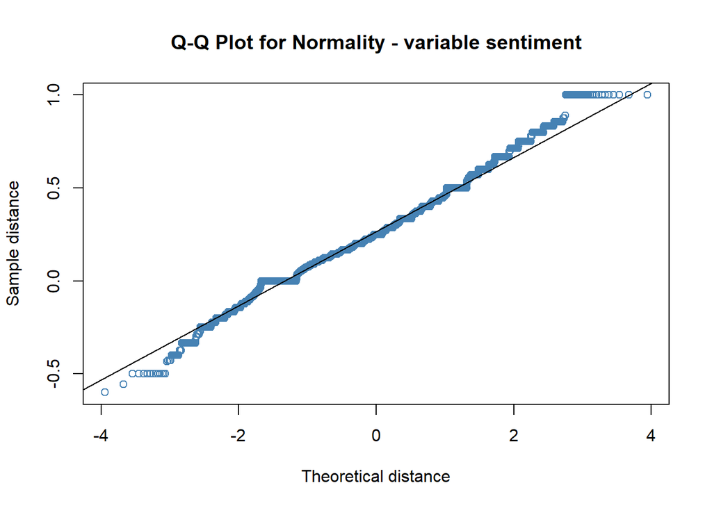

```r
#Add sentiment scores to data frame
data6 <- cbind.data.frame(data6, TotalSentiment$SentimentGI)
corrtest.df <- cbind.data.frame(data6$rating,data6$`TotalSentiment$SentimentGI`)
colnames(corrtest.df)<- c("rating", "sentiment")
CorrtestMatrix <- as.matrix(corrtest.df)

#Normality plot - 'sentiment' variable
qqnorm(corrtest.df$sentiment,main = 'Q-Q Plot for Normality - variable sentiment', xlab = 'Theoretical distance',
       ylab = 'Sample distance', col = 'steelblue')
qqline(corrtest.df$sentiment)
```

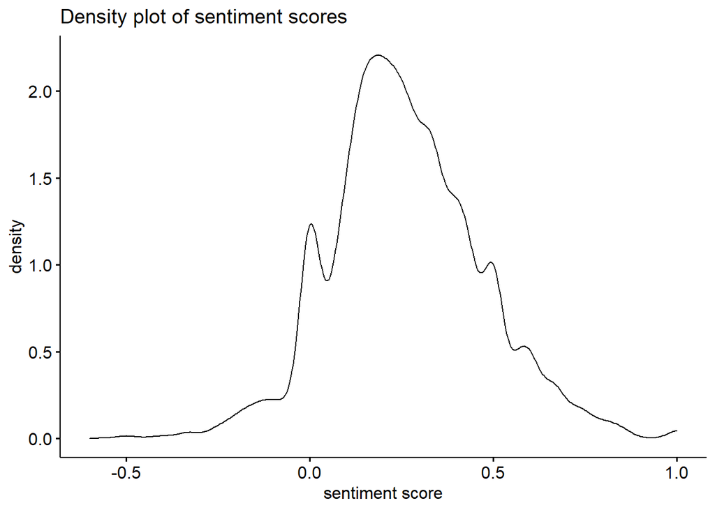

```r
ggdensity(corrtest.df$sentiment, main = "Density plot of sentiment scores",
          xlab = "sentiment score")
```

```r
# Check for normality using the Anderson-Darling Test - 'sentiment' variable
ad.test(rnorm(corrtest.df$sentiment))
```

```
##
##  Anderson-Darling normality test
##
## data:  rnorm(corrtest.df$sentiment)
## A = 0.60971, p-value = 0.113
```

```r
# Check for normality using the Anderson-Darling Test - 'rating' variable
ad.test(rnorm(corrtest.df$rating))
```

```
##
##  Anderson-Darling normality test
##
## data:  rnorm(corrtest.df$rating)
## A = 0.45128, p-value = 0.274
```

Correlation

1. sentiment vs rating - BEFORE PD

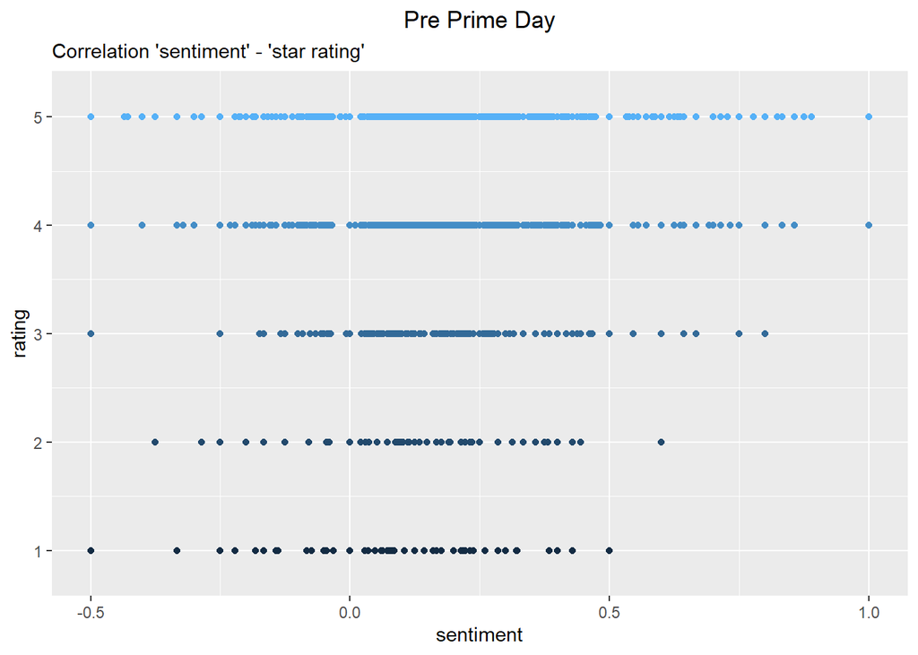

```r
# Scatter for all sentiment scores and all ratings
ggplot(pre12, aes(x = pre12$sentiment$SentimentGI, y = pre12$rating, color = pre12$rating)) +
    geom_point(position = position_dodge(width = 0.4))+ labs(x='sentiment', y="rating", title="Pre Prime Day", subtitle="Correlation 'sentiment' - 'star rating'") + theme(legend.position = "none")
```

```r
#Correlation test on 95% confidence interval
cor.test(pre12$sentiment$SentimentGI, pre12$rating, method = "kendall",conf.level = 0.95)
```

```
##
##  Kendall's rank correlation tau
##
## data:  pre12$sentiment$SentimentGI and pre12$rating
## z = 10.817, p-value < 2.2e-16
## alternative hypothesis: true tau is not equal to 0
## sample estimates:
##       tau
## 0.1103315
```

2. sentiment vs review length - BEFORE PD

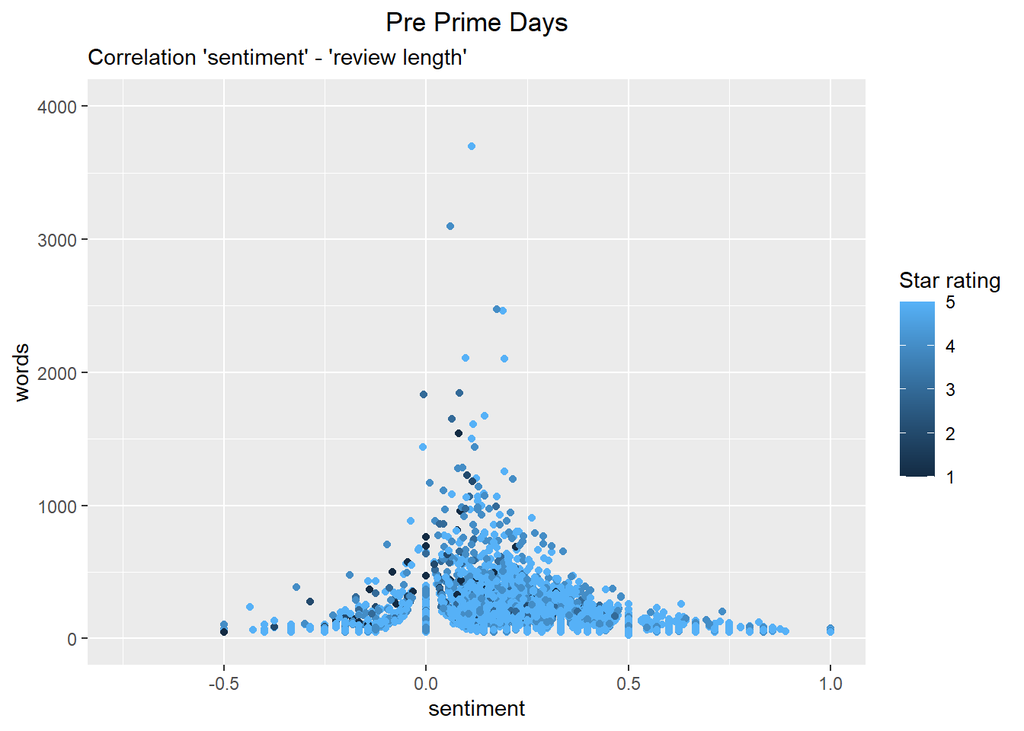

```r
pre12$length <- nchar(pre12$text)
# Correlation scatter plot
ggplot(pre12, aes(x = pre12$sentiment$SentimentGI, y = pre12$length , color = pre12$rating)) +
    geom_point(position = position_dodge(width = 0.4))+ ylim(0, 4000)+ xlim(-0.75, 1) + labs(x='sentiment', y="words",
            title="Pre Prime Days", subtitle="Correlation 'sentiment' - 'review length'")+ labs(color = "Star rating")
```

```r
#Correlation test on 95% confidence interval
cor.test(pre12$sentiment$SentimentGI, pre12$length, method = "kendall",conf.level = 0.95)
```

```
##
##  Kendall's rank correlation tau
##
## data:  pre12$sentiment$SentimentGI and pre12$length
## z = -28.091, p-value < 2.2e-16
## alternative hypothesis: true tau is not equal to 0
## sample estimates:
##       tau
## -0.240858
```

AFTER PD

Correlation

1. sentiment vs rating

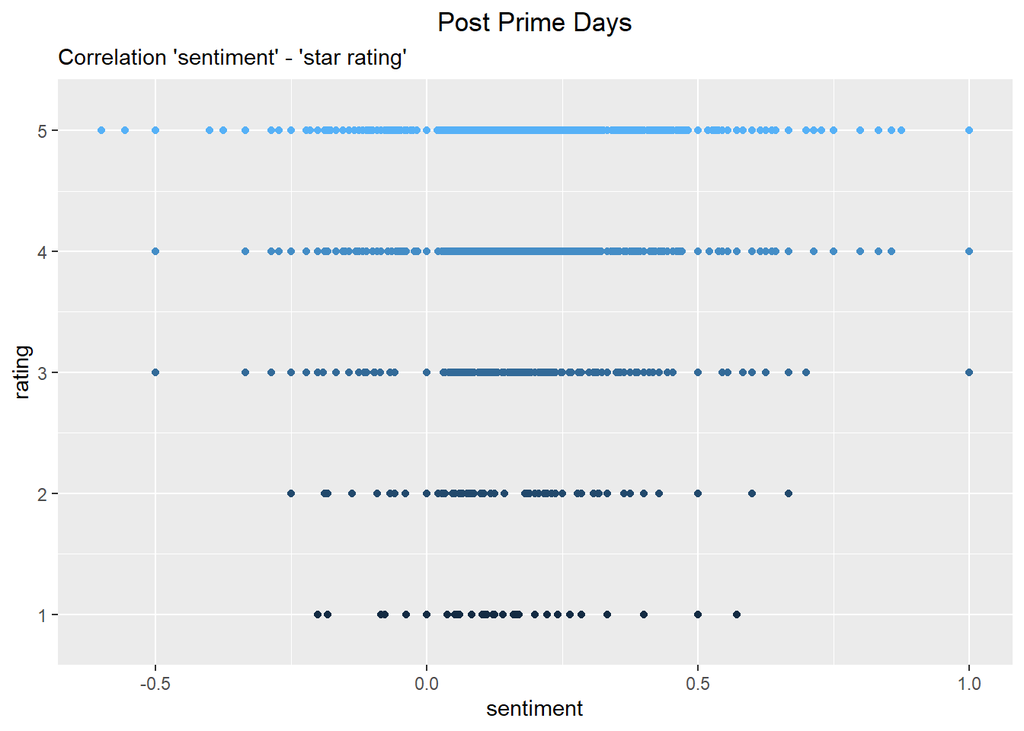

```r
# Scatter for all sentiment scores and all ratings
ggplot(aft12, aes(x = aft12$sentiment$SentimentGI, y = aft12$rating, color = aft12$rating)) +
    geom_point(position = position_dodge(width = 0.4))+ labs(x='sentiment', y="rating", title="Post Prime Days", subtitle="Correlation 'sentiment' - 'star rating'") + theme(legend.position = "none")
```

```r
#Correlation test on 95% confidence interval
cor.test(aft12$sentiment$SentimentGI, aft12$rating, method = "kendall",conf.level = 0.95)
```

```
##
##  Kendall's rank correlation tau
##
## data:  aft12$sentiment$SentimentGI and aft12$rating
## z = 8.1442, p-value = 3.817e-16
## alternative hypothesis: true tau is not equal to 0
## sample estimates:
##        tau
## 0.08320134
```

2. sentiment vs review length

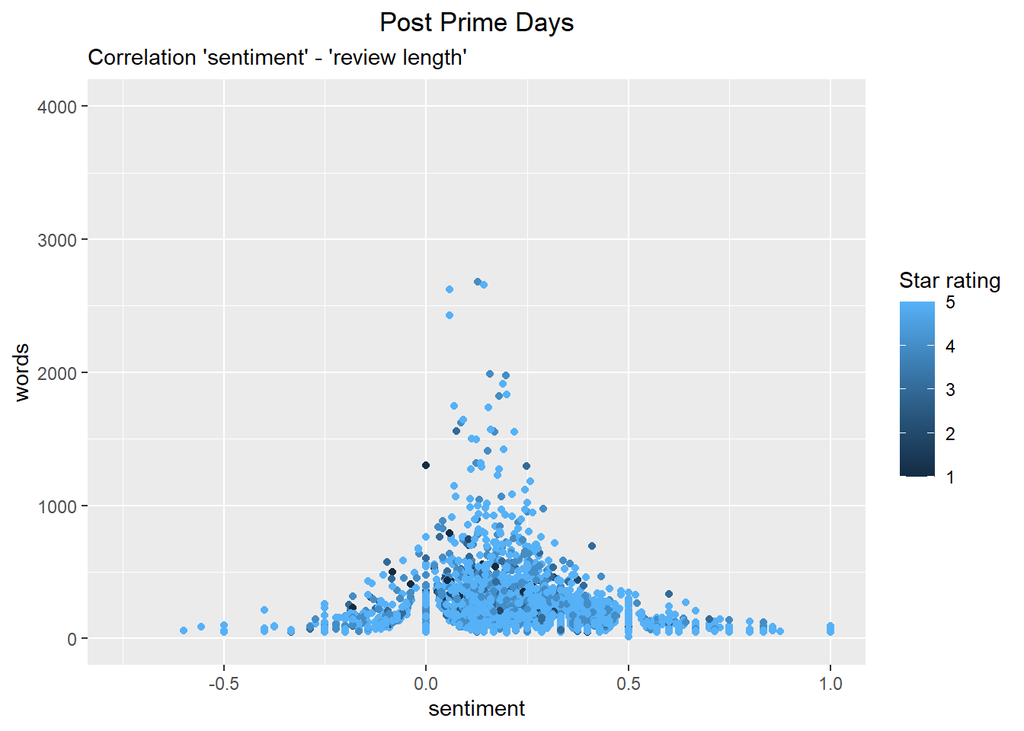

```r
aft12$length <- nchar(aft12$text)
# Correlation scatter plot
ggplot(aft12, aes(x = aft12$sentiment$SentimentGI, y = aft12$length , color = aft12$rating)) +
    geom_point(position = position_dodge(width = 0.4))+ ylim(0, 4000)+ xlim(-0.75, 1) + labs(x='sentiment', y="words",
            title="Post Prime Days", subtitle="Correlation 'sentiment' - 'review length'")+ labs(color = "Star rating")
```

```r
#Correlation test on 95% confidence interval
cor.test(aft12$sentiment$SentimentGI, aft12$length, method = "kendall",conf.level = 0.95)
```

```
##
##  Kendall's rank correlation tau
##
## data:  aft12$sentiment$SentimentGI and aft12$length
## z = -25.742, p-value < 2.2e-16
## alternative hypothesis: true tau is not equal to 0
## sample estimates:
##        tau
## -0.2205961
```

*Visualization*

Scores by periods *****************

```r
#create review count variables
pre8count<- nrow(pre8)
pre10count<- nrow(pre10)
pre12count<- nrow(pre12)
aft8count<- nrow(aft8)
aft10count<- nrow(aft10)
aft12count<- nrow(aft12)
#Create data frame from variables sentiment, rating,pos. reviews ratio and review count
sentiment <- c(meanSApre12, meanSApre8, meanSApre10, meanSAaft8, meanSAaft10, meanSAaft12)
rating <- c(meanratingpre12,meanratingpre8, meanratingpre10,  meanratingaft8, meanratingaft10, meanratingaft12)
pos.reviews <- c(pre12ReviewRatio,pre8ReviewRatio, pre10ReviewRatio,  aft8ReviewRatio, aft10ReviewRatio, aft12ReviewRatio)
review.count <- c(pre12count, pre10count, pre8count, aft8count, aft10count, aft12count)
name <- c('pre 12','pre 8', 'pre 10', 'aft 8', 'aft 10', 'aft 12')
PeriodsDF <- data.frame(sentiment, rating, pos.reviews, review.count, name)
```

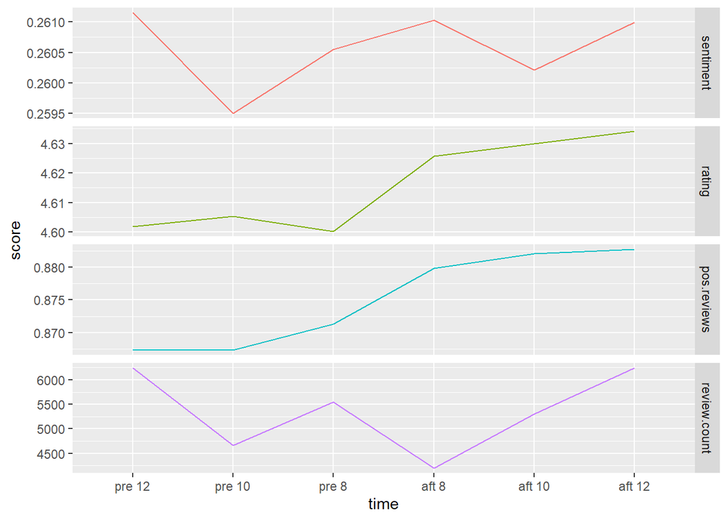

```r
# Plot line chart comparing sentiment, rating, pos. reviews ratio and review count per period
PeriodsMelt <- melt(subset(PeriodsDF, select=c(name,sentiment,rating, pos.reviews, review.count)), id.var="name")
PeriodsMelt$name <- factor(PeriodsMelt$name,
                   levels = c("pre 12", "pre 10", "pre 8", "aft 8", "aft 10", "aft 12"))
ggplot(PeriodsMelt, aes(x = name, y = value, group = 1)) + geom_line(aes(color = variable)) +
      facet_grid(variable ~ ., scales = "free_y") + theme(legend.position = "none") + xlab('time') + ylab('score')
```

Scores by product ***************** *BEFORE PD*

```r
#create review count variables Pre 12 weeks
Fire7precount<- nrow(Fire7pre)
FireHD8precount<- nrow(FireHD8pre)
FireHD10precount<- nrow(FireHD10pre)
FireKidsprecount<- nrow(FireKidspre)
FireTVprecount<- nrow(FireTVpre)
KindlePaperwhiteprecount<- nrow(KindlePaperwhitepre)
KindleVoyageprecount<- nrow(KindleVoyagepre)
KindleOasisprecount<- nrow(KindleOasispre)
Echoprecount<- nrow(Echopre)
Tapprecount <- nrow(Tappre)

#Create data frame from variables sentiment, rating,pos. reviews ratio and review count
preSentiment <-c(Fire7premeanSent,FireHD8premeanSent,FireHD10premeanSent,FireKidspremeanSent,FireTVpremeanSent,KindlePaperwhitepremeanSent,KindleVoyagepremeanSent,KindleOasispremeanSent,EchopremeanSent,TappremeanSent)
preRating <- c(Fire7premeanRating, FireHD8premeanRating, FireHD10premeanRating, FireKidspremeanRating,FireTVpremeanRating,  KindlePaperwhitepremeanRating, KindleVoyagepremeanRating, KindleOasispremeanRating, EchopremeanRating, TappremeanRating)
prePos.reviews <- c(Fire7preratio, FireHD8preratio, FireHD10preratio, FireKidspreratio,FireTVpreratio, KindlePaperwhitepreratio, KindleVoyagepreratio, KindleOasispreratio, Echopreratio, Tappreratio)
preReviewcount <- c(Fire7precount, FireHD8precount, FireHD10precount,FireKidsprecount,FireTVprecount, KindlePaperwhiteprecount, KindleVoyageprecount,KindleOasisprecount,Echoprecount,Tapprecount)
Name <- c('Fire 7', 'Fire HD 8', 'Fire HD 10', 'Fire Kids','Fire TV', 'Kindle PW', 'Kindle Voy.','Kindle Oas.', 'Echo', 'Tap')
preProductDF <- data.frame(preSentiment, preRating, prePos.reviews, Name, preReviewcount)
```

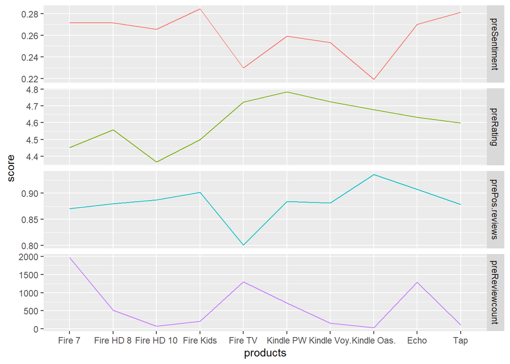

```r
# Plot line chart comparing sentiment, rating, pos. review ratio and review count per product
preProductsMelt <- melt(subset(preProductDF, select=c(Name,preSentiment,preRating, prePos.reviews, preReviewcount)), id.var="Name")
preProductsMelt$Name <- factor(preProductsMelt$Name,
                   levels = c('Fire 7', 'Fire HD 8', 'Fire HD 10', 'Fire Kids','Fire TV', 'Kindle PW', 'Kindle Voy.','Kindle Oas.', 'Echo', 'Tap'))
ggplot(preProductsMelt, aes(x = Name, y = value, group = 1)) + geom_line(aes(color = variable)) +
      facet_grid(variable ~ ., scales = "free_y") + theme(legend.position = "none") + xlab('products') + ylab('score')
```

*AFTER PD*

```r
#create review count variables aft 12 weeks
Fire7aftcount<- nrow(Fire7aft)
FireHD8aftcount<- nrow(FireHD8aft)
FireHD10aftcount<- nrow(FireHD10aft)
FireKidsaftcount<- nrow(FireKidsaft)
FireTVaftcount<- nrow(FireTVaft)
KindlePaperwhiteaftcount<- nrow(KindlePaperwhiteaft)
KindleVoyageaftcount<- nrow(KindleVoyageaft)
KindleOasisaftcount<- nrow(KindleOasisaft)
Echoaftcount<- nrow(Echoaft)
Tapaftcount <- nrow(Tapaft)

#Create data frame from variables sentiment, rating,pos. reviews ratio and review count
aftSentiment <-c(Fire7aftmeanSent,FireHD8aftmeanSent,FireHD10aftmeanSent,FireKidsaftmeanSent,FireTVaftmeanSent,KindlePaperwhiteaftmeanSent,KindleVoyageaftmeanSent,KindleOasisaftmeanSent,EchoaftmeanSent,TapaftmeanSent)
aftRating <- c(Fire7aftmeanRating, FireHD8aftmeanRating, FireHD10aftmeanRating, FireKidsaftmeanRating,FireTVaftmeanRating,  KindlePaperwhiteaftmeanRating, KindleVoyageaftmeanRating, KindleOasisaftmeanRating, EchoaftmeanRating, TapaftmeanRating)
aftPos.reviews <- c(Fire7aftratio, FireHD8aftratio, FireHD10aftratio, FireKidsaftratio,FireTVaftratio, KindlePaperwhiteaftratio, KindleVoyageaftratio, KindleOasisaftratio, Echoaftratio, Tapaftratio)
aftReviewcount <- c(Fire7aftcount, FireHD8aftcount, FireHD10aftcount,FireKidsaftcount,FireTVaftcount, KindlePaperwhiteaftcount, KindleVoyageaftcount,KindleOasisaftcount,Echoaftcount,Tapaftcount)
Name <- c('Fire 7', 'Fire HD 8', 'Fire HD 10', 'Fire Kids','Fire TV', 'Kindle PW', 'Kindle Voy.','Kindle Oas.', 'Echo', 'Tap')
aftProductDF <- data.frame(aftSentiment, aftRating, aftPos.reviews, Name, aftReviewcount)
```

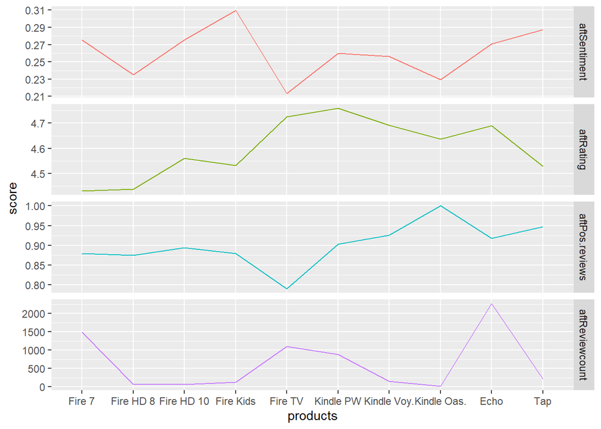

```r
# Plot line chart comparing sentiment, rating, pos. review ratio and review count per product
aftProductsMelt <- melt(subset(aftProductDF, select=c(Name,aftSentiment,aftRating, aftPos.reviews, aftReviewcount)), id.var="Name")
aftProductsMelt$Name <- factor(aftProductsMelt$Name,
                   levels = c('Fire 7', 'Fire HD 8', 'Fire HD 10', 'Fire Kids','Fire TV', 'Kindle PW', 'Kindle Voy.','Kindle Oas.', 'Echo', 'Tap'))
ggplot(aftProductsMelt, aes(x = Name, y = value, group = 1)) + geom_line(aes(color = variable)) +
      facet_grid(variable ~ ., scales = "free_y") + theme(legend.position = "none") + xlab('products') + ylab('score')
```

*Word usage by different periods*

Word occurences

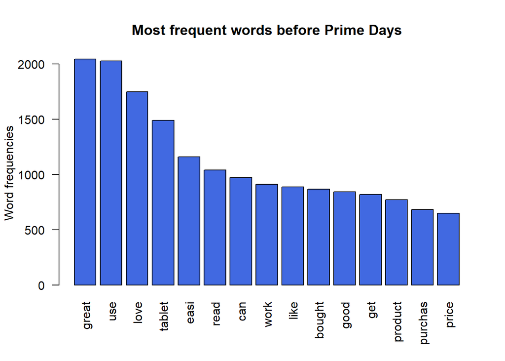

```r
# Bar plot for 15 most used words in 12 weeks before Prime Day's 2015-2017
barplot(pre12df[1:15,]$freq, las = 2, names.arg = pre12df[1:15,]$word,
        col ="royalblue", main ="Most frequent words before Prime Days",
        ylab = "Word frequencies")
```

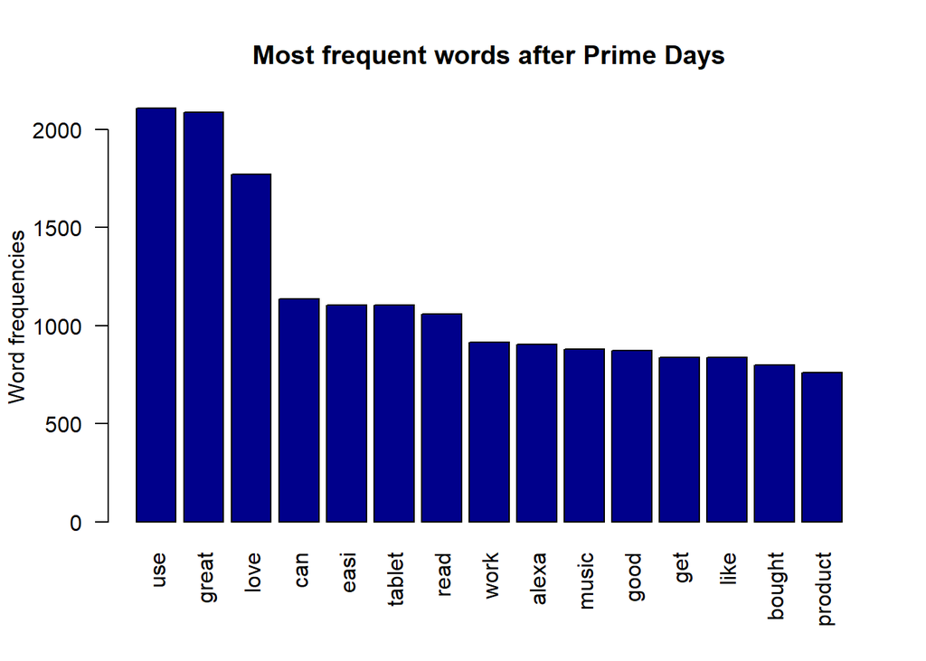

```r
# Bar plot for 15 most used words in 12 weeks before Prime Day's 2015-2017
barplot(aft12df[1:15,]$freq, las = 2, names.arg = aft12df[1:15,]$word,
        col ="darkblue", main ="Most frequent words after Prime Days",
        ylab = "Word frequencies")
```

Word clouds

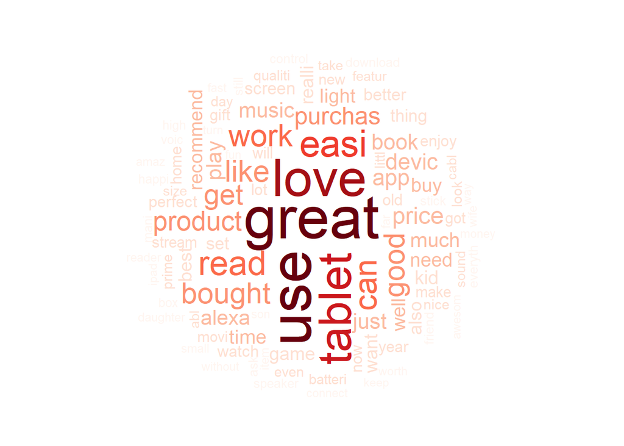

```r
# 100 most used words in 12 weeks before Prime Day's 2015-2017
set.seed(1234)
wordcloud(words = pre12df$word, freq = pre12df$freq, min.freq = 1,
          max.words=100, random.order=FALSE, rot.per=0.35,
          colors=brewer.pal(10, "Reds"))
```

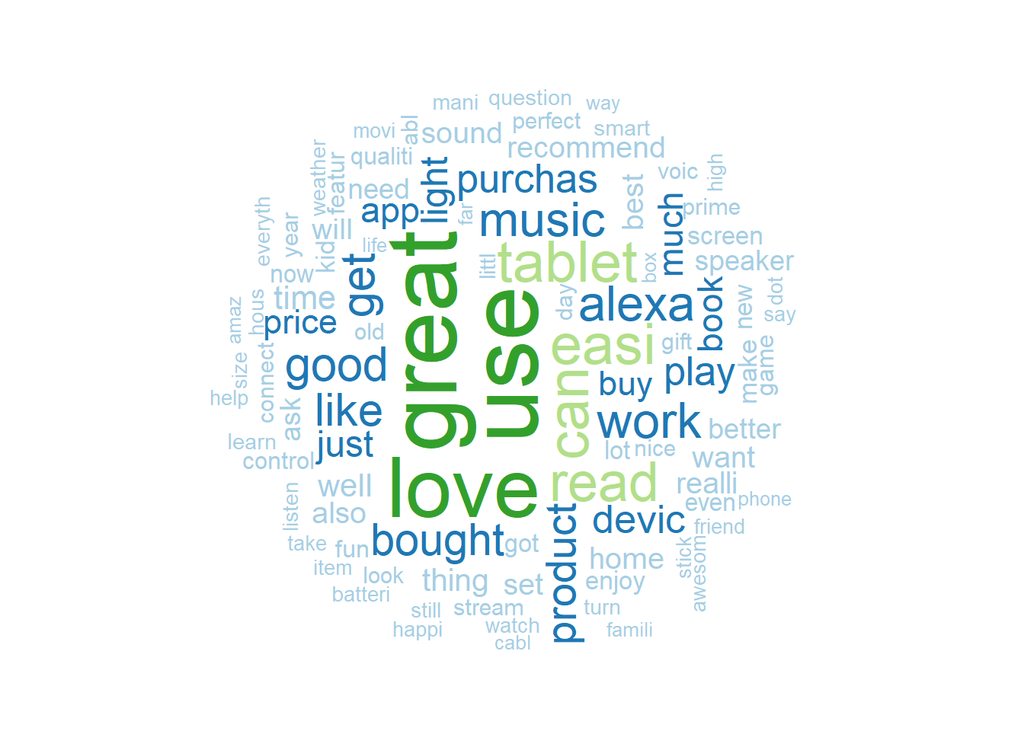

```r
# 100 most used words in 12 weeks after Prime Day's 2015-2017
set.seed(1234)
wordcloud(words = aft12df$word, freq = aft12df$freq, min.freq = 1,
          max.words=100, random.order=FALSE, rot.per=0.35,
          colors=brewer.pal(4, "Paired"))
```

```r
# 100 most used words in 12 weeks before Prime Day's 2015-2017
head(pre12df, 100)
```

```
##                word freq
## great         great 2046
## use             use 2028
## love           love 1751
## tablet       tablet 1492
## easi           easi 1161
## read           read 1042
## can             can  972
## work           work  910
## like           like  887
## bought       bought  867
## good           good  843
## get             get  818
## product     product  772
## purchas     purchas  683
## price         price  649
## app             app  611
## devic         devic  592
## book           book  570
## just           just  560
## play           play  549
## music         music  540
## alexa         alexa  521
## much           much  509
## time           time  480
## need           need  479
## well           well  475
## buy             buy  468
## light         light  467
## recommend recommend  457
## kid             kid  454
## best           best  442
## want           want  436
## realli       realli  433
## game           game  425
## also           also  421
## set             set  403
## screen       screen  392
## thing         thing  389
## better       better  359
```

[output cut: 46 more lines]

```
## daughter   daughter  186
## without     without  180
## awesom       awesom  180
## worth         worth  179
## fast           fast  179
## far             far  178
## reader       reader  176
## small         small  175
## money         money  175
## item           item  175
## way             way  174
## amaz           amaz  174
## wife           wife  174
## ipad           ipad  173
## keep           keep  172
```

```r
# 100 most used words in 12 weeks after Prime Day's 2015-2017
head(aft12df, 100)
```

```
##                word freq
## use             use 2109
## great         great 2088
## love           love 1771
## can             can 1138
## easi           easi 1106
## tablet       tablet 1105
## read           read 1060
## work           work  916
## alexa         alexa  904
## music         music  879
## good           good  872
## get             get  838
## like           like  837
## bought       bought  800
## product     product  761
## play           play  697
## purchas     purchas  692
## devic         devic  679
## light         light  625
## just           just  606
## book           book  569
## app             app  568
## much           much  568
## buy             buy  550
## price         price  545
## time           time  505
## well           well  495
## thing         thing  464
## home           home  460
## set             set  459
## realli       realli  455
## want           want  447
## best           best  440
## recommend recommend  440
## sound         sound  436
## also           also  429
## need           need  420
## will           will  418
## better       better  411
```

[output cut: 46 more lines]

```
## high           high  208
## awesom       awesom  207
## movi           movi  205
## item           item  204
## help           help  202
## happi         happi  201
## dot             dot  201
## way             way  195
## cabl           cabl  194
## box             box  192
## amaz           amaz  190
## famili       famili  188
## far             far  187
## phone         phone  186
## life           life  182
```

Word associations:

All 12 weeks prior to PD

```r
# Find words that mostly correlate with popular and particular terms associated with PrimeDay
findAssocs(pre12dtm, c("prime", "alexa", "price", "offer", "cheap", "sale", "purchas", "bought", "app", "great", "use", "love", "like", "well","easi", "need", "want", "dislike", "hate" ), c(0.2, 0.15, 0.1, 0.15, 0.15, 0.15, 0.1, 0.1, 0.1, 0.1, 0.2, 0.1, 0.1, 0.15, 0.1, 0.15, 0.1, 0.1, 0.2))
```

```
## $prime
##       member   membership       clumsi echoprosamaz    establish       leader
##         0.38         0.27         0.27         0.27         0.27         0.27
##     manchest     nonaudio          pga     preexist       ueboom        music
##         0.27         0.27         0.27         0.27         0.27         0.26
##     playlist         free      airplay          atv         feud        video
##         0.23         0.21         0.21         0.21         0.21         0.20
##
## $alexa
##      music   question       tell        ask       list    weather       play
##       0.31       0.28       0.27       0.27       0.23       0.23       0.21
##       joke   playlist     answer      timer       home      alien kardashian
##       0.20       0.20       0.19       0.19       0.18       0.18       0.18
##      khloe       kink     massiv        say       shop       walk understand
##       0.18       0.18       0.18       0.17       0.17       0.17       0.17
##    command       turn    speaker       talk      radio       voic thermostat
##       0.17       0.16       0.16       0.16       0.16       0.16       0.16
##        fun       song    kitchen
##       0.15       0.15       0.15
##
## $price
##       tablet         beat        ratio         good          tag          low
##         0.23         0.19         0.15         0.13         0.13         0.12
##       higher         rang        worth       reason        point        beefi
##         0.12         0.12         0.11         0.11         0.11         0.11
## narrowoveral  proprietori      certain
##         0.11         0.11         0.10
##
## $offer
## capabilitiesplayst            firebox            channel                sec
##               0.33               0.29               0.27               0.23
##                nfl           displeas             intrus           quadrupl
##               0.23               0.22               0.22               0.22
##            webalso               fave             freeli               goug
##               0.22               0.22               0.22               0.22
##        installfast           schooler              starz          watchlist
##               0.22               0.22               0.22               0.22
##              guest            donâ\200\231t              itâ\200\231      donï¿½ï¿½ï¿½t
##               0.22               0.22               0.22               0.22
##        itï¿½ï¿½ï¿½              trial             custom                dvr
```

[output cut: 146 more lines]

```
##        0.58        0.58        0.58        0.58        0.58        0.58
## wellingrain       ignor     shorter        drag       idiot   worthwhil
##        0.58        0.47        0.41        0.41        0.41        0.33
##    starbuck    elsewher     subject     intrigu         mac       trial
##        0.33        0.33        0.33        0.33        0.33        0.31
## fingerprint       began     classic        forc        join      musicp
##        0.29        0.29        0.29        0.29        0.29        0.29
##     tabletr      hahaha   standalon        tile    advertis       figur
##        0.29        0.29        0.29        0.29        0.28        0.27
##    antiglar      mistak       habit         pbs        onto        curv
##        0.26        0.26        0.26        0.26        0.23        0.23
##         gig      public     essenti        mayb        ipod     librari
##        0.23        0.23        0.23        0.22        0.22        0.21
##        felt     explain   accessori   discoveri   unimpress
##        0.20        0.20        0.20        0.20        0.20
```

All 12 weeks after PD

```r
# Find words that mostly correlate with popular and particular terms associated with PrimeDay
findAssocs(aft12dtm, c("prime", "alexa", "price", "offer", "cheap", "sale", "purchas", "bought", "app", "great", "use", "love", "like", "well", "easi", "need", "want", "dislike", "hate"), c(0.2, 0.15, 0.1, 0.15, 0.15, 0.15, 0.1, 0.1, 0.3, 0.1, 0.2, 0.1, 0.15, 0.15, 0.1, 0.15, 0.2, 0.1, 0.1))
```

```
## $prime
##     member    bellini        bet      hbogo   reappear       acct      video
##       0.38       0.26       0.26       0.26       0.26       0.25       0.24
## membership     offlin
##       0.24       0.21
##
## $alexa
##        ask      music       play     collin       joan     knight      lever
##       0.34       0.29       0.24       0.24       0.24       0.24       0.24
##       mall      morri        mtv     virgin        say     answer        can
##       0.24       0.24       0.24       0.24       0.23       0.23       0.22
##   question    speaker       hmmm       know       tell    weather     driven
##       0.22       0.20       0.20       0.19       0.19       0.19       0.19
##      queen      phone understand      sound    portabl       song       list
##       0.18       0.17       0.17       0.16       0.16       0.16       0.16
##       shop   cellular       duli    nonport       time  bluetooth
##       0.16       0.16       0.16       0.16       0.15       0.15
##
## $price
##  tablet    rang    good android    half    beat   point     tag    valu  reason
##    0.21    0.14    0.13    0.13    0.12    0.11    0.11    0.11    0.10    0.10
##
## $offer
##         fed        film installfast       starz   watchlist         rum
##        0.22        0.22        0.22        0.22        0.22        0.22
##  correctnev   rightkept     lowerti     midtier         win      servic
##        0.22        0.22        0.22        0.22        0.18        0.17
##        test     greater      freeli     forcast        goug
##        0.15        0.15        0.15        0.15        0.15
##
## $cheap
##      destroy       speedi         bike        metro   qualitysid        rider
##         0.21         0.15         0.15         0.15         0.15         0.15
##      builder         dude        funki         jean       poetri chargercharg
##         0.15         0.15         0.15         0.15         0.15         0.15
##   reviewsget   unfamiliar       wealth      factori       garbag      kidscon
##         0.15         0.15         0.15         0.15         0.15         0.15
##     regualur        crush         kiss       nowher    lowrequir         camn
##         0.15         0.15         0.15         0.15         0.15         0.15
##          fir         mono          bug         fold      airplay     reconsid
```

[output cut: 73 more lines]

```
## $hate
##    checkparent         despis includedtablet        iwhatev        kidzbop
##           0.35           0.35           0.35           0.35           0.35
##           lone            meh        selfish         sensat           boat
##           0.35           0.35           0.35           0.35           0.35
##          graph           down          insur         inanim         object
##           0.35           0.35           0.35           0.35           0.35
##           dang         hollow       kidproof        coverag            yrs
##           0.25           0.25           0.25           0.25           0.20
##        financi           rout         center           caus       customiz
##           0.20           0.18           0.18           0.16           0.16
##           safe           mute        histori         public          throw
##           0.16           0.14           0.13           0.12           0.12
##         pocket        earlier          exist        convers           sold
##           0.11           0.11           0.11           0.11           0.10
```

Review lengths before and after PDs

```r
PreLength<-nchar(pre12$text)
describe(PreLength)
```

```
## PreLength
##        n  missing distinct     Info     Mean      Gmd      .05      .10
##     6246        0      593        1    159.4    131.3       52       56
##      .25      .50      .75      .90      .95
##       71      107      185      311      430
##
## lowest :   24   48   50   51   52, highest: 2107 2460 2476 3097 3697
```

```r
AftLength<-nchar(aft12$text)
describe(AftLength)
```

```
## AftLength
##        n  missing distinct     Info     Mean      Gmd      .05      .10
##     6241        0      620        1    167.6    138.9       53       57
##      .25      .50      .75      .90      .95
##       73      114      194      323      443
##
## lowest :   16   44   48   49   50, highest: 1989 2429 2625 2657 2678
```